# ggplot2 学术绘图案例

## 8.2 三元图

### 8.2.1 三元点图

定义了三个函数，分别为三元转二元、二元转三元、三元图坐标轴，画完坐标轴，额外添加绘图数据即可

注意，三元点，值的和必须为1

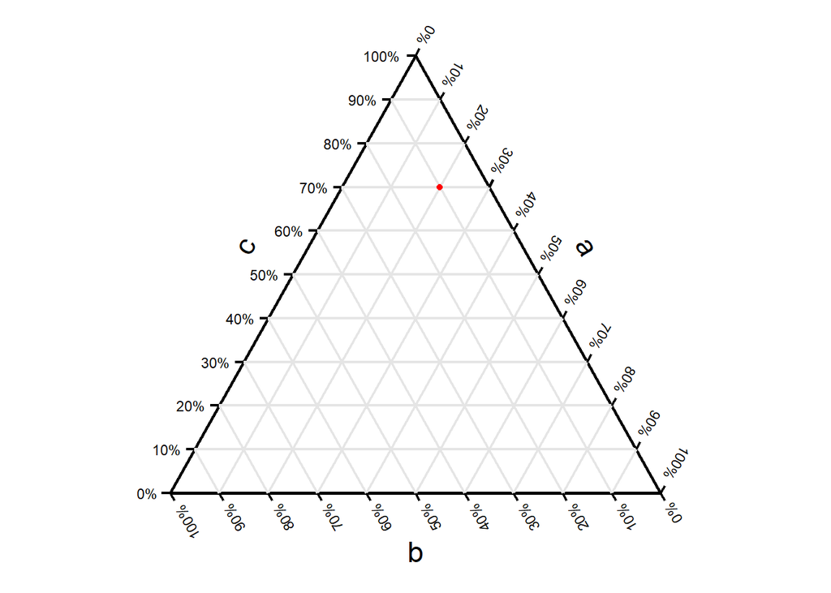

```r
# 加载包
library(data.table)
library(ggplot2)
library(magrittr)

# 定义函数
ratio2xy <- function(w1, w2, w3, ...){
  # 将三维坐标w1w2w3转化为迪卡尔xy，支持向量格式，原理为两直线相交
  # 自12点方向顺时针为s1、s2、s3，同时每个轴顺时针方向为贡献率0至100
  # 不考虑外部，只考虑内部，（内部外部无所谓？）

  # 判断，输入的三维数据，对应和必须为1
  if(length(w1) != length(w2) | length(w2) != length(w3) | length(w3) != length(w1)){
    stop("Error: length of parameters must be equal!")
  } else if(length(w1) == 1){
    if(round(sum(w1, w2, w3), 13) != 1) stop("Erro: sum of ratio must be 1!")
  } else{
    allsum <- matrix(c(w1,w2,w3), ncol=3, byrow = F) %>% apply(1,sum) %>% round(13)
    if(any(allsum != 1)) stop("Erro: sum of ratio must be 1!")
  }

  y <- s3[2]+w3*(s1[2]-s3[2])  #可根据z3贡献直接推断出y值
  a <- s1[1]+w1*(s2[1]-s1[1])  #可根据z1推断出一个f(x)经过的点(a,b)
  b <- s1[2]-w1*(s1[2]-s2[2])  #可根据z1推断出一个f(x)经过的点(a,b)
  x <- (s3[1]-s1[1])/(s3[2]-s1[2])*(y-b)+a  #(x-a)/(y-b)=(x3-x1)/(y3-y1)
  res <- list(x = x, y = y)
  return(res)
}
xy2ratio <- function(x, y, ...){
  # 将迪卡尔xy转化为三维坐标w1w2w3，支持向量格式，原理为纵坐标差值、坐标轴旋转
  # 自12点方向顺时针为s1、s2、s3，同时每个轴顺时针方向为贡献率0至100
  # 不考虑外部，只考虑内部
  xycw60 <- function(x, y, ...){
    # 坐标轴顺时针旋转60度，所有点逆时针旋转60度
    x2 <- x*cos(-pi/3)+y*sin(-pi/3)
    y2 <- -x*sin(-pi/3)+y*cos(-pi/3)
    return(list(x=x2,y=y2))
  }
  # 直接利用纵坐标差值求w3，
  w3 <- (y-s3[2])/(s1[2]-s3[2])
  # 旋转坐标轴，再利用纵坐标差值求w2，好处是直接判定正负（点到直线距离无法判断正负号）
  s1p <- c(xycw60(s1[1], s1[2])$x, xycw60(s1[1], s1[2])$y)
  s2p <- c(xycw60(s2[1], s2[2])$x, xycw60(s2[1], s2[2])$y)
  s3p <- c(xycw60(s3[1], s3[2])$x, xycw60(s3[1], s3[2])$y)
  xp <- xycw60(x,y)$x
  yp <- xycw60(x,y)$y
  w2 <- (s2p[2]-yp)/(s2p[2]-s3p[2])
  # 根据和为1求w1
  w1 <- 1-w3-w2
  return(list(w1=w1, w2=w2, w3=w3))
}
triAxis <- function(tri = 1, axis.title = c("a", "b", "c")){
  # point，点，dataframe格式，如果有3列，则为贡献坐标，如果有2列，则为xy坐标
  t.axi <- axis.title

  # 绘制三轴图
  # 设定属性
  r.cir <- tri         #外接圆半径
  d.dri <- 0.2*r.cir  #垂线方向漂移量（用于标记、轴刻度）
  d.axi <- 0.1         #轴刻度密度
  l.axi <- 0.03        #轴刻度线长度
  cos30 <- sqrt(3)/2   #cos(30deg)
  sin30 <- 1/2         #sin(30deg)
  s1 <- c(0,r.cir)                  #顶点1
  s2 <- c(cos30*r.cir,  -0.5*r.cir) #顶点2
  s3 <- c(-cos30*r.cir, -0.5*r.cir) #顶点3
  t.font <- "sans"      #文字字体

  ### common part
  # three axis
  triaxis <- data.table(x0 = c(s1[1], s2[1], s3[1]),
                        x1 = c(s2[1], s3[1], s1[1]),
                        y0 = c(s1[2], s2[2], s3[2]),
                        y1 = c(s2[2], s3[2], s1[2]))
  # midpoint of axis
  m.s1s2 <- c((s1[1]+s2[1])/2, (s1[2]+s2[2])/2)
  m.s2s3 <- c((s2[1]+s3[1])/2, (s2[2]+s3[2])/2)
  m.s3s1 <- c((s3[1]+s1[1])/2, (s3[2]+s1[2])/2)
  # axis title
  a.title <- data.table(x = c(m.s1s2[1]+cos30*d.dri, m.s2s3[1]+0,     m.s3s1[1]-cos30*d.dri),
                        y = c(m.s1s2[2]+sin30*d.dri, m.s2s3[2]-d.dri, m.s3s1[2]+sin30*d.dri),
                        l = t.axi,
                        a = c(300, 0, 60))
  # grid
  a.grid.s1 <- data.table(x0 = seq(s1[1], s2[1], length = 1/d.axi+1),
                          y0 = seq(s1[2], s2[2], length = 1/d.axi+1),
                          x1 = seq(s3[1], s2[1], length = 1/d.axi+1),
                          y1 = seq(s3[2], s2[2], length = 1/d.axi+1))
  a.grid.s1.n <- nrow(a.grid.s1)
  a.grid.s2 <- data.table(x0 = seq(s2[1], s3[1], length = 1/d.axi+1),
                          y0 = seq(s2[2], s3[2], length = 1/d.axi+1),
                          x1 = seq(s1[1], s3[1], length = 1/d.axi+1),
                          y1 = seq(s1[2], s3[2], length = 1/d.axi+1))
  a.grid.s2.n <- nrow(a.grid.s2)
  a.grid.s3 <- data.table(x0 = seq(s3[1], s1[1], length = 1/d.axi+1),
                          y0 = seq(s3[2], s1[2], length = 1/d.axi+1),
                          x1 = seq(s2[1], s1[1], length = 1/d.axi+1),
                          y1 = seq(s2[2], s1[2], length = 1/d.axi+1))
  a.grid.s3.n <- nrow(a.grid.s3)
  a.grid <- rbind(a.grid.s1[2:(a.grid.s1.n-1),],
                  a.grid.s2[2:(a.grid.s2.n-1),],
                  a.grid.s3[2:(a.grid.s3.n-1),])
  # tick
  a.tick.line.s1s2 <- data.table(x0 = seq(s1[1], s2[1], length = 1/d.axi+1),
                                 y0 = seq(s1[2], s2[2], length = 1/d.axi+1),
                                 x1 = seq(s1[1], s2[1], length = 1/d.axi+1)+sin30*l.axi,
                                 y1 = seq(s1[2], s2[2], length = 1/d.axi+1)+cos30*l.axi)
  a.tick.line.s2s3 <- data.table(x0 = seq(s2[1], s3[1], length = 1/d.axi+1),
                                 y0 = seq(s2[2], s3[2], length = 1/d.axi+1),
                                 x1 = seq(s2[1], s3[1], length = 1/d.axi+1)+sin30*l.axi,
                                 y1 = seq(s2[2], s3[2], length = 1/d.axi+1)-cos30*l.axi)
  a.tick.line.s3s1 <- data.table(x0 = seq(s3[1], s1[1], length = 1/d.axi+1),
                                 y0 = seq(s3[2], s1[2], length = 1/d.axi+1),
                                 x1 = seq(s3[1], s1[1], length = 1/d.axi+1)-l.axi,
                                 y1 = seq(s3[2], s1[2], length = 1/d.axi+1)+0)
  a.tick.line <- rbind(a.tick.line.s1s2, a.tick.line.s2s3, a.tick.line.s3s1)
  # axis text
  a.tick.text.s1s2 <- data.table(x = seq(s1[1], s2[1], length = 1/d.axi+1)+sin30*l.axi,
                                 y = seq(s1[2], s2[2], length = 1/d.axi+1)+cos30*l.axi,
                                 l = paste0(seq(0,100,length =1/d.axi+1), "%"),
                                 a = 240)
  a.tick.text.s2s3 <- data.table(x = seq(s2[1], s3[1], length = 1/d.axi+1)+sin30*l.axi,
                                 y = seq(s2[2], s3[2], length = 1/d.axi+1)-cos30*l.axi,
                                 l = paste0(seq(0,100,length =1/d.axi+1), "%"),
                                 a = 120)
  a.tick.text.s3s1 <- data.table(x = seq(s3[1], s1[1], length = 1/d.axi+1)-l.axi,
                                 y = seq(s3[2], s1[2], length = 1/d.axi+1)+0,
                                 l = paste0(seq(0,100,length =1/d.axi+1), "%"),
                                 a = 0)
  a.tick.text <- rbind(a.tick.text.s1s2, a.tick.text.s2s3, a.tick.text.s3s1)

  ### plot
  pic <- ggplot()+
    geom_segment(data = triaxis, aes(x = x0, y = y0, xend = x1, yend = y1), linewidth = 1)+ #坐标轴
    geom_segment(data = a.grid, aes(x = x0, y = y0, xend = x1, yend = y1), color = "gray90", linewidth = 0.8)+  #网格线
    geom_segment(data = a.tick.line, aes(x = x0, y = y0, xend = x1, yend = y1), linewidth = 0.8)+ #坐标轴刻度
    geom_text(data = a.title, aes(x, y, label = l, angle = a), size = 6, family = t.font)+  #坐标轴标题
    geom_text(data = a.tick.text, aes(x, y, label = l, angle = a), size = 3, hjust = 1.2, family = t.font)+ #坐标轴刻度数字
    scale_x_continuous(limits = c(-cos30*r.cir*1.1, cos30*r.cir*1.1))+
    scale_y_continuous(limits = c(-sin30*r.cir*1.5, r.cir*1.1))+
    coord_fixed()+
    theme_void()+
    labs(title = NULL, fill = "")+
    theme(aspect.ratio = 1,
          text = element_text(family = t.font))
  return(pic)
}

# 设定属性
tri <- 1
r.cir <- tri         #外接圆半径
d.dri <- 0.45*r.cir  #垂线方向漂移量（用于标记、轴刻度）
d.axi <- 0.1         #轴刻度密度
l.axi <- 0.03        #轴刻度线长度
cos30 <- sqrt(3)/2   #cos(30deg)
sin30 <- 1/2         #sin(30deg)
s1 <- c(0,r.cir)                  #顶点1
s2 <- c(cos30*r.cir,  -0.5*r.cir) #顶点2
s3 <- c(-cos30*r.cir, -0.5*r.cir) #顶点3

# 定义一个三维点，并转化为二维
point_3d <- c(0.2, 0.1, 0.7)        #注意三个数相加必须等于1
point_2d <- ratio2xy(point_3d[1], point_3d[2], point_3d[3])

# 定义点，并转化为二维
# xa <- seq(0, 100, 5)/100
# xb <- (1-xa)*3/4
# xc <- (1-xa)*1/4

# 定义一个带有间隔的全分布点
xa <- c()
xb <- c()
xc <- c()
th <- 0.1          #间隔
for(i in seq(0, 1, th)){
  re <- 1-i
  for(j in seq(0, re, th)){
    xa <- c(xa, i)
    xb <- c(xb, j)
    xc <- c(xc, 1-i-j)
  }
}

# 画图
triAxis()+
  geom_point(data=NULL, aes(x=point_2d$x, y=point_2d$y), color="red")
```

### 8.2.2 三元填充图及划分

这个图是从scus代码中提取出来的，但是，填充一个更广的范围，以查看不同区域上，三个维度的含义（在[0,1]区间的左侧、内部、还是右侧）

注意：将[0,1]闭区间划分为L、M、R个区域，则三个维度时，理论上有3^3=27种划分，但三维图的额外限制是维度和为1，此时，只剩16种有效划分，下面这些不存在：

- L.L.L、L.L.M、L.M.L
- M.L.L、M.M.R、M.R.M、M.R.R
- R.M.M、R.M.R、R.R.M、R.R.R

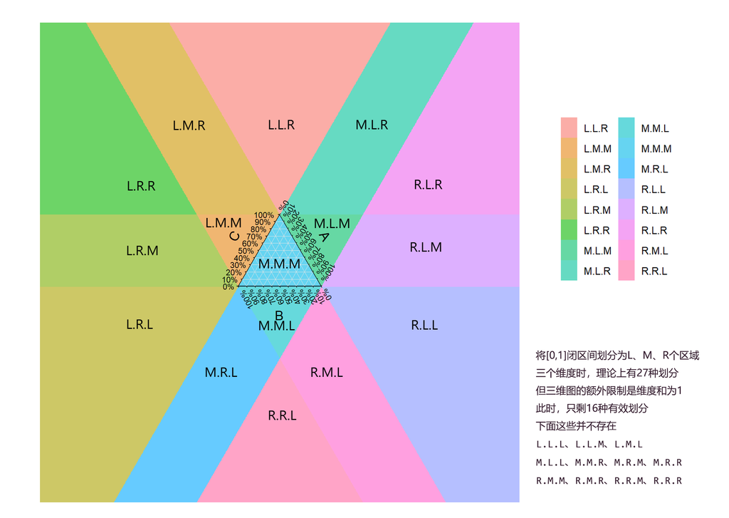

```r
# 这里只放代码，不画图
# packages
library(magrittr)
library(ggplot2)
library(data.table)

# function preparation
xy2ratio <- function(x, y, ...){
  # Convert Decarr coordinate (xy) to contribution rate (w1w2w3), supporting vector format.
  # The principle is the difference of ordinates and the rotation of coordinate axes
  xycw60 <- function(x, y, ...){
    x2 <- x*cos(-pi/3)+y*sin(-pi/3)
    y2 <- -x*sin(-pi/3)+y*cos(-pi/3)
    return(list(x=x2,y=y2))
  }
  w3 <- (y-s3[2])/(s1[2]-s3[2])
  s1p <- c(xycw60(s1[1], s1[2])$x, xycw60(s1[1], s1[2])$y)
  s2p <- c(xycw60(s2[1], s2[2])$x, xycw60(s2[1], s2[2])$y)
  s3p <- c(xycw60(s3[1], s3[2])$x, xycw60(s3[1], s3[2])$y)
  xp <- xycw60(x,y)$x
  yp <- xycw60(x,y)$y
  w2 <- (s2p[2]-yp)/(s2p[2]-s3p[2])
  w1 <- 1-w3-w2
  return(list(w1=w1, w2=w2, w3=w3))
}
ratio2xy <- function(w1, w2, w3, ...){
  # Convert contribution rate (w1w2w3) to Decarr coordinate (xy), supporting vector format.
  # Principle is two lines intersect.
  # if(round(sum(z1, z2, z3), 13) != 1) stop("Wrong!")
  y <- s3[2]+w3*(s1[2]-s3[2])
  a <- s1[1]+w1*(s2[1]-s1[1])
  b <- s1[2]-w1*(s1[2]-s2[2])
  x <- (s3[1]-s1[1])/(s3[2]-s1[2])*(y-b)+a  #(x-a)/(y-b)=(x3-x1)/(y3-y1)
  res <- list(x = x, y = y)
  return(res)
}
location <- function(w1, w2, w3) {
  stopifnot(length(w1) == length(w2), length(w2) == length(w3))

  # 分类函数
  lab <- function(x) ifelse(x < 0, "L", ifelse(x <= 1, "M", "R"))

  f1 <- factor(lab(w1), levels = c("L","M","R"))
  f2 <- factor(lab(w2), levels = c("L","M","R"))
  f3 <- factor(lab(w3), levels = c("L","M","R"))

  # interaction 直接返回 "L.M.R" 这种
  combo <- interaction(f1, f2, f3, lex.order = TRUE)

  # 对应的编码（1–27）
  idx <- as.integer(combo)

  # 映射表
  # map <- data.frame(idx = seq_along(levels(combo)), combo = levels(combo))
  # list(combo = as.character(combo), idx = idx, map = map)
  return(as.factor(combo))
}
triAxis <- function(tri, point, area){
  # Draw a triaxial diagram
  # Set parameters
  r.cir <- tri         #circumradius
  d.dri <- 0.6*r.cir  #Vertical drift
  d.axi <- 0.1         #Axial scale density
  l.axi <- 0.03        #Axis scale line length
  t.axi <- point[[1]]  #Axis title
  cos30 <- sqrt(3)/2   #cos(30deg)
  sin30 <- 1/2         #sin(30deg)
  s1 <- c(0,r.cir)                  #Top point of the triangle
  s2 <- c(cos30*r.cir,  -0.5*r.cir) #Bottom-left point of the triangle
  s3 <- c(-cos30*r.cir, -0.5*r.cir) #Bottom-right point of the triangle

  ### common part
  # three axis
  triaxis <- data.table(x0 = c(s1[1], s2[1], s3[1]),
                        x1 = c(s2[1], s3[1], s1[1]),
                        y0 = c(s1[2], s2[2], s3[2]),
                        y1 = c(s2[2], s3[2], s1[2]))
  # midpoint of axis
  m.s1s2 <- c((s1[1]+s2[1])/2, (s1[2]+s2[2])/2)
  m.s2s3 <- c((s2[1]+s3[1])/2, (s2[2]+s3[2])/2)
  m.s3s1 <- c((s3[1]+s1[1])/2, (s3[2]+s1[2])/2)
  # axis title
  a.title <- data.table(x = c(m.s1s2[1]+cos30*d.dri, m.s2s3[1]+0,     m.s3s1[1]-cos30*d.dri),
                        y = c(m.s1s2[2]+sin30*d.dri, m.s2s3[2]-d.dri, m.s3s1[2]+sin30*d.dri),
                        l = t.axi,
                        a = c(300, 0, 60))
  # grid
  a.grid.s1 <- data.table(x0 = seq(s1[1], s2[1], length = 1/d.axi+1),
                          y0 = seq(s1[2], s2[2], length = 1/d.axi+1),
                          x1 = seq(s3[1], s2[1], length = 1/d.axi+1),
                          y1 = seq(s3[2], s2[2], length = 1/d.axi+1))
  a.grid.s1.n <- nrow(a.grid.s1)
  a.grid.s2 <- data.table(x0 = seq(s2[1], s3[1], length = 1/d.axi+1),
                          y0 = seq(s2[2], s3[2], length = 1/d.axi+1),
                          x1 = seq(s1[1], s3[1], length = 1/d.axi+1),
                          y1 = seq(s1[2], s3[2], length = 1/d.axi+1))
  a.grid.s2.n <- nrow(a.grid.s2)
  a.grid.s3 <- data.table(x0 = seq(s3[1], s1[1], length = 1/d.axi+1),
                          y0 = seq(s3[2], s1[2], length = 1/d.axi+1),
                          x1 = seq(s2[1], s1[1], length = 1/d.axi+1),
                          y1 = seq(s2[2], s1[2], length = 1/d.axi+1))
  a.grid.s3.n <- nrow(a.grid.s3)
  a.grid <- rbind(a.grid.s1[2:(a.grid.s1.n-1),],
                  a.grid.s2[2:(a.grid.s2.n-1),],
                  a.grid.s3[2:(a.grid.s3.n-1),])
  # tick
  a.tick.line.s1s2 <- data.table(x0 = seq(s1[1], s2[1], length = 1/d.axi+1),
                                 y0 = seq(s1[2], s2[2], length = 1/d.axi+1),
                                 x1 = seq(s1[1], s2[1], length = 1/d.axi+1)+sin30*l.axi,
                                 y1 = seq(s1[2], s2[2], length = 1/d.axi+1)+cos30*l.axi)
  a.tick.line.s2s3 <- data.table(x0 = seq(s2[1], s3[1], length = 1/d.axi+1),
                                 y0 = seq(s2[2], s3[2], length = 1/d.axi+1),
                                 x1 = seq(s2[1], s3[1], length = 1/d.axi+1)+sin30*l.axi,
                                 y1 = seq(s2[2], s3[2], length = 1/d.axi+1)-cos30*l.axi)
  a.tick.line.s3s1 <- data.table(x0 = seq(s3[1], s1[1], length = 1/d.axi+1),
                                 y0 = seq(s3[2], s1[2], length = 1/d.axi+1),
                                 x1 = seq(s3[1], s1[1], length = 1/d.axi+1)-l.axi,
                                 y1 = seq(s3[2], s1[2], length = 1/d.axi+1)+0)
  a.tick.line <- rbind(a.tick.line.s1s2, a.tick.line.s2s3, a.tick.line.s3s1)
  # axis text
  a.tick.text.s1s2 <- data.table(x = seq(s1[1], s2[1], length = 1/d.axi+1)+sin30*l.axi,
                                 y = seq(s1[2], s2[2], length = 1/d.axi+1)+cos30*l.axi,
                                 l = paste0(seq(0,100,length =1/d.axi+1), "%"),
                                 a = 240)
  a.tick.text.s2s3 <- data.table(x = seq(s2[1], s3[1], length = 1/d.axi+1)+sin30*l.axi,
                                 y = seq(s2[2], s3[2], length = 1/d.axi+1)-cos30*l.axi,
                                 l = paste0(seq(0,100,length =1/d.axi+1), "%"),
                                 a = 120)
  a.tick.text.s3s1 <- data.table(x = seq(s3[1], s1[1], length = 1/d.axi+1)-l.axi,
                                 y = seq(s3[2], s1[2], length = 1/d.axi+1)+0,
                                 l = paste0(seq(0,100,length =1/d.axi+1), "%"),
                                 a = 0)
  a.tick.text <- rbind(a.tick.text.s1s2, a.tick.text.s2s3, a.tick.text.s3s1)

  ### points and area
  resultPoint <- data.table(x = ratio2xy(point[[1,2]], point[[2,2]], point[[3,2]])$x,
                            y = ratio2xy(point[[1,2]], point[[2,2]], point[[3,2]])$y)
  resultArea <- area

  ### plot
  pic <- ggplot()+
    geom_raster(data = resultArea[inner == T,], aes(x = x, y = y, fill = e), alpha = 0.6)+
    geom_segment(data = triaxis, aes(x = x0, y = y0, xend = x1, yend = y1))+                                    #Axis line
    geom_segment(data = a.grid, aes(x = x0, y = y0, xend = x1, yend = y1), color = "gray90", linewidth = 0.3)+  #Grid line
    geom_segment(data = a.tick.line, aes(x = x0, y = y0, xend = x1, yend = y1))+                                #Axis ticks
    # geom_point(data = resultPoint, aes(x = x, y = y, shape = "solution"), size = 3)+
    geom_text(data = a.title, aes(x, y, label = l, angle = a), size = 5)+
    geom_text(data = a.tick.text, aes(x, y, label = l, angle = a), size = 3, hjust = 1.2)+
    # scale_fill_continuous(low = "green", high = "red")+
    # scale_shape_manual(values = c("solution" = 18))+
    # scale_x_continuous(limits = c(-cos30*r.cir - 0.2, cos30*r.cir+0.2))+
    # scale_y_continuous(limits = c(-sin30*r.cir-0.3*r.cir, r.cir+0.1*r.cir))+
    # guides(fill = guide_colorbar(ticks = F, order = 1), shape = guide_legend(title = NULL, order = 2))+
    guides(fill=guide_legend(ncol = 2))+
    labs(title = NULL, fill = "维度划分")+
    coord_fixed()+
    theme_void()+
    theme(plot.title = element_text(hjust = 0.5),
          legend.key.width = unit(0.5, "cm"),
          legend.spacing.x = unit(0.1, "cm"),
          plot.margin = unit(c(0,1,0,0), "cm"))
  return(pic)
}

# set parameters
r.cir <- 1           #Radius of the triangle circumscribed circle
cos30 <- sqrt(3)/2   #cos(30deg)
sin30 <- 1/2         #sin(30deg)
s1 <- c(0,r.cir)                  #point 1
s2 <- c(cos30*r.cir,  -0.5*r.cir) #point 2
s3 <- c(-cos30*r.cir, -0.5*r.cir) #point 3
# create area
aixmin <- -5
aixmax <- 5
tx <- seq(aixmin, aixmax, 0.01)
ty <- seq(aixmin, aixmax, 0.01)
area <- data.table(x = rep(tx, each = length(ty)), y = rep(ty, time = length(tx)))
area[, c("w1", "w2", "w3"):=list(xy2ratio(x,y)$w1, xy2ratio(x,y)$w2, xy2ratio(x,y)$w3)]
area[, e:=location(w1, w2, w3)]
area[, inner:=T]
omeg <- data.table(
  source=c("A", "B", "C"),
  contribution=c(1/3,1/3,1/3)
)
triAxis(tri = r.cir, point = omeg, area = area)
```

## 8.3 笛卡尔坐标图

画笛卡尔直角坐标轴，即将坐标轴放在图像中心，而非绘图区的边缘

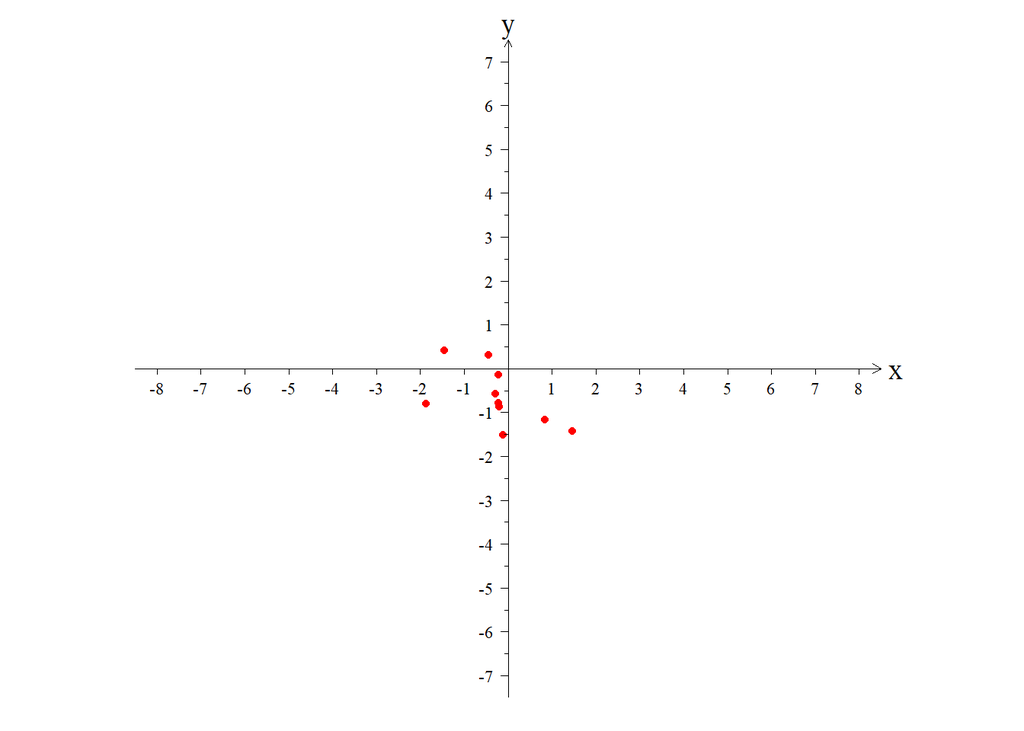

```r
# 加载包
library(ggplot2)

# 定义函数
math.axis <- function(){
  # 定义参数
  # 坐标轴
  axis.width <- 0.3                 #坐标轴线宽
  tick.width <- 0.2                 #轴tick线宽
  axistext.size  <- 3               #轴标签字号
  axistitle.size <- 5               #轴名字字号
  # x轴
  axisx.name <- "x"                 #x轴名字
  axisx.y <- 0                      #x轴与y轴交点的y值，若axisx.y=axisy.x，则重合点不重复标记
  axisx.range <- c(-8.5, 8.5)       #x轴范围
  axisx.break <- seq(-8,8,1)        #x轴主间隔
  axisx.break.minor.n <- 0          #x轴次间隔数，非负整数，若为0，则无次间隔
  shifh <- diff(axisx.range)*0.01   #水平方向上偏移量，用于y轴标签、x轴标题的偏移
  axisx.lab.dec <- 0                #x轴标签数值小数位数，必须为大于0的整型值
  # y轴
  axisy.name <- "y"                 #y轴名字
  axisy.x <- 0                      #y轴与x轴交点的x值，若axisx.y=axisy.x，则重合点不重复标记
  axisy.range <- c(-7.5, 7.5)       #y轴范围
  axisy.break <- seq(-7,7,1)        #y轴主间隔
  axisy.break.minor.n <- 1          #y轴次间隔数，非负整数，若为0，则无次间隔
  shifv <- diff(axisy.range)*0.01   #垂直方向上偏移量，用于x轴标签、y轴标题的偏移
  axisy.lab.dec <- 0                #y轴标签数值小数位数，必须为大于0的整型值
  # 其他
  break.min <- T                    #是否标记次要间隔

  # 参数生成
  # x轴breaks
  if(axisx.break.minor.n == 0){
    axisx.tick <- data.frame(x0=axisx.break, x1=axisx.break, y0=axisx.y, y1=axisx.y-shifv)
  } else{
    axisx.tick.major  <- data.frame(x0=axisx.break, x1=axisx.break, y0=axisx.y, y1=axisx.y-shifv)
    axisx.break.minor <- seq(min(axisx.break), max(axisx.break), diff(axisx.break)[1]/(axisx.break.minor.n+1)) |> setdiff(axisx.break)
    axisx.tick.minor  <- data.frame(x0=axisx.break.minor, x1=axisx.break.minor, y0=axisx.y, y1=axisx.y-shifv*0.5)
    axisx.tick        <- rbind(axisx.tick.major, axisx.tick.minor)
  }
  # y轴breaks
  if(axisy.break.minor.n == 0){
    axisy.tick <- data.frame(x0=axisy.x, x1=axisy.x-shifh, y0=axisy.break, y1=axisy.break)
  } else{
    axisy.tick.major  <- data.frame(x0=axisy.x, x1=axisy.x-shifh, y0=axisy.break, y1=axisy.break)
    axisy.break.minor <- seq(min(axisy.break), max(axisy.break), diff(axisy.break)[1]/(axisy.break.minor.n+1)) |> setdiff(axisy.break)
    axisy.tick.minor  <- data.frame(x0=axisy.x, x1=axisy.x-shifh*0.5, y0=axisy.break.minor, y1=axisy.break.minor)
    axisy.tick        <- rbind(axisy.tick.major, axisy.tick.minor)
  }
  # x轴标签
  axisx.label <- data.frame(x=axisx.break, y=axisx.y-shifv*2, l=sprintf(paste0("%.", axisx.lab.dec, "f"), axisx.break))
  # y轴标签
  axisy.label <- data.frame(x=axisy.x-shifh*2, y=axisy.break, l=sprintf(paste0("%.", axisy.lab.dec, "f"), axisy.break))
  # 剔除交点的标签
  if(axisx.y == axisy.x){
    axisx.label <- axisx.label[axisx.label$x!=axisx.y, ]   #剔除x轴标签中，交点的标签
    axisy.label <- axisy.label[axisy.label$y!=axisy.x, ]   #剔除y轴标签中，交点的标签
  }

  # 生成ggplot组件
  axisx.label <- na.omit(axisx.label)
  axisy.label <- na.omit(axisy.label)
  modu <- list(
    # x轴
    geom_segment(data=NULL, aes(x=axisx.range[1], xend=axisx.range[2], y=axisx.y, yend=axisx.y), linewidth=axis.width, arrow = arrow(length = unit(shifh, "cm"))),
    geom_segment(data=axisx.tick, aes(x=x0, xend=x1, y=y0, yend=y1), linewidth=tick.width),
    geom_text(data=axisx.label, aes(x=x, y=y, label=l), size=axistext.size, vjust=1, hjust=0.5, family = "serif"),
    geom_text(aes(x=axisx.range[2]+shifh, y=axisx.y), label=axisx.name, size=axistitle.size, vjust=0.5, hjust=0, family = "serif"),
    # y轴
    geom_segment(data=NULL, aes(x=axisy.x, xend=axisy.x, y=axisy.range[1], yend=axisy.range[2]), linewidth=axis.width, arrow = arrow(length = unit(shifv, "cm"))),
    geom_segment(data=axisy.tick, aes(x=x0, xend=x1, y=y0, yend=y1), linewidth=tick.width),
    geom_text(data=axisy.label, aes(x=x, y=y, label=l), size=axistext.size, vjust=0.5, hjust=1, family = "serif"),
    geom_text(aes(x=axisy.x, y=axisy.range[2]+shifv), label=axisy.name, size=axistitle.size, vjust=0, hjust=0.5, family = "serif"),
    # 主题
    coord_fixed(),
    theme_void()
    # theme(aspect.ratio = 1)
  )
  return(modu)
}

# 画图
ggplot(data=NULL, aes(x=rnorm(10), y=rnorm(10)))+
  geom_point(color="red")+
  math.axis()
```

## 8.4 聚类树状图

定义了一个函数用于绘制聚类结果树状图，相比默认函数，此函数为不同分类树枝设置了不同颜色。此函数输入数据为纯数值型dataframe，行名为每一行的属性名。

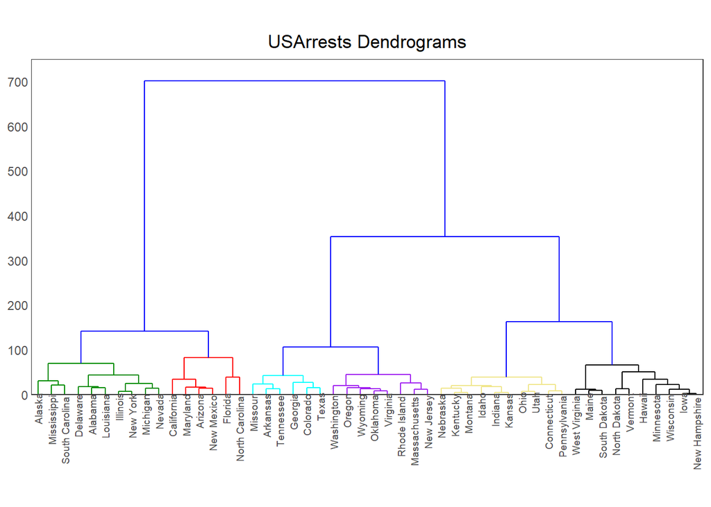

```r
# 加载包
library(ggplot2)
library(data.table)
library(magrittr)

# hclust分类，部分结果含义
# result_hc$merge
#   表示融合过程，每一行是一次融合，负值表示原始观察对象的序号，正值表示已经融合的项目
#   例如：第一行若为 -3 -5，则表示第一次，融合了两个原始观察对象，分别是序号3和5
#   例如：若第三行是1 2，则表示融合了第一次和第二次两个项目，即merge中的第一行和第二行
#   有n个观测对象，则有n-1次融合，即merge为n-1行，负值一共出现n次，因此正值出现2*(n-1)-n=n-2次
# result_hc$height
#   长度为n-1的向量，表示每次的聚类高度
# result_hc$labels
#   观测对象，按原始顺序
# result_hc$order
#   长度为n的向量，表示原观测向量中，每个对象的顺序，即result_hc$labels[result_hc$order]是结果向量
# cutree(result_hc, 3)
#   通过这个函数，查看当给定类别个数时，对象的所属类别

# 定义一个画图函数，画图并标记颜色给指定个数的分类，这个函数修改自网上下载的一段代码，具体来源记不清了
hPlot <- function(data, k=3, method = "ward.D2"){
  result_hc <- hclust(dist(data), method = method)
  len <- nrow(data)                        #数据行数
  lab <- result_hc$labels[result_hc$order] #标签名，按最终结果从左至右的顺序
  # ranks保存x值，包括原始对象的单脚（在1~len）和len-1次聚类的左右脚中心（在len+（len-1））
  #   其中最后一次（第len-1次）聚类的两脚中心，没有实际用处
  ranks <- c(1:(2*len-1))
  ranks[1:len] <- order(result_hc$order)  #替换下面注释的for循环，结果一样
  # for (i in c(1:len)){
  #   ranks[i] <- which(result_hc$order == i)
  # }
  # ranks[(len+1):(len+2)] <- 0  #这行感觉没用，第一次聚类肯定是原始对象，len+1一定被改写了，len+2同理
  for (i in 1:(len-1)){
    rank1 <- 0
    rank2 <- 0
    # 第i次聚合，第1个对象，左脚
    if(result_hc$merge[i,1] < 0){
      rank1 <- ranks[-result_hc$merge[i,1]]       #如果是聚类原始对象，直接是位置
    } else{
      rank1 <- ranks[result_hc$merge[i,1] + len]  #如果已经聚类，聚类次数+len查找已生成的两脚中点
    }
    # 第i次聚合，第2个对象，右脚
    if(result_hc$merge[i,2]<0){
      rank2 <- ranks[-result_hc$merge[i,2]]       #如果是聚类原始对象，直接是位置
    } else{
      rank2 <- ranks[result_hc$merge[i,2]+len]    #如果已经聚类，聚类次数+len查找已生成的两脚中点
    }
    ranks[i+len] <- (rank1 + rank2)/2             #生成左右脚中点
  }
  # heigh保存y值，一共有原始对象的单脚len个，高度为0，和len-1个聚类结果，共2*len-1个高度，聚类结果中有
  heigh <- c(rep(0, len), result_hc$height)
  # heigh <- c(1:(2*len-1))
  # heigh[1:len] <- 0
  # heigh[(len+1):(2*len-1)] <- result_hc$height
  # merge_保存聚类信息，与结果的merge大小相同，但是将原始对象改为正值，将已聚类对象改为+len
  #   将矩阵当向量进行索引，即以列向量的顺序索引
  merge_ <- result_hc$merge
  for (i in 1:(2*(len-1))) {
    if(result_hc$merge[i]>0){
      merge_[i] <- result_hc$merge[i]+len
    } else{
      merge_[i] <- -result_hc$merge[i]
    }
  }
  # x，y：一共是len-1类，每类为一个“n”形，四个控制点
  x <- c(1:4*(len-1))
  y <- c(1:4*(len-1))
  for (i in 1:(len-1)){
    index <- (i-1)*4 + 1      #每次计算四个x和四个y
    x[index] <- ranks[merge_[i,1]]    #左脚下点x
    y[index] <- heigh[merge_[i,1]]    #左脚下点y，可能是原始对象也可能是已聚类对象，所以用merge_
    x[index+1] <- ranks[merge_[i,1]]  #左脚上点x
    y[index+1] <- result_hc$height[i] #左脚上点y，只可能是已聚类对象，所以用result_hc$height
    x[index+2] <- ranks[merge_[i,2]]  #右脚上点x
    y[index+2] <- result_hc$height[i] #右脚上点y，同左脚上点y
    x[index+3] <- ranks[merge_[i,2]]  #右脚下点x
    y[index+3] <- heigh[merge_[i,2]]  #右脚下点y
  }
  clusterData <- data.table(x = x, y = y, group = rep(1:(len-1), each=4))

  # 按给定分类k，画聚类图的不同颜色，其中无法分类的放一组
  res.clus <- cutree(result_hc, k)
  # 数据中，每个聚合四个脚的最小和最大值
  data.range <- clusterData %>% .[, range(x), by="group"]
  # 聚类中，每个类别单独脚的最小和最大值
  clus.range <- data.table(x=1:len, clust =res.clus[rank(result_hc$order)]) %>%
    .[, range(x), by="clust"]
  # 若数据的最小和最大值，在某一类别的最小和最大范围内，则属于该类别
  merge.clus <- data.table(group=1:(len-1), clust=0)
  for(i in 1:(len-1)){
    tdata.range <- data.range[group==i,]
    for(j in 1:k){
      tclus.range <- clus.range[clust==j,]
      minx <- tdata.range[[1,2]] >= tclus.range[[1,2]]  #数据的最小值是否大于分类的最小值
      maxx <- tdata.range[[2,2]] <= tclus.range[[2,2]]  #数据的最大值是否小于分类的最大值
      if(minx&maxx){merge.clus[group==i, clust:=j]}     #如果以上都满足，则数据是这一类
    }
  }
  # 将绘图数据与分类数据连接
  dt.plot <- merge.clus[clusterData, on="group"] %>% .[, clust:=factor(clust)]
  dt.color <- c("0"="blue", "1"="green4", "2"="red", "3"="cyan", "4"="khaki",
                "6"="purple", "5"="black", "7"="magenta", "8"="orange", "9"="pink")

  pic <- ggplot() +
    geom_line(data = dt.plot, mapping = aes(x=x, y=y, group=group, color=clust), linewidth = 0.5, show.legend = F) +
    scale_color_manual(values = dt.color)+
    labs(x = NULL, y = NULL, title = "USArrests Dendrograms")+
    scale_x_continuous(breaks = 1:len, labels = lab, expand = c(0.01,0.01)) +
    scale_y_continuous(limits = c(0,750), breaks = seq(0,700,100), expand = c(0,0)) +
    theme_bw()+
    theme(aspect.ratio = 1/2,
          axis.text.x = element_text(angle = 90, hjust = 1.1, vjust = 0.5, size = 7),
          axis.ticks = element_blank(),
          panel.grid = element_blank(),
          plot.title = element_text(hjust = 0.5))
  return(pic)
}
# 执行函数
hPlot(datasets::USArrests, k=6)
```

## 8.5 饼图

注意案例中使用分类+数值型数据，如果是分类的频数向量，可如下转化

```r
# 初始数据，分类+数值型
# data <- data.table(class = c("B","D","A","C","E","F"), value = c(5,10,20,40,60,20))

# 如果数据为类型频数，可通过以下代码转换
# tdata <- c(rep("B", 5), rep("D", 10), rep("A", 20), rep("C", 40), rep("E", 60))
# data <- table(tdata) %>%  as.data.table() %>%  set_colnames(c("class", "value")) #转换为通用数据
```

### 8.5.1 ggplot2::geom_col

ggplot2::geom_col，配合极坐标变换画pie图, 此时应注意：

- 已经有极坐标了，就不能有coord_fixed()，并且不需要定义aspect.ratio = 1也是正圆
- 由于有y轴极坐标，则xlim控制范围为饼图的径向范围，表现为是否为环或环外是否为空白，ylim为弧向范围，表现为是否为整个圆
- 定义class的因子顺序后，就是col堆叠顺序的唯一影响因素，数据框的行序不会影响堆叠顺序
- 用rev(order(class))排列数据行序，是为了计算geom_col绘图下的文字标记纵向位置lab_y，即影响文字标记顺序。用ggforce::geom_arc_bar绘图时，这行代码不会影响文字标记顺序，但会影响col堆叠顺序
- 由于使用了极坐标变换，ggrepel的nudge_xy位置设定太过混乱，因此ggrepel和geom_col不兼容，ggrepel和ggforce::geom_arc_bar画pie图配合更好

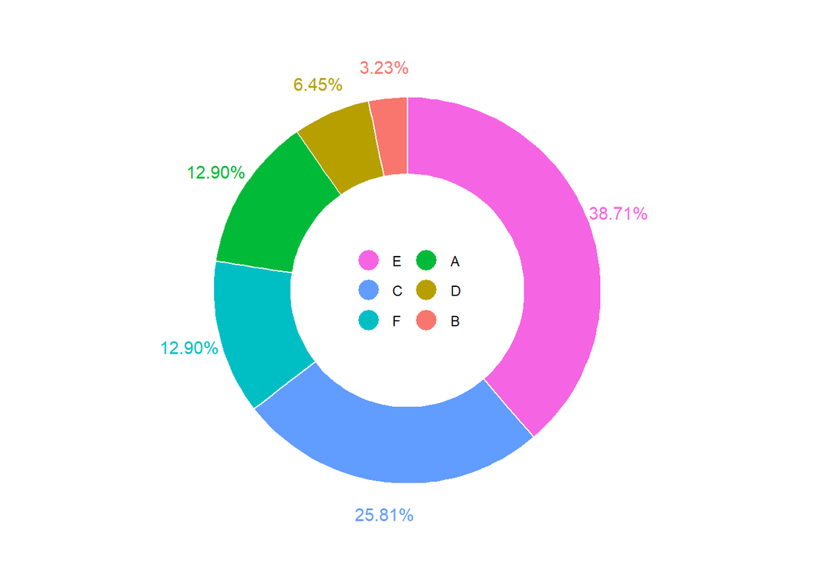

```r
# 加载包
library(data.table)
library(magrittr)
library(ggplot2)
library(ggrepel)
library(ggforce)

# 初始数据，分类+数值型
data <- data.table(class = c("B","D","A","C","E","F"), value = c(5,10,20,40,60,20))

# 数据整理
class_level <- c("B", "D", "A", "F", "C", "E")            #level：占比由低到高
df <- copy(data) %>%
  .[, class:=factor(class, levels=class_level)] %>%       #设定分类为因子型
  .[rev(order(class)),] %>%                               #因子分类逆序排列，影响文字标记顺序
  .[, prob:=value/sum(value)] %>%                         #计算占比
  .[, lab_y:=cumsum(prob)-0.5*prob] %>%                   #计算文字标签位置
  .[, lab_t:=sprintf("%.2f%%", prob*100)]                 #生成文字标签（按需选样式）

# 画图
ggplot(df)+
  geom_col(aes(x=1, y=prob, fill=class), width=1, color='white', linewidth=0.5, #col宽1，则从0.5至1.5
           key_glyph=draw_key_point)+             #修改图例样式为点图例
  geom_text(aes(x=1.9, y=lab_y, label=lab_t, color=class))+
  guides(fill=guide_legend(ncol = 2, reverse = T, title=NULL,
                           override.aes = list(shape=21, size=6)), color="none")+ #强制更改图例形状大小
  coord_polar(theta = "y", direction = 1, start = pi*0)+
  xlim(c(-1, 2))+                                 #col左侧留空则为环图
  ylim(c(0, 1))+                                  #col为整个圆，即从0度到360度
  theme_void()+
  theme(
    legend.position = "inside",
    legend.position.inside = c(0.5,0.5)
  )
```

### 8.5.2 ggforce::geom_arc_bar(★)

ggforce::geom_arc_bar，使用笛卡尔坐标系画pie图，此时应注意：

- stat=pie时，直接使用极坐标画饼图，不需要极坐标变换，但是文字标记位置要转换
- 由于ggforce::geom_arc_bar不是极坐标，因此需要正圆时，必须设置xlim和ylim为相等范围，并且设置coord_fixed()
- 用rev(order(class))排列数据行序，是为了计算geom_col绘图下的文字标记纵向位置lab_y，即影响文字标记顺序。用ggforce::geom_arc_bar绘图时，这行代码不会影响文字标记顺序，但会影响col堆叠顺序
- ggrepel::geom_text_repel中，很多参数不支持aes映射，只能在aes外部使用向量传递不同参数，如segment.color/nudge/segment.curvature等等
- ggrepel的官方教程：https://ggrepel.slowkow.com/articles/examples.html

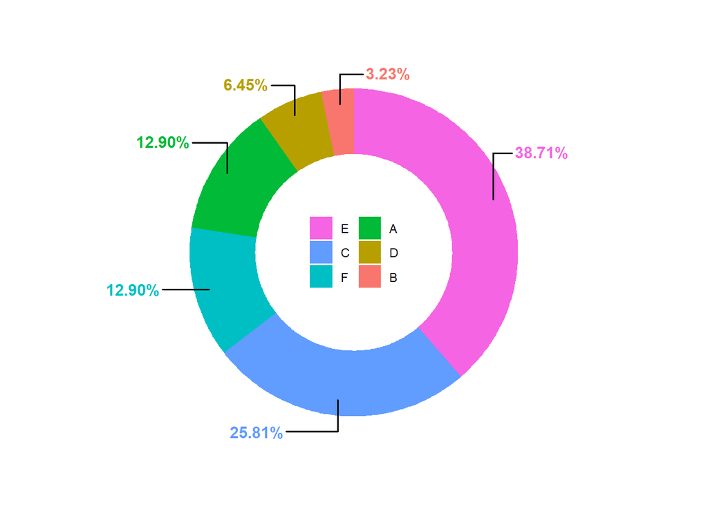

```r
# 加载包
library(data.table)
library(magrittr)
library(ggplot2)
library(ggrepel)
library(ggforce)

# 初始数据，分类+数值型
data <- data.table(class = c("B","D","A","C","E","F"), value = c(5,10,20,40,60,20))

# 数据整理
class_level <- c("B", "D", "A", "F", "C", "E")          #level：占比由低到高
df2 <- copy(data) %>%
  .[, class:=factor(class, levels=class_level)] %>%     #设定分类为因子型
  .[rev(order(class)),] %>%                             #因子分类逆序排列，不影响文字，影响bar
  .[, prob:=value/sum(value)] %>%                       #计算占比
  .[, lab_y:=cumsum(prob)-0.5*prob] %>%                 #计算文字标签位置
  .[, lab_t:=sprintf("%.2f%%", prob*100)] %>%           #生成文字标签（按需选样式）
  .[, explo:=c(0,0,0,0,0,0)] %>%                      #explode，标记部分突出的大小
  .[, lab_a:=lab_y*2*pi] %>%                            #文本位置的角度
  .[, lab_r:=c(0.9,0.9,0.9,0.9,0.9,0.9)]                #文本位置的半径，有explode那个半径要更长

# ggrepel参数
# 弯折方向和幅度
cd <- c(1, 1, 0, -1, -1, 1)   #正数表示先向前再右转；负数表示先向前再左转
# 颜色
fcol <- c("#F564E3", "#619CFF", "#00BFC4", "#00BA38", "#B79F00", "#F8766D")
# 偏移量
nx <- c(0.3, -0.5, -0.5, -0.4, -0.3, 0.3)
ny <- c(0.3, -0.2,    0,  0.2,  0.2, 0.2)

# 绘图范围参数，确定其他所有参数后，使用默认主题绘图，即可查看显示区域所占范围，然后确定阈值
xy_range <- c(-1.4, 1.4)

# 绘图
ggplot(data = df2) +
  geom_arc_bar(aes(x0=0, y0=0, r0=0.6, r=1, amount=prob, explode=explo, fill=class), stat = 'pie', color = F) +
  geom_text_repel(aes(x=lab_r*sin(lab_a), y=lab_r*cos(lab_a), label=lab_t), size=4, fontface="bold",
                  color=fcol,                #字体颜色
                  nudge_x=nx, nudge_y=ny,    #位置偏移
                  segment.color="black",     #单独设定指示线颜色
                  segment.size=0.6,          #指示线粗细
                  segment.angle=90,          #弯折角度
                  segment.shape=0,           #曲线类型，0为直线
                  segment.curvature = cd,    #弯折方向与程度
                  segment.square = T,        #指示线是否水平竖直
                  segment.inflect = F        #允许2个拐点
  )+
  guides(fill=guide_legend(ncol = 2, reverse = T, title=NULL), color="none")+
  lims(x=xy_range, y=xy_range)+
  coord_fixed()+
  theme_void()+
  theme(
    legend.position = "inside",
    legend.position.inside = c(0.5,0.5)
  )
```

### 8.5.3 ggforce::geom_arc_bar

注意：

- 仅仅是定义了一个数据处理函数，让标记和位置转换更方便，有一些花哨的功能，学术绘图中并不是很实用

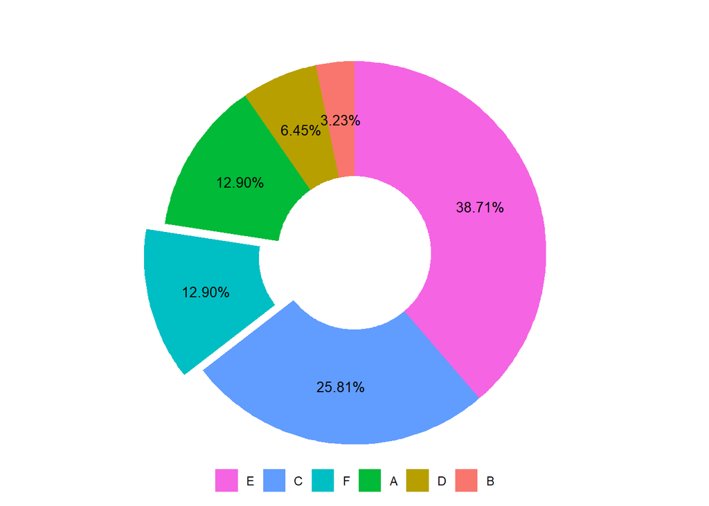

```r
# 加载包
library(data.table)
library(magrittr)
library(ggplot2)
library(ggrepel)
library(ggforce)

# 初始数据，分类+数值型
data <- data.table(class = c("B","D","A","C","E","F"), value = c(5,10,20,40,60,20))

# 定义一个饼图数据生成函数，输入所需参数生成可直接用于ggforce::geom_arc_bar的数据
piedata <- function(data, class_level, r_start=0, r_end=1, lab_r=(r_start+r_end)*0.7, radian=0,
                    direction=1, e_index=NA_integer_, e_scale=0.1, model="number"){
  # 定义一个将绘图数据转化为pie图数据的函数
  # 注意所有参数并无可行性检查，因此输入错误没有自定义stop功能，要自行保证输入正确参数
  # 自定义选项包括：
  # data：以data.table类型存储的数据，仅有两列，一列为class，另一列为value
  # class_level：class的level，由前到后为占比的由高到低
  # model：转化方式，为"number"时，data格式为value，或"prob"时，data为占比
  # r_start：半径起始长度，默认为0
  # r_end：半径终止长度，默认为1，起始0终止1即为整个扇形区域
  # lab_r：标签所在位置半径长度，默认为0.7倍扇形半径
  # radian：扇形起始的附加弧度，默认为0弧度
  # direction：排列方向，默认为1顺时针
  # e_index：突出显示的类，默认无突出
  # e_scale：突出显示尺度，默认为0.1，即突出长度为e_scale*r_end
  # 读取和定义数据
  setDT(data)
  # 基础处理
  dfout <- copy(data) %>%
    .[, class:=factor(class, levels=class_level)] %>%     #设定分类为因子型
    .[rev(order(class)),] %>%                             #因子分类逆序排列，不影响文字，影响bar
    .[, prob:=value/sum(value)]                           #计算占比
  class_numb <- length(class_level)
  # 生成标签文字，有需要继续修改
  if(model == "number"){
    dfout[, lab_t:=value]
  } else{
    dfout[, lab_t:=sprintf("%.2f%%", prob*100)]
  }
  # 生成圆心、半径绘制范围
  # dfout[,c("x_0", "y_0"):=list(0,0)]
  dfout$x_0 <- 0; dfout$y_0 <- 0
  dfout[,c("r_start", "r_end"):=list(r_start,r_end)]
  # 生成每一类扇形的起始弧度（包括附加弧度和排列方向）
  da_prob <- dfout$prob
  rad_s <- c(0, cumsum(da_prob))[1:class_numb]*2*pi + radian   #定义扇形起始弧度
  rad_e <- cumsum(da_prob)*2*pi + radian                       #定义扇形终止弧度
  if(direction == -1) {rad_s <- rad_s*-1; rad_e <- rad_e*-1}   #定义旋转方向后，弧度的变化
  dfout[,c("rad_start", "rad_end"):=list(rad_s, rad_e)]
  # 设置标签的位置、内容
  rad_mean <- (rad_s+rad_e)/2  #扇形中心弧度
  dfout[,c("lab_x", "lab_y"):=list(lab_r*sin(rad_mean), lab_r*cos(rad_mean))] #定义标签xy坐标
  # 对有explode项的x0,y0,lab_x,lab_y进行修改
  if(!is.na(e_index)[1]){
    e_value <- e_scale*r_end    #explode的数值，是e_csale乘以半径r
    x_expl <- e_value*sin(rad_mean[e_index])
    y_expl <- e_value*cos(rad_mean[e_index])
    dfout[e_index, c("x_0","y_0"):=list(x_expl, y_expl)]
    lab_x_e <- (lab_r+e_value)*sin(rad_mean[e_index])
    lab_y_e <- (lab_r+e_value)*cos(rad_mean[e_index])
    dfout[e_index, c("lab_x","lab_y"):=list(lab_x_e,lab_y_e)]
  }
  # 结束，输出数据
  return(dfout)
}

# 生成饼图数据
class_level <- c("B", "D", "A", "F", "C", "E")          #level：占比由低到高
df3 <- piedata(data, class_level, r_start=0.4, r_end=1, lab_r=0.7,
               radian=pi*0, direction=1, e_index=3, e_scale=0.1, model="prob")

# 绘图范围参数，确定其他所有参数后，使用默认主题绘图，即可查看显示区域所占范围，然后确定阈值
xy_range <- c(-1.2, 1.2)

# 绘图
ggplot(df3) +
  geom_arc_bar(aes(x0 = x_0, y0 = y_0, r0 = r_start, r = r_end, start = rad_start, end = rad_end, fill = class), stat="arc_bar", color = F) +
  geom_text(aes(x = lab_x, y = lab_y, label = lab_t), color = "black", size = 3.5)+
  guides(fill=guide_legend(nrow = 1, reverse = T, title=NULL), color="none")+
  coord_fixed()+
  lims(x=xy_range, y=xy_range)+
  theme_void()+
  theme(
    legend.position = "inside",
    legend.position.inside = c(0.5,0.05)
  )
```

## 8.6 华夫饼图

使用geom_tile画华夫饼图

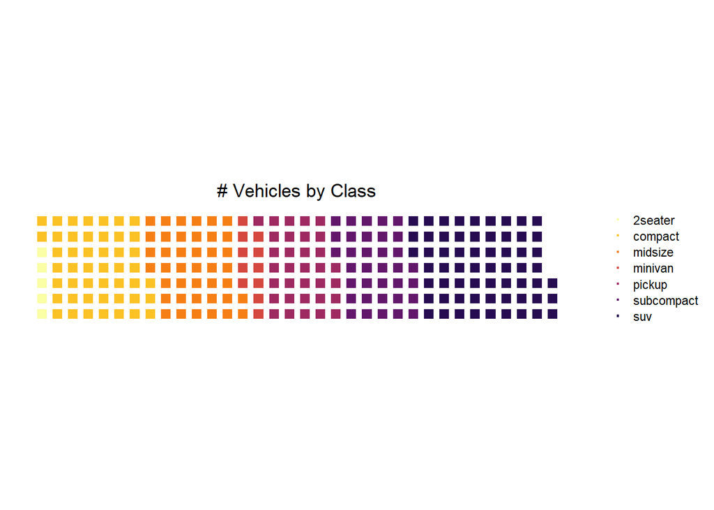

```r
# 加载包
library(ggplot2)
library(data.table)
library(magrittr)

# 数据
df_color <- c("#faffa5", "#fbc226", "#f67f15", "#d5483f", "#9e2a61", "#62176b", "#270c52")
df <- ggplot2::mpg
num <- nrow(df)
df.row <- 7
df.col <- ceiling(num/df.row)
df.plot <- data.table(x=rep(1:df.col, each=df.row), y=rep(1:df.row, df.col)) %>%
  .[1:num, ] %>%
  .[, group:=sort(df$class)]

# 绘图
ggplot(data = df.plot, aes(x, y, fill = group))+
  geom_tile(color="white", size=2)+  #size是边框的宽度
  scale_fill_manual(values = df_color)+
  guides(fill = guide_legend(keyheight = unit(0.4, "cm"), keywidth = unit(0.4, "cm"), title = NULL))+
  labs(x = NULL, y = NULL, title = "# Vehicles by Class")+
  theme_bw()+
  theme(aspect.ratio = df.row/df.col,
        axis.ticks = element_blank(),
        axis.text = element_blank(),
        panel.grid = element_blank(),
        panel.border = element_blank(),
        plot.title = element_text(hjust = 0.5))
```

## 8.7 数字趋势图

网上找的一个代码例子，绘制24种癌症5、10、15、20年后的生存概率，数据及代码参考如下网址：https://github.com/jkeirstead/r-slopegraph

以下代码相比原版，删除了所有dplyr包函数，全部使用data.table包进行数据处理，并大幅精简了全部代码

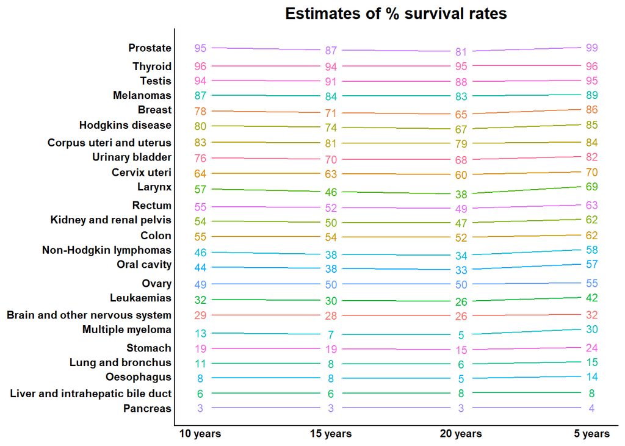

```r
# 加载包
library(ggplot2)
library(data.table)
library(magrittr)

# 数据可使用如下在线读取。本案例读取后化简， 以文本形式展示如下。
# source_df <- read.csv("https://raw.githubusercontent.com/jkeirstead/r-slopegraph/master/cancer_survival_rates.csv")
dat <- data.table(group=c('Oral cavity', 'Oesophagus', 'Stomach', 'Colon', 'Rectum',
                          'Liver and intrahepatic bile duct', 'Pancreas', 'Larynx',
                          'Lung and bronchus', 'Melanomas',  'Breast', 'Cervix uteri',
                          'Corpus uteri and uterus',  'Ovary', 'Prostate', 'Testis',
                          'Urinary bladder', 'Kidney and renal pelvis',
                          'Brain and other nervous system', 'Thyroid',
                          'Hodgkins disease', 'Non-Hodgkin lymphomas',
                          'Multiple myeloma', 'Leukaemias') %>% rep(4),
                  year=c(5,10,15,20) %>% rep(each=24),
                  value=c(56.7, 14.2, 23.8, 61.7, 62.6, 7.5, 4, 68.8, 15, 89, 86.4, 70.5,
                          84.3, 55, 98.8, 94.7, 82.1, 61.8, 32, 96, 85.1, 57.8, 29.5, 42.5,
                          44.2, 7.9, 19.4, 55.4, 55.2, 5.8, 3, 56.7, 10.6, 86.7, 78.3, 64.1,
                          83.2, 49.3, 95.2, 94, 76.2, 54.4, 29.2, 95.8, 79.8, 46.3, 12.7,
                          32.4, 37.5, 7.7, 19, 53.9, 51.8, 6.3, 2.7, 45.8, 8.1, 83.5, 71.3,
                          62.8, 80.8, 49.9, 87.1, 91.1, 70.3, 49.8, 27.6, 94, 73.8, 38.3, 7,
                          29.7, 33, 5.4, 14.9, 52.3, 49.2, 7.6, 2.7, 37.8, 6.5, 82.8, 65, 60,
                          79.2, 49.6, 81.1, 88.2, 67.9, 47.3, 26.1, 95.4, 67.1, 34.3, 4.8,
                          26.2))
# 数据处理函数
tufte_sort <- function(data, min.space=0.05) {
  # 列重命名
  dt <- copy(data)   #
  setnames(dt, c("year","value"), c("x", "y"))

  # 以防数据中有缺失，采用expand.grid生成所有可能的xy类别
  dt1 <- expand.grid(x=unique(dt$x), group=unique(dt$group)) %>%
    setDT() %>%
    .[dt, on = c("x", "group")] %>%
    .[is.na(y), y:=0]

  # 拆分x（年份）为列名，并以5年为升序排列
  dt2 <- dcast(dt1, group~x, value.var = "y") %>% setorder(5)

  # 计算每个group的y偏移量，如果某个group与上面一个的偏移量小于最小偏移量，则赋值为差值，否则不偏移
  minspace <- dt2[,-1] %>% unlist() %>% range() %>% diff() %>% multiply_by(min.space)
  yshift <- numeric(nrow(dt2))
  for (i in 2:nrow(dt2)) {
    d.min <- as.matrix(dt2[(i-1):i, -1]) %>% diff() %>% min()
    yshift[i] <- ifelse(d.min < minspace, minspace - d.min, 0)
  }

  # 将偏移量累加、还原为长数据、定义y位置为y+scale*yshift
  scale <- 1
  dt3 <- dt2[, yshift:=cumsum(yshift)] %>%
    melt(., id=c("group", "yshift"), variable.name = "x", value.name = "y") %>%
    .[,ypos:=y+scale*yshift]
  x_level <- names(dt2)[-1] %>% sort()
  x_label <- paste(x_level, "years")
  dt3[, x:=factor(x, levels = x_level, labels = x_label)]
  dt3[, y:=round(y)]
  return(dt3)
}

# 数据处理
dat_plot <- tufte_sort(dat, min.space=0.6)
# 画图
ylabs <- subset(dat_plot, x==head(x,1))$group
yvals <- subset(dat_plot, x==head(x,1))$ypos
ggplot(dat_plot,aes(x=x,y=ypos,color=group)) +
  geom_line(aes(group=group)) +
  geom_point(colour="white", size=8) +
  geom_text(aes(label=y), size=3) +
  scale_y_continuous(name="", breaks=yvals, labels=ylabs)+
  scale_x_discrete(expand = c(0.05,0.05))+
  labs(title="Estimates of % survival rates") +
  theme_classic()+
  theme(axis.title=element_blank(),
        legend.position = "none",
        axis.ticks = element_blank(),
        plot.title = element_text(hjust=0.5, face="bold"),
        axis.text = element_text(face="bold"))
```

## 8.8 概率分布图

### 8.8.1 单个概率密度

正态拟合与累计概率图

注意：geom_area，默认情况下是填充线与y=0轴之间的面积

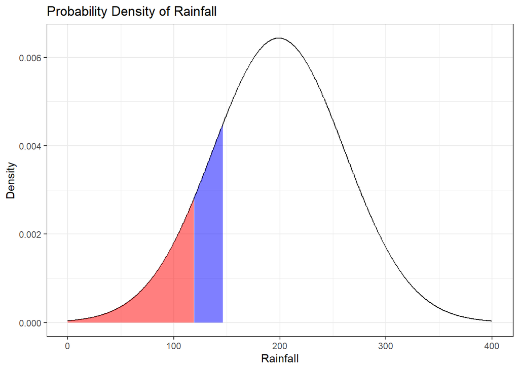

```r
# 加载包
library(ggplot2)

# 生成数据
data <- data.frame(year = c(2022, 2021, 2020, 2019, 2018, 2017,
                            2016, 2015, 2014, 2013, 2012, 2011,
                            2010, 2009, 2008, 2007, 2006, 2005),
                   pre = c(389, 145.8, 168.8, 200.5, 222.5, 199.5,
                           209.7, 279.8, 172.4, 131.6, 178.3, 132.2,
                           183.5, 152.7, 263.9, 165.9, 202.1, 178))
rain_mu <- mean(data$pre)
rain_sd <- sd(data$pre)

# 用数据点均值方差，拟合一个正态分布
a <- seq(0, 400, length=1000)               #均值为198.6778，x范围两侧扩展200
b <- dnorm(a, mean=rain_mu, sd=rain_sd)     #求得每个x对应的概率密度

# 求解正态分布对应的x值与密度值
pre_10 <- qnorm(0.10,   mean = rain_mu, sd = rain_sd)    #累计密度10%对应的降水量
pre_20 <- qnorm(0.20,   mean = rain_mu, sd = rain_sd)    #累计密度20%对应的降水量
# den_10 <- dnorm(pre_10, mean = rain_mu, sd = rain_sd)    #10%降水量对应的密度值
# den_20 <- dnorm(pre_20, mean = rain_mu, sd = rain_sd)    #20%降水量对应的密度值

# 画图填充累计概率小于10%以及10%至20%的范围
ggplot(data.frame(a, b), aes(x = a, y = b)) +
  geom_line() +
  geom_area(data = subset(data.frame(a, b), a <= pre_10), aes(x = a, y = b), fill = "red", alpha = 0.5) +
  geom_area(data = subset(data.frame(a, b), a <= pre_20&a>=pre_10), aes(x = a, y = b), fill = "blue", alpha = 0.5) +
  labs(title = "Probability Density of Rainfall", x = "Rainfall", y = "Density")+
  theme_bw()
```

在R语言中，统计分布基本都对应四个函数，例如对于正态分布，四个函数包括：

- dnorm: 概率密度函数PDF，正态分布的概率密度值，自变量是正无穷到负无穷的数x，因变量是x对应的正态分布概率密度，即$P(X=x)$
- pnorm: 累积分布函数CDF，正态分布的累积分布函数值，自变量是正无穷到负无穷的数x，因变量是x在正态分布上的累计概率密度，即$P(X\leq x)$
- qnorm: 分位点函数Quantile，正态分布的分位数，自变量是01区间的概率p，因变量是p的分位数值，即$P(X\leq x)=p$对应的x值，含义是，“在这个分布中，多大的值x，使得小于等于x的概率恰好是p”。本质上，pnorm和qnorm互为反函数
- rnorm: 随机数生成函数，生成满足正态分布的一系列随机数

前三个的函数曲线，以及rnorm生成的随机数（point）如下图所示：

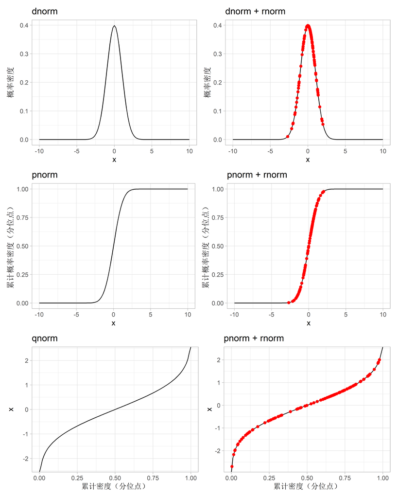

```r
# 加载包
library(ggplot2)
library(patchwork)

# 散点数据
x <- rnorm(100)
dx <- dnorm(x)
px <- pnorm(x)

# 函数图像
p1 <- ggplot()+
  geom_function(fun=dnorm)+
  scale_x_continuous(limits = c(-10,10))+
  labs(x="x", y="概率密度", title="dnorm")+
  theme_light()
p2 <- ggplot()+
  geom_function(fun=dnorm)+
  annotate("point", x=x, y=dx, color="red")+
  scale_x_continuous(limits = c(-10,10))+
  labs(x="x", y="概率密度", title="dnorm + rnorm")+
  theme_light()
p3 <- ggplot()+
  geom_function(fun=pnorm)+
  scale_x_continuous(limits = c(-10,10))+
  labs(x="x", y="累计概率密度（分位点）", title="pnorm")+
  theme_light()
p4 <- ggplot()+
  geom_function(fun=pnorm)+
  annotate("point", x=x, y=px, color="red")+
  scale_x_continuous(limits = c(-10,10))+
  labs(x="x", y="累计概率密度（分位点）", title="pnorm + rnorm")+
  theme_light()
p5 <- ggplot()+
  geom_function(fun=qnorm)+
  scale_x_continuous(limits = c(0,1))+
  labs(x="累计密度（分位点）", y="x", title="qnorm")+
  theme_light()
p6 <- ggplot()+
  geom_function(fun=qnorm)+
  annotate("point", x=px, y=x, color="red")+
  scale_x_continuous(limits = c(0,1))+
  labs(x="累计密度（分位点）", y="x", title="pnorm + rnorm")+
  theme_light()

# 合并
(p1 + p2) / (p3 + p4) / (p5 + p6)
```

### 8.8.2 山脊图

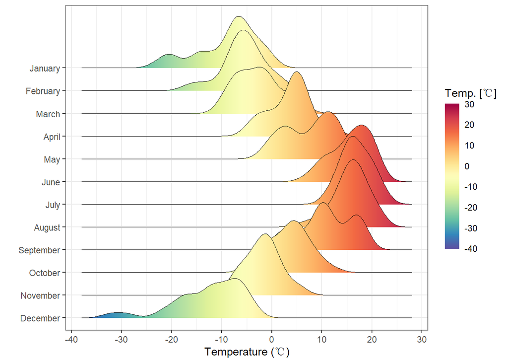

```r
# 加载包
library(ggplot2)
library(ggridges)
library(RColorBrewer)
library(data.table)
library(magrittr)

# 数据
dt <- lincoln_weather[c("Month", "Min Temperature [F]")] %>%
  setDT() %>%
  set_colnames(c("Month", "tem")) %>%
  .[,tem:=(tem-32)*5/9]                   #转华氏为摄氏
colfill <- colorRampPalette(rev(brewer.pal(11, 'Spectral')))(32)

# 绘图
# 三个版本意义相同..x..、stat(x)、after_stat(x)，但是..x..从ggplot2 v3.4.0开始被弃用了
ggplot(dt, aes(x = tem, y = Month)) +
  geom_density_ridges_gradient(aes(fill = after_stat(x)),  scale = 3, linewidth = 0.3) +
  scale_y_discrete(expand = c(0.05,0,0.25,0))+
  scale_x_continuous(breaks = seq(-40,30,10))+
  scale_fill_gradientn(colours = colfill, limit=c(-40, 30), breaks=seq(-40,30, 10), name = "Temp. [℃]") +
  guides(fill = guide_colorbar(barheight = 10, barwidth = 1, ticks.colour=NA))+
  labs(x="Temperature (℃)", y="")+
  theme_bw()
```

## 8.9 填充图

总结了ggplot中，填充某个区域的几种方法

### 8.9.1 矩形区域

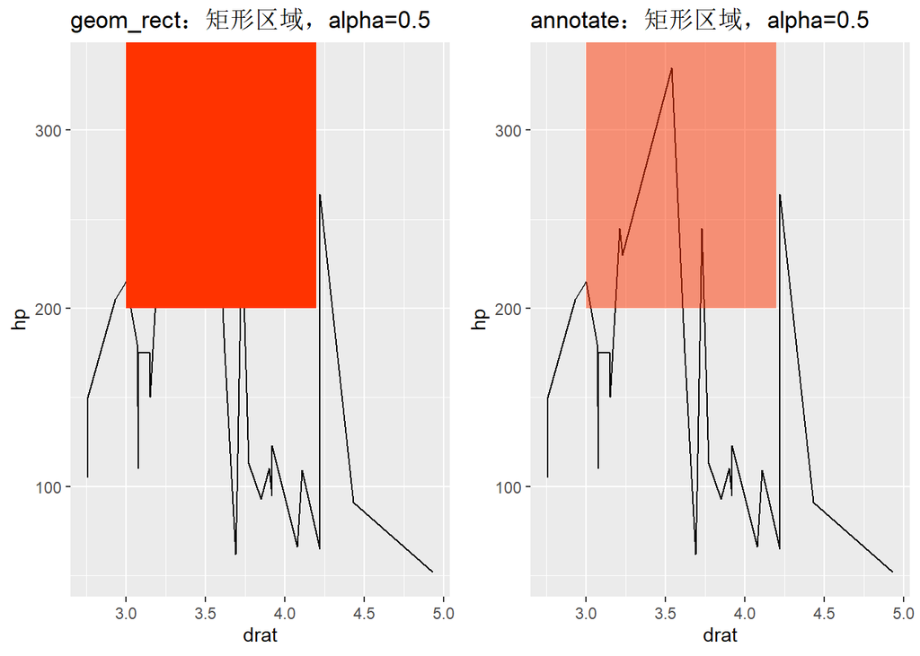

```r
# 加载包
library(ggplot2)
library(cowplot)  #拼图
# library(ggpubr) #拼图不用这个包，ggarrange函数太笨，必须同时设置额ncol和nrow

# 绘图
# geom_rect
p1 <- ggplot(mtcars, aes(x = drat, y = hp)) +
  geom_line() +
  geom_rect(aes(xmin=3, xmax=4.2, ymin=200, ymax=Inf),fill='#FF3300',alpha = 0.5)+
  labs(title = "geom_rect：矩形区域，alpha=0.5")

# annotate+rect，同理，但是相同alpha下颜色会比上面的潜很多
p2 <- ggplot(mtcars, aes(x = drat, y = hp)) +
  geom_line() +
  annotate("rect", xmin = 3, xmax = 4.2, ymin=200, ymax=Inf,fill='#FF3300', alpha = 0.5)+
  labs(title = "annotate：矩形区域，alpha=0.5")

plot_grid(p1, p2, nrow=1)
```

### 8.9.2 两线相交

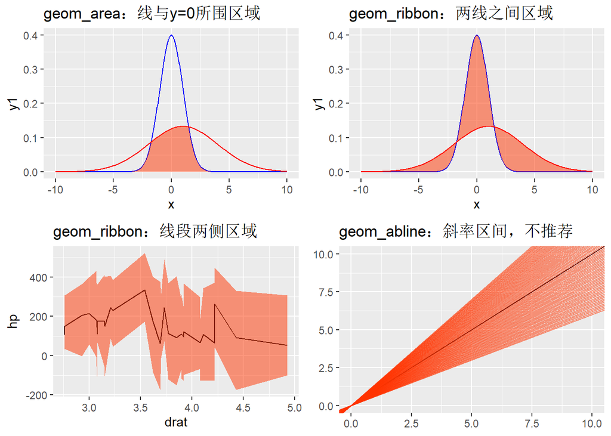

```r
# 加载包
library(ggplot2)
library(cowplot)

# 数据
x  <- seq(-10, 10, length = 500)
y1 <- dnorm(x, mean = 0,sd = 1)
y2 <- dnorm(x, mean = 1,sd = 3)
dt <- data.frame(x, y1, y2)

# 绘图
# geom_area，与y=0围城的区域，aes中只有y
p1 <- ggplot(dt, aes(x = x)) +
  geom_line(aes(y = y1), colour = 'blue') +
  geom_line(aes(y = y2), colour = 'red') +
  geom_area(aes(y = pmin(y1, y2)), fill = '#FF3300', alpha=0.5)+
  labs(title = "geom_area：线与y=0所围区域")

# geom_ribbon，两线之间的区域，aes中有ymin和ymax
p2 <- ggplot(dt, aes(x = x))+
  geom_line(aes(y = y1), colour = 'blue') +
  geom_line(aes(y = y2), colour = 'red')+
  geom_ribbon(aes(ymin = y1, ymax = y2), fill = '#FF3300', alpha=0.5) +  #结果同下，ymin和ymax没有顺序
  # geom_ribbon(aes(ymin = pmin(y1,y2), ymax = pmax(y1,y2)), fill = '#FF3300', alpha=0.5) +  #注意是pmin而不是min
  labs(title = "geom_ribbon：两线之间区域")

# geom_ribbon，线段两侧区域
p3 <- ggplot(mtcars, aes(x = drat, y = hp)) +
  geom_line() +
  geom_ribbon(aes(ymin=hp-rnorm(32, 200, 50), ymax=hp+rnorm(32, 200, 50)), fill = "#FF3300", alpha = 0.5) +
  labs(title = "geom_ribbon：线段两侧区域")

# geom_abline，两直线之间区域的另一种方法，不推荐
p4 <- ggplot() +
  geom_abline(slope = 1, intercept = 0) +
  geom_abline(slope = seq(0.6, 1.4, 0.01), intercept = 0, color = "#FF3300", alpha=0.5) +
  scale_x_continuous(limits = c(0,10)) +
  scale_y_continuous(limits = c(0,10)) +
  labs(title = "geom_abline：斜率区间，不推荐")

plot_grid(p1, p2, p3, p4, nrow=2)
```

### 8.9.3 两线相交不同色

通过对轴和线之间的区域进行着色，面积图不仅更加强调波峰和波谷，还更加强调高点和低点的持续时间。高点持续时间越长，线下面积越大。

这个图需要注意，如果不填充不同颜色，则没什么问题，一旦要以x轴为分界，上下填充不同颜色，则需要差值以增加数据密度。

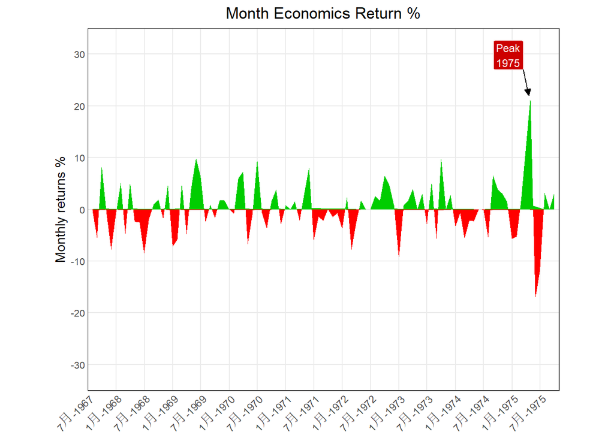

```r
# 加载包
library(ggplot2)
library(data.table)
library(magrittr)

# 准备一个差值函数，用以扩充数据量，
# 目的是，例如对于y正、负、正交替出现的情况，即x1的y>0，之后有部分x2,x3...xn-1的y<0，然后又是xn的y>0，函数将x尽量细分，以使x1和xn的y值接近0,
# 这样对y>0和y<0填充不同颜色时，让x2,x3...xn-1的y>0部分填充足够小以至于看不见（若不对y>0和y<0填充不同颜色，则不会填充这部分）
# 函数处理过后的数据，对y>0和y<0填充不同颜色，与填充相同颜色，填充部分看起来是一样的

# 函数
dat_interp = function(x, y, line = 0, length.out=500) {
  a <- approx(x, x, xout=seq(min(x), max(x), length.out=length.out))$y
  b <- approx(x, y, xout=seq(min(x), max(x), length.out=length.out))$y
  if("POSIXct" %in% class(x)) a <- as.POSIXct(a, origin='1970-01-01', tz='UTC')
  res <- data.table(x = a, y = b)
  res[y < line, value:="lower"]
  res[y >= line, value:="greater"]
  return(res)
}

# 数据
df <- ggplot2::economics %>% .[1:100,] %>% setDT()
df[, returns:=c(0,diff(df$psavert)/df$psavert[1:99])*100]     #注意这里的计算方法，本期增长率=(本期-上期)/上期
# 差值为新数据
df_date <- df[["date"]] %>% as.POSIXct(tz = "UTC")  #提取日期
df_inte <- dat_interp(df_date, df$returns, length.out = 5000)
# 箭头数据
df_arro <- data.table(x = as.POSIXct(c("1975-03-15", "1975-04-20")), y = c(27, 22))
# 标签数据
df_labe <- data.table(x = as.POSIXct("1975-03-15"), y = 27, l = "Peak\n1975")
b_date <- as.POSIXct("1967-07-01", tz = "UTC")
e_date <- as.POSIXct("1975-11-01", tz = "UTC")

# 绘图
ggplot()+
  geom_area(data = df_inte, aes(x, y, fill = value), show.legend = F)+
  geom_line(data = df_arro, aes(x,y), arrow = arrow(length = unit(0.2, "cm"), type = "closed", angle = 25))+
  geom_label(data = df_labe, aes(x,y,label = l), hjust = 1, vjust = 0, fill = "red3", color = "white", size = 3)+
  scale_fill_manual(values = c("greater" = "green3", "lower" = "red"))+
  scale_x_datetime(date_labels = "%b-%Y", breaks = seq(b_date, e_date, by = "6 month"), limits = c(b_date, e_date), expand = c(0,0))+
  scale_y_continuous(limits = c(-35,35), expand = c(0,0), breaks = seq(-30,30,10))+
  labs(x = NULL, y = "Monthly returns %", title = "Month Economics Return %")+
  theme_bw()+
  theme(aspect.ratio = 1/1.3,
        axis.ticks = element_blank(),
        axis.text.x = element_text(angle = 45, hjust = 1),
        axis.text.y = element_text(size = 8),
        panel.grid.minor = element_blank(),
        plot.title = element_text(hjust = 0.5))
```

### 8.9.4 不规则区域

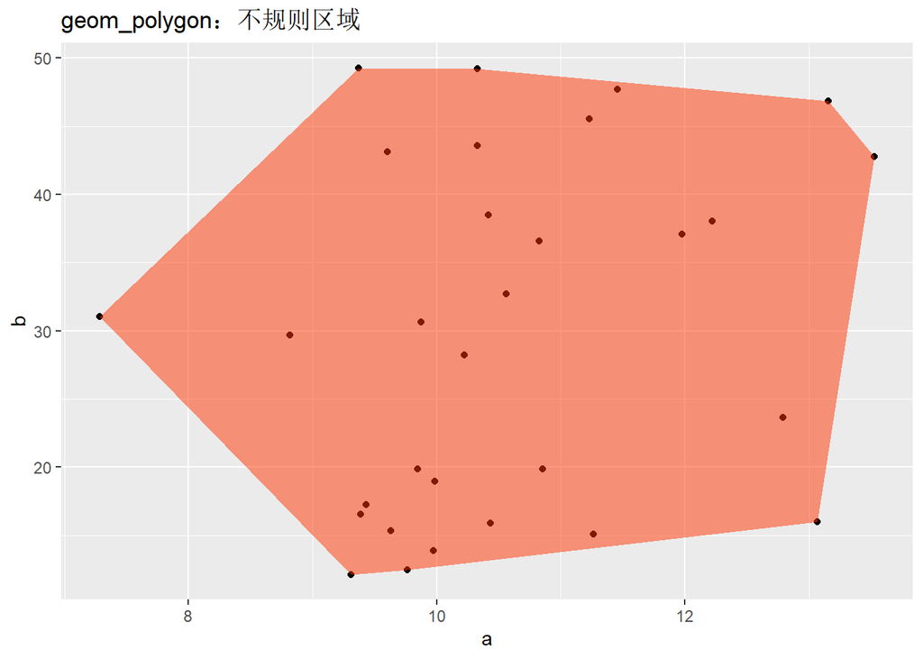

```r
# 加载包
library(ggplot2)

# 数据
dat <- data.frame(a=rnorm(30, 10, 2), b=runif(30, 10, 50))
dat_poly <- c(chull(dat), chull(dat)[1])             #求凸包点的行号，重复第首点使其围成区域

# 绘图
ggplot()+
  geom_point(data = dat, mapping = aes(a, b))+
  geom_polygon(data = dat[dat_poly, ], mapping = aes(a, b, group = 1), fill="#FF3300", alpha=0.5) +
  labs(title = "geom_polygon：不规则区域")
```

### 8.9.5 栅格图

注意此图边缘很模糊，原因是数据精度太低，调节精度即可有清晰的栅格边缘，但是数据量大、画图慢。

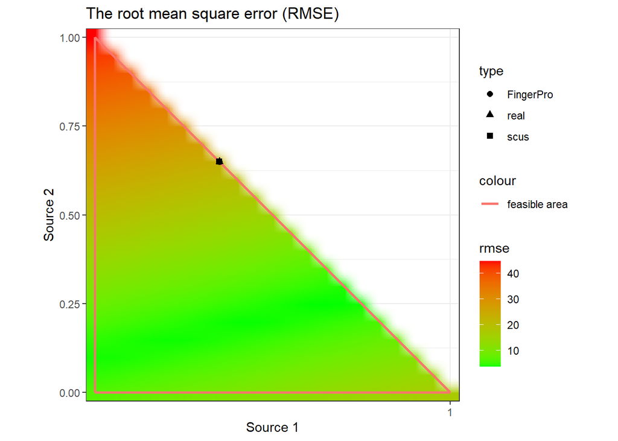

```r
# 加载包
library(ggplot2)
library(data.table)
library(magrittr)

# 数据
dat <- data.table(id = 1:4,
                  class = c("s1", "s2", "s3", "mix.sample"),
                  t1 = c(468.5, 555.2, 484.9, 492.0),
                  t2 = c(29.8, 28.7, 29.9, 24.1))
point <- data.table(type = c("real", "scus", "FingerPro"),
                    s1 = 0.35, 0.72, 0.61,
                    s2 = 0.65, 0.28, 0.39)

coeA <- dat[1:3, 3:4] %>% as.matrix() %>% t()
coeB <- dat[4, 3:4] %>% as.numeric() %>% matrix(ncol = 1)

RMSE <- function(s1, s2){
  s3 <- 1-s1-s2
  w <- matrix(c(s1,s2,s3), ncol = 3)
  er <- function(x) sqrt(sum((coeB - coeA%*%matrix(x, ncol = 1))^2)/nrow(coeB))
  res <- apply(w, 1, er)
  return(res)
}
a <- seq(0, 10, by = 0.05)
b <- seq(0, 5, by = 0.05)
s1 <- rep(a, each = length(b))
s2 <- rep(b, time = length(a))
source <- data.table(s1 = s1, s2 = s2)
source[, rmse:=RMSE(s1, s2)]
feasible <- data.table(a0=c(0,0,1), a1=c(0,1,0), b0=c(0,1,0), b1=c(1,0,0))

# 绘图
ggplot()+
  geom_raster(data = source[s1+s2<=1,], mapping = aes(s1, s2, fill = rmse), interpolate = TRUE)+
  scale_fill_continuous(low = "green", high = "red")+
  geom_segment(data = feasible, mapping = aes(x=a0, xend=a1, y=b0, yend=b1, color = "feasible area"), size=1)+
  geom_point(data = point, mapping = aes(s1, s2, shape = type), size = 2)+
  scale_x_continuous(breaks = seq(1, 10, by = 1), expand = c(0, 0))+
  scale_y_continuous(expand = c(0, 0))+
  coord_fixed(ratio = 1)+
  labs(x = "Source 1", y = "Source 2", title = "The root mean square error (RMSE)")+
  theme_bw()
```

### 8.9.6 热力图

[figure not shown]

```r
mtscaled <- as.matrix(scale(mtcars))
heatmap(mtscaled,
        col = topo.colors(200, alpha=0.5),
        Colv=F, scale="none")
```

### 8.9.7 瓦片图

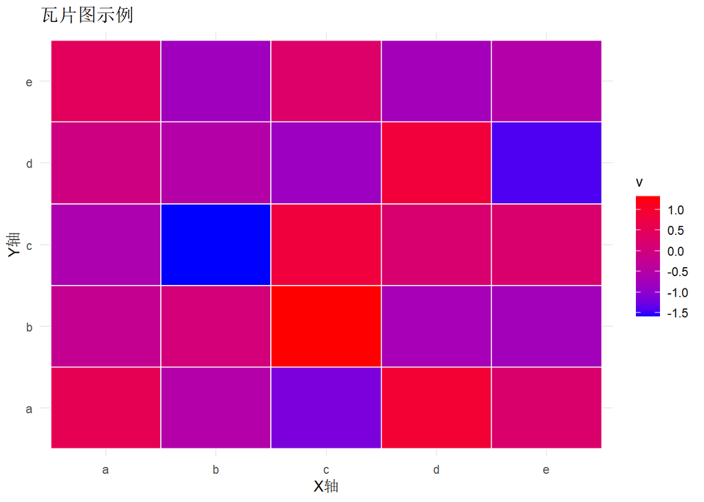

```r
# 加载包
library(ggplot2)

# 数据
data <- data.frame(
  x = rep(letters[1:5], times=5),
  y = rep(letters[1:5], each=5),
  v <- rnorm(25)
)

# 绘图
ggplot(data, aes(x = x, y = y, fill = v)) +
  geom_tile(color = "white", linewidth= 0.5) +  # 添加白色边框
  scale_fill_gradient(low = "blue", high = "red") +  # 设置颜色渐变
  labs(title = "瓦片图示例", x = "X轴", y = "Y轴") +
  theme_minimal()  # 使用简洁主题
```

## 8.10 烛线图

烛线图实际上就是箱线图的自定义模式

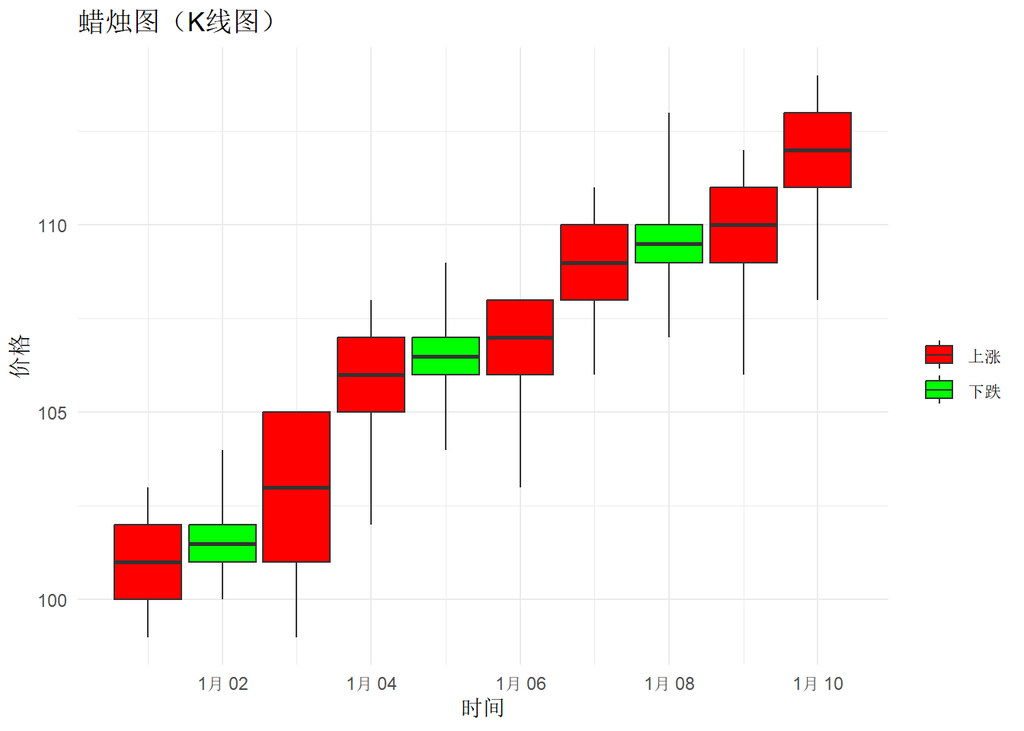

```r
# 加载包
library(ggplot2)

# 数据
data <- data.frame(
  time = as.Date('2024-01-01') + 0:9,
  open = c(100, 102, 101, 105, 107, 106, 108, 110, 109, 111),
  high = c(103, 104, 103, 108, 109, 108, 111, 113, 112, 114),
  low = c(99, 100, 99, 102, 104, 103, 106, 107, 106, 108),
  close = c(102, 101, 105, 107, 106, 108, 110, 109, 111, 113)
)

# 绘图
ggplot(data, aes(x = time)) +
  geom_boxplot(aes(
    ymin = low,
    ymax = high,
    lower = pmin(open, close),
    upper = pmax(open, close),
    middle = (open + close) / 2,
    fill = factor(ifelse(close > open, "上涨", "下跌")),
    group = time
  ), stat = "identity") +
  scale_fill_manual(values = c("下跌" = "green", "上涨" = "red")) +
  guides(fill = guide_legend(title = ""))+    #线title
  theme_minimal() +
  labs(title = "蜡烛图（K线图）", x = "时间", y = "价格")
```

## 8.11 桑基图

桑基图是一种数据可视化流程图，强调从一个状态到另一个状态或从一个时间到另一个时间的流动，每个箭头的宽度与其所代表流动的数量或大小成比例。

复刻了一篇[nature论文](https://doi.org/10.1038/ngeo2840)中的桑基图，代码部分参考了如下知乎文章：

- [“R语言绘图系列 | 桑基图”](https://zhuanlan.zhihu.com/p/676138038)
- [“R语言绘制桑基图”](https://zhuanlan.zhihu.com/p/3386835680)

注意这里的数据时从论文图片数字化来的，因此并不是论文中的精确数值

### 8.11.1 networkD3包

networkD3包的优点是，图可交互、可悬停突出显示、拖动node，缺点是独立R包，可调参数少，node顺序不可用代码调

```r
# install.packages("networkD3")  #安装包
# 加载包
library(dplyr)
library(networkD3)
library(magrittr)

# 数据
data <- data.frame(source = c('United States', 'China', 'Europe', 'Rest of World',
                              'United States', 'China', 'Europe', 'Rest of World',
                              'United States', 'China', 'Europe', 'Rest of World',
                              'United States', 'China', 'Europe', 'Rest of World',
                              'Concrete', 'Mortar', 'Concrete', 'Mortar', 'Concrete',
                              'CKD', 'Loss', 'In serveice', 'Demolition',
                              'Landfill and recy.',  'In serveice', 'Demolition',
                              'Landfill and recy.'),
                   target = c('Concrete', 'Concrete', 'Concrete', 'Concrete', 'Mortar',
                              'Mortar', 'Mortar', 'Mortar', 'CKD', 'CKD', 'CKD', 'CKD',
                              'Loss', 'Loss', 'Loss', 'Loss', 'In serveice',
                              'In serveice', 'Demolition', 'Demolition',
                              'Landfill and recy.',  'Landfill and recy.',
                              'Landfill and recy.', 'Sequestered', 'Sequestered',
                              'Sequestered', 'In atmosphere', 'In atmosphere',
                              'In atmosphere'),
                   value = c(4.962329042, 19.0830062, 14.81739305, 21.46276932,
                             1.544478102, 7.586113028, 6.314189886, 8.676332864,
                             0.434790054, 0.869580108, 0.869580108, 0.869580108,
                             0.226312956, 0.452625912, 0.452625912,  0.452625912,
                             56.05546992, 23.89398475, 3.924791411, 0.436087935,
                             0.345236282, 3.107126534, 1.811319825, 31.54857402,
                             1.415303912, 5.014719579, 48.40088065, 2.945575434,
                             0.248963061))
# 自定义颜色
cus_colo <- c("#3584BC", "#A7D493", "#DA3C3D", "#F6A09F", "#B7CCEB", "#F58A2A",
              "#3FA848", "#9E76B4", "#C8B7D7", "#96685C", "#CBA69E", "#9F77B5")

# 识别节点，即便用factor也不能自定义节点顺序
nodes_name <- c(as.character(data$source), as.character(data$target)) %>% unique()
nodes <- data.frame(name=factor(nodes_name, levels = nodes_name))

# 构造数据
links <- data
links$IDsource <- match(data$source, nodes$name)-1
links$IDtarget <- match(data$target, nodes$name)-1
cus_colo2 <- paste0('d3.scaleOrdinal().range(["', paste(cus_colo, collapse = '", "'), '"])')
# 绘制桑基图
sankeyNetwork(Links = links,        #输入链接数据
              Nodes = nodes,        #输入节点数据
              Source = "IDsource",  #源变量
              Target = "IDtarget",  #汇变量
              Value = "value",      #值变量
              NodeID = "name",      #节点名称
              height = 350,         #图宽in pixels
              width = 500,          #图高in pixels
              colourScale=cus_colo2,#自定义颜色，注意使用JavaScript比例函数
              # units = "Cm",       #cm好像不管用
              LinkGroup = 'source', #颜色分组
              iterations = 2,       #节点深度，y位置
              nodeWidth = 5,        #节点宽度
              nodePadding = 10,     #节点panding，越小越铺满y轴
              fontSize = 12,        #字号，如嫌文字多余，可以设置为0隐藏它们
              fontFamily = "mono",  #字体
              sinksRight = F        #最右标签是否在右侧
)
```

[interactive chart not shown]

### 8.11.2 ggsankey包(★)

ggsankey包的优点是，能和ggplot2无缝衔接，多参数可调，缺点是数据结构复杂，只有静态图

注意，对于ggsankey包：

1. 长数据如上data，是最好准备的数据，应该包含以下几列
   - x：当前节点的层级stage（数值型或因子型，不能是字符型）
   - node：当前节点node的名称
   - next_x：下一个节点的层级
   - next_node：下一个节点的名称
   - value：链接的权重值，即流量flow
2. 数据最后一行必须包含x当前节点和value权重值，否者终点没有或者重叠，但是下一个层级和节点是NA
3. 可以用make_long函数将短数据转为长数据，但是短数据的底层逻辑还是堆叠图那套思路
4. 虽然默认有legend，但是显示效果很差，不标注在图上很难看清
5. ggsankey包支持两种geom，sankey和alluvial，前者node居中，后者低端对齐主要用来画堆叠图（x连续），除此外差别不大。本例中，用后者更还原
6. 这里为了复刻论文图，自定义颜色、标记特定文字，这都需要单独指定文本，并将字符型转换为特定level的因子，因此耗费大量精力，实际使用时可适当省略此过程

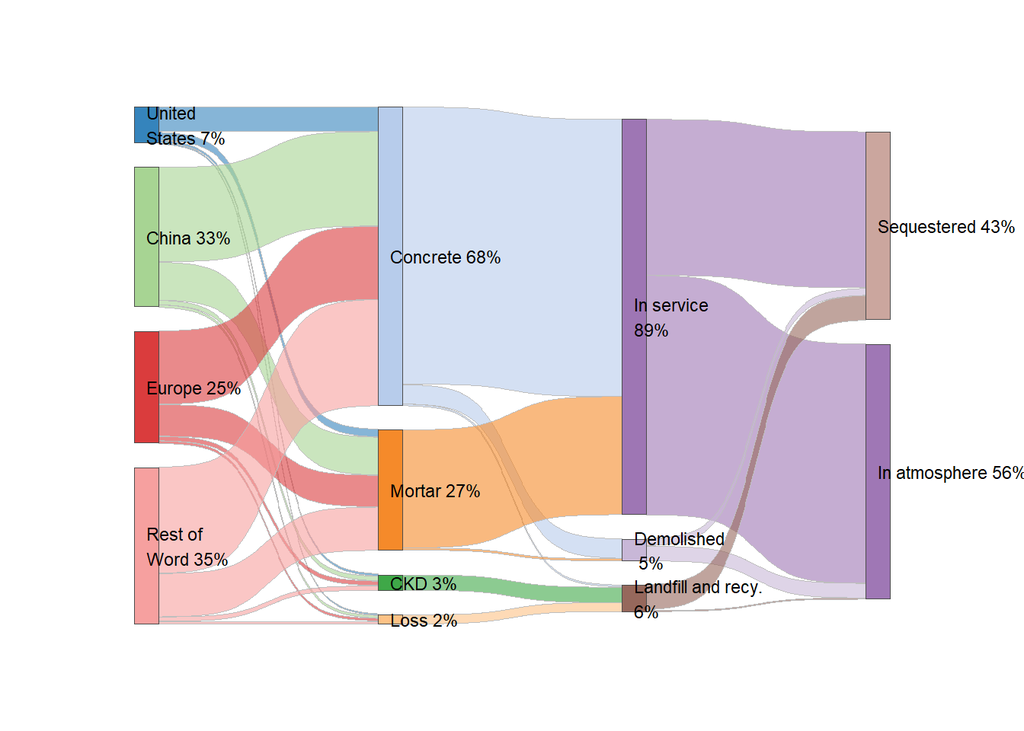

```r
# 安装ggsankey
# devtools::install_github("davidsjoberg/ggsankey")
# 参考
# https://github.com/davidsjoberg/ggsankey

# 加载包
library(ggsankey)
library(ggplot2)
library(data.table)

# 数据，注意与networkD3包数据结构不同
data <- data.table(x = c('Region', 'Region', 'Region', 'Region', 'Region', 'Region',
                         'Region', 'Region', 'Region', 'Region', 'Region', 'Region',
                         'Region', 'Region', 'Region', 'Region', 'Cement_materials',
                         'Cement_materials', 'Cement_materials', 'Cement_materials',
                         'Cement_materials', 'Cement_materials', 'Cement_materials',
                         'Current_life_cycle', 'Current_life_cycle',
                         'Current_life_cycle', 'Current_life_cycle',
                         'Current_life_cycle', 'Current_life_cycle', 'Current_status',
                         'Current_status'),
                   node = c('United States', 'China', 'Europe', 'Rest of World',
                            'United States', 'China', 'Europe', 'Rest of World',
                            'United States', 'China', 'Europe', 'Rest of World',
                            'United States', 'China', 'Europe', 'Rest of World',
                            'Concrete', 'Mortar', 'Concrete', 'Mortar', 'Concrete',
                            'CKD', 'Loss', 'In serveice', 'Demolition',
                            'Landfill and recy.', 'In serveice', 'Demolition',
                            'Landfill and recy.', 'Sequestered', 'In atmosphere'),
                   next_x = c('Cement_materials', 'Cement_materials',
                              'Cement_materials', 'Cement_materials',
                              'Cement_materials', 'Cement_materials',
                              'Cement_materials', 'Cement_materials',
                              'Cement_materials', 'Cement_materials',
                              'Cement_materials', 'Cement_materials',
                              'Cement_materials', 'Cement_materials',
                              'Cement_materials', 'Cement_materials',
                              'Current_life_cycle', 'Current_life_cycle',
                              'Current_life_cycle', 'Current_life_cycle',
                              'Current_life_cycle', 'Current_life_cycle',
                              'Current_life_cycle', 'Current_status', 'Current_status',
                              'Current_status', 'Current_status', 'Current_status',
                              'Current_status', NA, NA),
                   next_node = c('Concrete', 'Concrete', 'Concrete', 'Concrete',
                                 'Mortar', 'Mortar', 'Mortar', 'Mortar', 'CKD', 'CKD',
                                 'CKD', 'CKD', 'Loss', 'Loss', 'Loss', 'Loss',
                                 'In serveice', 'In serveice', 'Demolition',
                                 'Demolition', 'Landfill and recy.',
                                 'Landfill and recy.', 'Landfill and recy.',
                                 'Sequestered', 'Sequestered', 'Sequestered',
                                 'In atmosphere', 'In atmosphere', 'In atmosphere',
                                 NA, NA),
                   value = c(4.962329042, 19.0830062, 14.81739305, 21.46276932,
                             1.557857762, 7.651830769, 6.368889084, 8.751495071,
                             0.443875219, 0.887750438, 0.887750438, 0.887750438,
                             0.258759975, 0.51751995, 0.51751995, 0.51751995,
                             56.05546992, 23.89398475, 3.924791411, 0.436087935,
                             0.345236282, 3.107126534, 1.811319825, 31.54857402,
                             1.415303912, 5.014719579, 48.40088065, 2.945575434,
                             0.248963061, 37.97859751, 51.59541915))

# 自定义每个node的颜色
cus_colo <- c("United States"="#3584BC", "China"="#A7D493", "Europe"="#DA3C3D",
              "Rest of World"="#F6A09F", "Concrete"="#B7CCEB", "Mortar"="#F58A2A",
              "CKD"="#3FA848", "Loss"="#FDC286", "In serveice"="#9E76B4",
              "Demolition"="#C8B7D7",  "Landfill and recy."="#96685C",
              "Sequestered"="#CBA69E", "In atmosphere"="#9F77B5")
# 自定义每个node的标签
node_label <- c("United States"="United\nStates 7%", "China"="China 33%",
                "Europe"="Europe 25%", "Rest of World"="Rest of\nWord 35%",
                "Concrete"="Concrete 68%", "Mortar"="Mortar 27%",
                "CKD"="CKD 3%", "Loss"="Loss 2%", "In serveice"="In service\n89%",
                "Demolition"="Demolished\n 5%",
                "Landfill and recy."="Landfill and recy.\n6%",
                "Sequestered"="Sequestered 43%", "In atmosphere"="In atmosphere 56%")
data_nodename <- data.table(node=names(node_label), label_text=node_label)

# 生成绘图数据
dat_plot <- data_nodename[data, on="node"]

# 指定层级和其中的node为factor，并且指定对应的level，用于自定义排布顺序，注意由y由高到低level是逆序
stage_level <- c("Region", "Cement_materials", "Current_life_cycle", "Current_status")
node_level  <- c("United States", "China", "Europe", "Rest of World", "Concrete",
                 "Mortar", "CKD", "Loss", "In serveice", "Demolition",
                 "Landfill and recy.", "Sequestered", "In atmosphere")

dat_plot[, c("x", "next_x", "node", "next_node", "label_text"):=list(
  factor(x, levels = stage_level),
  factor(next_x, levels = stage_level),
  factor(node, levels = rev(node_level)),
  factor(next_node, levels = rev(node_level)),
  factor(label_text, levels = rev(node_label))
)]

# 绘制桑基图
ggplot(dat_plot, aes(x=x, next_x=next_x, node=node, next_node=next_node, value=value, fill=node)) +
  geom_sankey(                        #alluvial中node为低端对齐，"sankey"为居中
    width = 0.1,                        #node宽度
    space = 5,                          #node间距
    size = 0.1,                         #node边框宽度
    node.color = "gray30",              #node边框颜色
    flow.alpha = .6,                    #flow透明度
    flow.color = "gray",                #flow边框颜色
    smooth = 6,                         #flow平滑度
    # type = "alluvial",                #可以定义不同的，但默认是对应geom的
    na.rm = TRUE                        #删除 NA 数据
  ) +
  scale_fill_manual(values=cus_colo) +  #使用自定义颜色向量
  geom_sankey_text(                   #要对应前面的type
    aes(label = label_text),            #节点标签列
    size = 3,                           #标签字体大小
    space = 5,                          #node间距，要与上面相同
    color = "black",                    #标签颜色
    vjust = 0.5,
    hjust = 0
  ) +
  theme_void() +
  theme(
    aspect.ratio = 1/1.8,
    legend.position = "none"
  )
```

### 8.11.3 ggsankeyfier包

ggsankeyfier包，和ggsankey包很像，但是node顺序调节方面有点问题，

必要数据结构：

- node：节点
- stage：层级
- connector：连接，from或to
- edge_id：flow的id，同一个flow只包含一个from和to
- value：数值

注意：

1. ggsankeyfier包要求每个node的from必须等于同，这是因为ggsankeyfier包对form和to分别画node，因此如果一个node的from不等于to，将导致node分两块，此时文字标签将出现重复、叠加现象。
2. ggsankeyfier包的数据可以通过ggsankey包数据转换得到，这里不再重新定义数据了
3. ggsankeyfier包的stage最好为from至to的factor，否则需要在多个图层定义顺序，很麻烦
4. 使用`as_is`自定义node没成功，这里降序排列node，即每个stage中，node由上至下顺序为由大到小
5. 虽然是sankey图层，但是node默认底端对齐而不是居中，是类似ggsankey包的alluvial布局

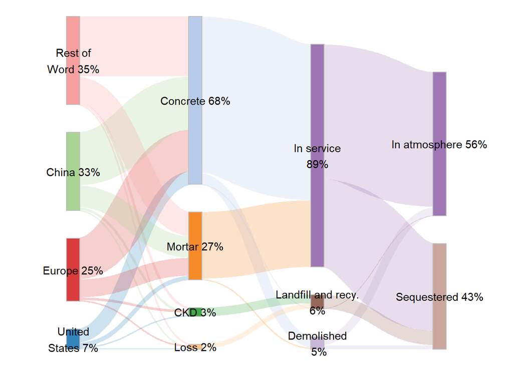

```r
# 加载包
library(ggplot2)
library(data.table)
library(magrittr)
# install.packages("ggsankeyfier")
library(ggsankeyfier)

# 数据，注意与networkD3包数据结构不同
data <- data.table(x = c('Region', 'Region', 'Region', 'Region', 'Region', 'Region',
                         'Region', 'Region', 'Region', 'Region', 'Region', 'Region',
                         'Region', 'Region', 'Region', 'Region', 'Cement_materials',
                         'Cement_materials', 'Cement_materials', 'Cement_materials',
                         'Cement_materials', 'Cement_materials', 'Cement_materials',
                         'Current_life_cycle', 'Current_life_cycle',
                         'Current_life_cycle', 'Current_life_cycle',
                         'Current_life_cycle', 'Current_life_cycle', 'Current_status',
                         'Current_status'),
                   node = c('United States', 'China', 'Europe', 'Rest of World',
                            'United States', 'China', 'Europe', 'Rest of World',
                            'United States', 'China', 'Europe', 'Rest of World',
                            'United States', 'China', 'Europe', 'Rest of World',
                            'Concrete', 'Mortar', 'Concrete', 'Mortar', 'Concrete',
                            'CKD', 'Loss', 'In serveice', 'Demolition',
                            'Landfill and recy.', 'In serveice', 'Demolition',
                            'Landfill and recy.', 'Sequestered', 'In atmosphere'),
                   next_x = c('Cement_materials', 'Cement_materials',
                              'Cement_materials', 'Cement_materials',
                              'Cement_materials', 'Cement_materials',
                              'Cement_materials', 'Cement_materials',
                              'Cement_materials', 'Cement_materials',
                              'Cement_materials', 'Cement_materials',
                              'Cement_materials', 'Cement_materials',
                              'Cement_materials', 'Cement_materials',
                              'Current_life_cycle', 'Current_life_cycle',
                              'Current_life_cycle', 'Current_life_cycle',
                              'Current_life_cycle', 'Current_life_cycle',
                              'Current_life_cycle', 'Current_status', 'Current_status',
                              'Current_status', 'Current_status', 'Current_status',
                              'Current_status', NA, NA),
                   next_node = c('Concrete', 'Concrete', 'Concrete', 'Concrete',
                                 'Mortar', 'Mortar', 'Mortar', 'Mortar', 'CKD', 'CKD',
                                 'CKD', 'CKD', 'Loss', 'Loss', 'Loss', 'Loss',
                                 'In serveice', 'In serveice', 'Demolition',
                                 'Demolition', 'Landfill and recy.',
                                 'Landfill and recy.', 'Landfill and recy.',
                                 'Sequestered', 'Sequestered', 'Sequestered',
                                 'In atmosphere', 'In atmosphere', 'In atmosphere',
                                 NA, NA),
                   value = c(4.962329042, 19.0830062, 14.81739305, 21.46276932,
                             1.557857762, 7.651830769, 6.368889084, 8.751495071,
                             0.443875219, 0.887750438, 0.887750438, 0.887750438,
                             0.258759975, 0.51751995, 0.51751995, 0.51751995,
                             56.05546992, 23.89398475, 3.924791411, 0.436087935,
                             0.345236282, 3.107126534, 1.811319825, 31.54857402,
                             1.415303912, 5.014719579, 48.40088065, 2.945575434,
                             0.248963061, 37.97859751, 51.59541915))

# 使用ggsankey包画图时的数据进行转换
dat_temp <- data[, {c("from", "to")}, by=c("x", "node", "next_x", "next_node", "value")]  #生成connector的from或to
dat_temp[, edge_id:=.GRP,by=c("x", "node", "next_x", "next_node", "value")] #生成edge_id
dat_temp[V1=="to", c("x", "node"):=list(next_x, next_node)]                 #替换node和stage
dat_plot_temp <- copy(dat_temp) %>%
  .[, c("next_x","next_node"):=list(NULL, NULL)] %>%                    #next列没有用了
  set_colnames(c("stage","node", "value", "connector", "edge_id")) %>%  #更新列名
  na.omit()                                   #最后stage的node，只有from没有to

# 自定义每个node的颜色
cus_colo <- c("United States"="#3584BC", "China"="#A7D493", "Europe"="#DA3C3D",
              "Rest of World"="#F6A09F", "Concrete"="#B7CCEB", "Mortar"="#F58A2A",
              "CKD"="#3FA848", "Loss"="#FDC286", "In serveice"="#9E76B4",
              "Demolition"="#C8B7D7",  "Landfill and recy."="#96685C",
              "Sequestered"="#CBA69E", "In atmosphere"="#9F77B5")
# 自定义每个node的标签
node_label <- c("United States"="United\nStates 7%", "China"="China 33%",
                "Europe"="Europe 25%", "Rest of World"="Rest of\nWord 35%",
                "Concrete"="Concrete 68%", "Mortar"="Mortar 27%",
                "CKD"="CKD 3%", "Loss"="Loss 2%", "In serveice"="In service\n89%",
                "Demolition"="Demolished\n 5%",
                "Landfill and recy."="Landfill and recy.\n6%",
                "Sequestered"="Sequestered 43%", "In atmosphere"="In atmosphere 56%")
data_nodename <- data.table(node=names(node_label), label_text=node_label)

# 融合标签列
dat_plot <- data_nodename[dat_plot_temp, on="node"]

# 定义stage的顺序
stage_level <- c("Region", "Cement_materials", "Current_life_cycle", "Current_status")
dat_plot[, stage:=factor(stage, levels = stage_level)]

ggplot(dat_plot, mapping = aes(x = stage,
                               y = value,
                               group = node,
                               edge_id = edge_id,
                               connector = connector)) +
  geom_sankeyedge(aes(fill = node),
                  position = position_sankey(
                    order = "ascending",     #只能放position中，虽然有as_is，但效果很差
                    v_space = 10,
                    width = 0.01,
                  ), alpha = 0.5, show.legend = F) +
  geom_sankeynode(aes(fill = node), color = "grey",
                  position = position_sankey(
                    order = "ascending",
                    v_space = 10,
                    width = 0.11
                  ), show.legend = FALSE) +
  geom_text(aes(label = label_text),
            stat = "sankeynode",
            position = position_sankey(
              order = "ascending",
              v_space = 10,
            )) +
  scale_fill_manual(values = cus_colo)+
  theme_void()+
  theme(
    panel.grid.major.y = element_blank(),
    axis.text.y = element_blank(),
    axis.title = element_blank(),
    legend.key.spacing.x = unit(60, "pt")
  )
```

### 8.11.4 ggalluvial包

ggalluvial包的逻辑还是堆叠图那套，对于桑基图或类似ggsankey中的堆叠图并不擅长

下面是一个ggalluvial包内的例子，类似桑基图的

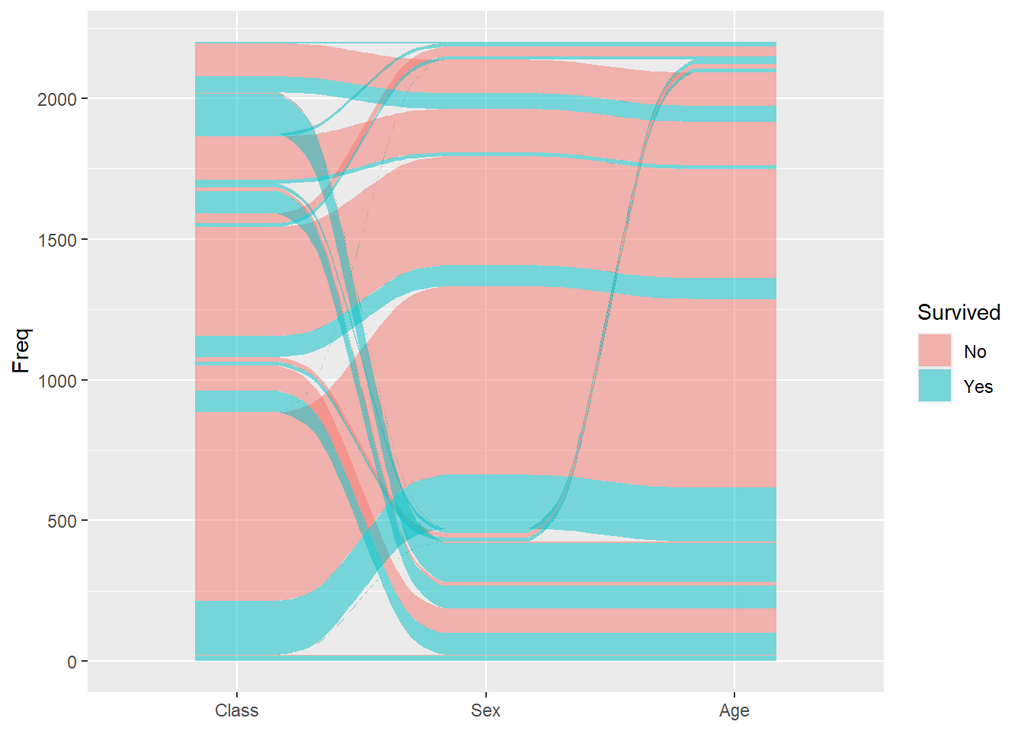

```r
# 加载包
library(ggplot2)
library(ggalluvial)

# 绘图
ggplot(as.data.frame(Titanic),
       aes(y = Freq,
           axis1 = Class, axis2 = Sex, axis3 = Age,
           fill = Survived)) +
  geom_alluvium() +
  scale_x_discrete(limits = c("Class", "Sex", "Age"))
```

### 8.11.5 ggalluvial桑基+气泡

修改自代码：https://zhuanlan.zhihu.com/p/1891949362524975991

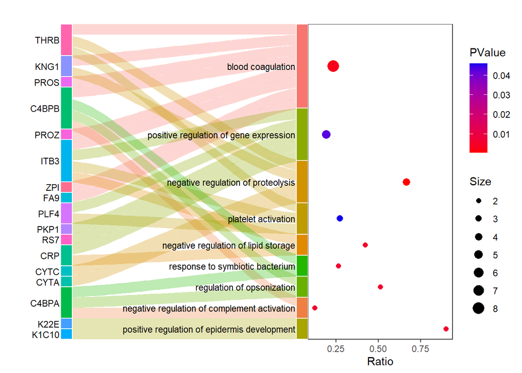

```r
# 加载包
# library(tidyverse)
library(ggplot2)
library(data.table)
library(magrittr)
library(ggalluvial)
library(patchwork)

# 数据
dt <- data.table(TermID=c('GO:0007596', 'GO:0010628', 'GO:0045861', 'GO:0030168', 'GO:0010888',
                          'GO:0009609', 'GO:1903027', 'GO:0045959', 'GO:0045684'),
                 Term=c('blood coagulation',
                        'positive regulation of gene expression',
                        'negative regulation of proteolysis',
                        'platelet activation',
                        'negative regulation of lipid storage',
                        'response to symbiotic bacterium',
                        'regulation of opsonization',
                        'negative regulation of complement activation',
                        'positive regulation of epidermis development'),
                 Count=c(8, 5, 4, 3, 2, 2, 2, 2, 2),
                 Ratio=c(0.2352, 0.1923, 0.6667, 0.2727, 0.4230, 0.2634, 0.5124, 0.1235, 0.9000),
                 PValue=c(0.0028, 0.0428, 0.0004, 0.0461, 0.0058, 0.0058, 0.0058, 0.0058, 0.0058),
                 IDs=c('THRB,KNG1,PROS,C4BPB,PROZ,ITB3,ZPI,FA9', 'PLF4,PKP1,RS7,CRP,ITB3',
                       'CYTC,THRB,KNG1,CYTA', 'THRB,ITB3,PLF4', 'ITB3,CRP', 'C4BPB,C4BPA',
                       'C4BPB,C4BPA', 'C4BPB,C4BPA', 'K22E,K1C10'))

# 整理数据，tidyverse方法
# dfLong <- copy(dt) %>%
#   tidyr::separate_rows(IDs,sep = ",") %>%
#   dplyr::mutate(Term = factor(Term)) %>%
#   dplyr::mutate(IDs = factor(IDs))
# 准备桑基图数据
# dfSankey <- to_lodes_form(dfLong %>% dplyr::select(c("IDs","Term")), key="x", axes=c(1,2)) %>%
#    dplyr::mutate(flowColor=rep(dfLong$Term,2))

# 整理数据，data.table方法
dtLong <- dt[, .(IDs=unlist(strsplit(IDs,","))), by=c("TermID","Term","Count","Ratio","PValue")] %>%
  .[,Term:=factor(Term)] %>%
  .[,IDs:=factor(IDs)]
# 准备桑基图数据
dtSankey <- to_lodes_form(dtLong[, c("IDs", "Term")], key="x", axes=c(1,2)) %>%
  setDT() %>%
  .[, flowColor:=rep(dtLong$Term,2)]

# 绘制桑基图
sankeyPlot <- ggplot(data=dtSankey,
                     aes(x=x, y=1,
                         stratum=factor(stratum,levels=unique(stratum)),
                         alluvium=alluvium, label=stratum, fill=stratum)) +
  geom_flow(aes(fill=flowColor), alpha=0.3, width=0, knot.pos=0.1) +
  geom_stratum(width=0.05, color="white") +
  geom_text(stat="stratum", aes(label=after_stat(stratum)), size=3, hjust=1, nudge_x=-0.03) +
  guides(fill="none", color="none") +
  scale_x_discrete(expand=c(0.2,0,0,0)) +
  scale_y_discrete(expand=c(0,0)) +
  labs(title="", x="", y="") +
  theme_minimal() +
  theme(
    axis.text.x=element_blank(),
    axis.ticks.x=element_blank(),
    plot.margin=unit(c(0,0,0,0), units="cm")
  )

# 准备气泡图数据，tidyverse方法
# bubbleDf <- copy(dt) %>%
#   dplyr::mutate(Term = factor(Term, levels = rev(dt$Term))) %>%
#   dplyr::arrange(Term) %>%
#   dplyr::mutate(Term_num = cumsum(Count) - Count / 2)

# 准备气泡图数据，data.table方法
bubbleDt <- copy(dt) %>%
  .[, Term:=factor(Term, levels=rev(dt$Term))] %>%
  setorder(Term) %>%
  .[, Term_num:=cumsum(Count)-Count/2]

# 绘制气泡图
dot_plot <- ggplot(bubbleDt, aes(x=Ratio, y=Term_num, color=PValue)) +
  geom_point(aes(size=Count)) +
  scale_y_continuous(expand=c(0,0), limits=c(0,sum(bubbleDt$Count,na.rm=T)))+
  scale_color_gradient(low="red", high="#1000ee") +
  scale_radius(range=c(2,5), name="Size")+
  guides(color=guide_colorbar(order=1), size=guide_legend(order=2))+
  labs(size="Count", color="PValue", y="", x="Ratio") +
  theme_bw() +
  theme(
    axis.text.y=element_blank(),
    axis.ticks.y=element_blank(),
    axis.title.y=element_blank(),
    plot.margin=unit(c(0,0,0,0), "inches"),
    panel.grid=element_blank()
  )

# 合并桑基图和气泡图
sankeyPlot + dot_plot + plot_layout(widths = c(2, 1))
```

### 8.11.6 ggalluvial桑基+柱状

代码修改自知乎文章

作者：顶刊美图社

链接：https://zhuanlan.zhihu.com/p/1892185810406711305

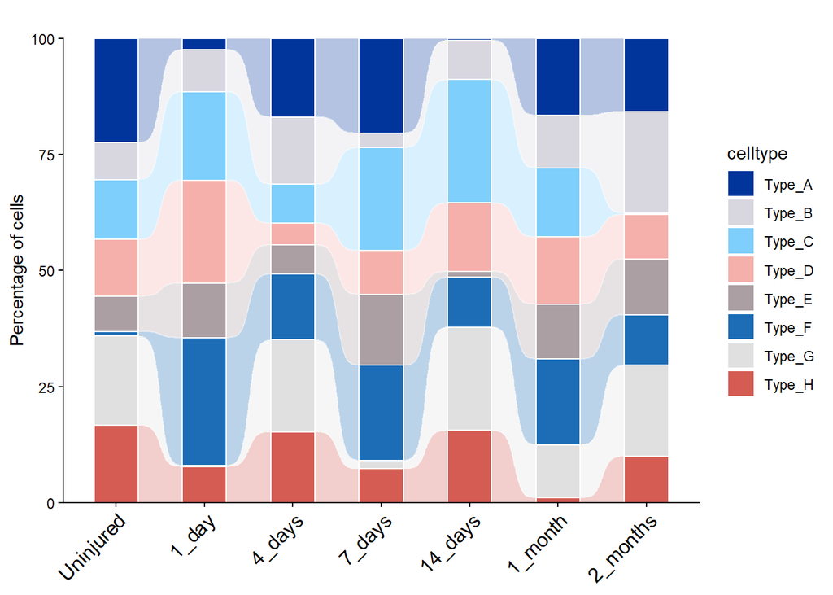

```r
# 加载包
library(magrittr)
library(data.table)
library(ggalluvial)

# 生成模拟数据
days <- c("Uninjured", "1_day", "4_days", "7_days", "14_days", "1_month", "2_months")
celt <- c("Type_A", "Type_B", "Type_C", "Type_D", "Type_E", "Type_F", "Type_G", "Type_H")
data <- expand.grid(day = days, celltype = celt)
data$perc <- runif(nrow(data), min = 0, max = 100)
setDT(data)
data[, perc:=perc/sum(perc)*100, by="day"]

# 变宽为长，下面两个效果相同
# reshape2::melt(data, id.vars = c("day", "celltype"), measure.vars = "perc")
# melt.data.table(data, id.vars = 1:2, measure.vars = "perc", variable.name = "variable", value.name = "value", value.factor = T)
data_long <- data %>%
  melt.data.table(id.vars = 1:2) %>%
  .[,day:=factor(day)]
cus_color <- c("#01359C","#D8D7E0","#7ECFFB","#F5B0AB","#AB9FA3","#1C6DB6","#E0E0E0","#D45C53")

# 绘制桑基堆积柱状图
ggplot(data_long, aes(x=day, y=value, fill=celltype, alluvium=celltype, stratum=celltype)) +
  geom_col(position='stack', width=0.5) +                                                 #柱子
  geom_alluvium(width=0.5, alpha=0.3, color="white",linewidth=0.4, curve_type="sigmoid")+ #冲积
  geom_stratum(width = 0.5, alpha = 0.8,color="white")+                                   #白边
  scale_fill_manual(values=cus_color) +
  scale_y_continuous(expand=c(0,0)) +
  labs(x = NULL, y = "Percentage of cells", title = "") +
  theme_classic() +
  theme(axis.text.x = element_text(angle = 45, hjust = 1, size = 12, color = "black"))
```

## 8.12 和弦图

和弦图(chord Diagram)，是一种显示矩阵中数据间相互关系的可视化方法，节点数据沿圆周径向排列，节点之间使用带权重（有宽度）的弧线链接。其适合节点数据集或边数据集，功能为观察数据节点之间的关系。此类图主要将数据权重映射到节点和边的宽度，适合多组数据进行绘制。和弦图的结构大致如下：

类似极化的桑基图，主要用于展示多个对象之间的关系，连接圆上任意两点的线段叫做弦，弦（两点之间的连线）就代表着两者之间的关联关系。

弦图虽然看起来有点眼花缭乱，但是它却非常适合分析复杂数据的关联关系，特别是双向关系以及数据的流动情况等。

本文参考以下文章：[Chapter 14 The chordDiagram() function](https://jokergoo.github.io/circlize_book/book/the-chorddiagram-function.html)

circlize包支持两种数据格式，邻接矩阵和邻接数据框

```r
# install.packages("circlize")
library(circlize)
library(data.table)

# 邻接矩阵
mat <- c(17, 8,  16, 7,  2, 14,
         18, 13, 6,  10, 1, 11,
         12, 3,  5,  9,  4, 15) %>% matrix(nrow=3, ncol=6)   #矩阵维度3*6
rownames(mat) <- paste0("S", 1:3)   #生成行名
colnames(mat) <- paste0("E", 1:6)   #生成列名

# 邻接数据框
df <- data.frame(from = rep(rownames(mat), times = ncol(mat)), #第1列对象
                 to = rep(colnames(mat), each = nrow(mat)),    #第2列对象
                 value = as.vector(mat),                       #第3列前2列对象相互作用强度
                 stringsAsFactors = FALSE)

# 基础画图功能

# 使用邻接矩阵
# chordDiagram(mat)
# circos.clear()       #结束绘图，否则会继续叠加图层

# 使用邻接数据框
# chordDiagram(df)
# circos.clear()       #结束绘图，否则会继续叠加图层
```

circlize包支持两种数参数调整方式

- 其1，circos.par()
- 其2，chordDiagram()

### 8.12.1 circos.par

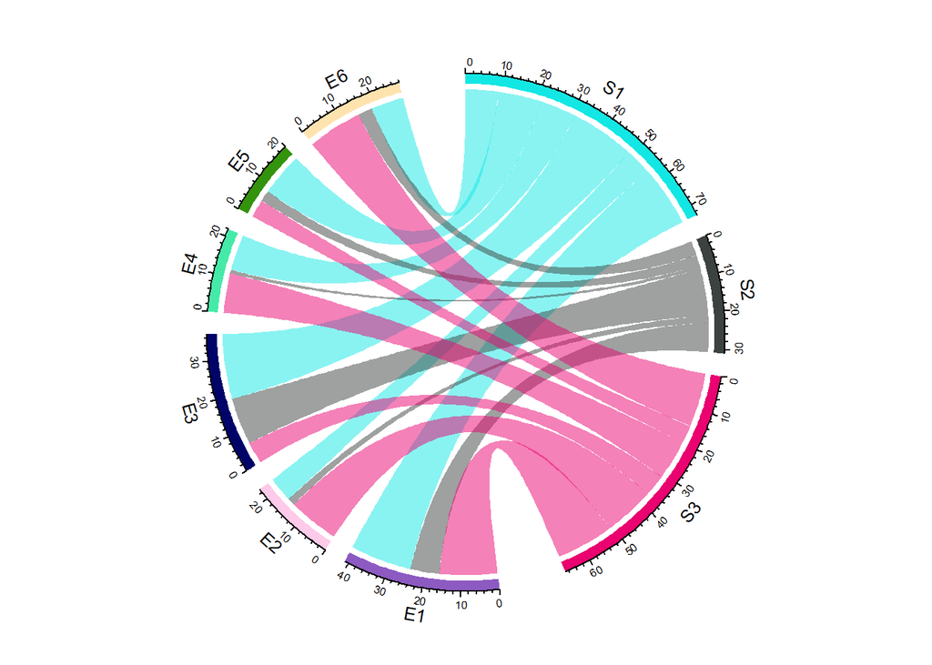

```r
# 加载包
library(circlize)
library(magrittr)
library(data.table)

# 邻接矩阵
mat <- c(17, 8,  16, 7,  2, 14,
         18, 13, 6,  10, 1, 11,
         12, 3,  5,  9,  4, 15) %>% matrix(nrow=3, ncol=6)   #矩阵维度3*6
rownames(mat) <- paste0("S", 1:3)   #生成行名
colnames(mat) <- paste0("E", 1:6)   #生成列名

# 邻接数据框
df <- data.frame(from = rep(rownames(mat), times = ncol(mat)), #第1列对象
                 to = rep(colnames(mat), each = nrow(mat)),    #第2列对象
                 value = as.vector(mat),                       #第3列前2列对象相互作用强度
                 stringsAsFactors = FALSE)

# 设置参数
circos.clear()     #清空全局设置，注意绘图前后都清空一次
circos.par(
  start.degree = 90,                  #从起始点（3点钟方向）逆时针旋转的度数
  # gap.degree = 90,                  #等同gap.after参数
  gap.after = c(rep(5, length(unique(df[[1]]))-1), #表示第1列元素之间的间隙为5个单位
                15,                                #表示第1列与第2列之间的间隙为15个单位
                rep(5, length(unique(df[[2]]))-1), #表示第2列元素之间的间隙为5个单位
                15),                               #表示第2列与第1列之间的间隙为15个单位
  track.margin = c(0.01, 0.01),       #轨道与两侧的距离，此处默认值
  unit.circle.segments = 500,         #设置圆的分段数，影响绘制的平滑度，此处默认值
  cell.padding = c(0.02,1,0.02,1),    #单元格的填充边距，此处默认值
  track.height = 0.2,                 #设置轨道的高度，此处默认值
  points.overflow.warning = F,        #设置是否在数据超出画布范围时发出警告（默认是 TRUE）。
  # circle.margin = c(0,0,0,0),       #填充，与canvas.xlim和canvas.ylim冲突
  canvas.xlim = c(-1,1),              #全图x轴方向的范围，用默认的吧
  canvas.ylim = c(-1,1),              #全图y轴方向的范围，用默认的吧
  major.by.degree = 10,               #设置主要刻度线的间隔角度（默认是 10 度）
  clock.wise = TRUE,                  #是否顺时针
  xaxis.clock.wise = T                #所有cell轴的方向是否为顺时针
)

# 绘图
# circos.clear()     #清空全局设置，注意绘图前后都清空一次，这里绘图后没用，因为rmd中knit后会分割代码块
chordDiagram(df)
```

### 8.12.2 chordDiagram

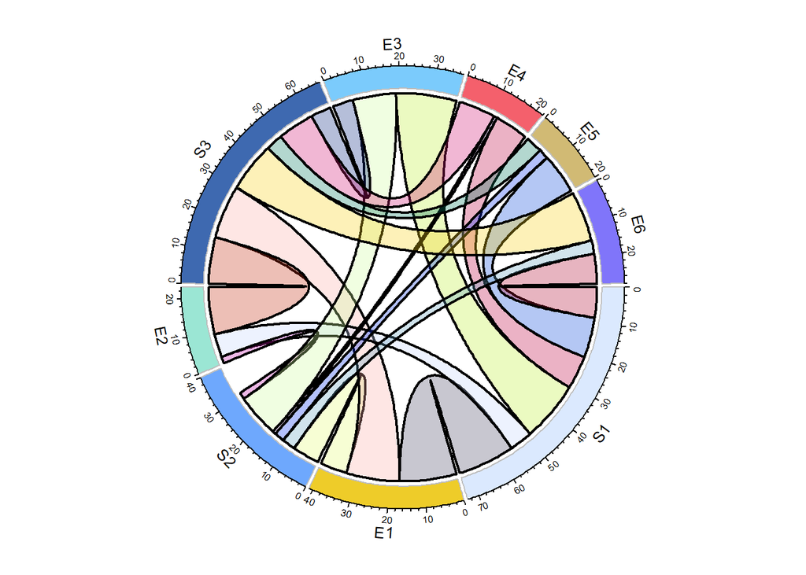

```r
# 加载包
library(circlize)
library(magrittr)
library(data.table)

# 邻接矩阵
mat <- c(17, 8,  16, 7,  2, 14,
         18, 13, 6,  10, 1, 11,
         12, 3,  5,  9,  4, 15) %>% matrix(nrow=3, ncol=6)   #矩阵维度3*6
rownames(mat) <- paste0("S", 1:3)   #生成行名
colnames(mat) <- paste0("E", 1:6)   #生成列名

# 邻接数据框
df <- data.frame(from = rep(rownames(mat), times = ncol(mat)), #第1列对象
                 to = rep(colnames(mat), each = nrow(mat)),    #第2列对象
                 value = as.vector(mat),                       #第3列前2列对象相互作用强度
                 stringsAsFactors = FALSE)

# 使用chordDiagram()设置参数
# 自定义参数
cus_col1 <- c(S1 = "#DBE9FE", S2 = "#6EA8FD", S3 = "#3E69B0", E1 = "#EECC29", E2 = "#9BE6D4",
              E3 = "#7BCBFC", E4 = "#F4606C", E5 = "#D1BA74", E6 = "#8075FA")
cus_col2 <- rand_color(nrow(df), transparency = 0.7)
cus_orde <- c("S1", "E1","S2", "E2", "S3", "E3", "E4", "E5", "E6")
cus_xmax <- c(S1=60, E1=10, S2=40, E2=10, S3=10, E3=10, E4=10, E5=10, E6=10)  #注意这里设置的值如果小于数据，则不起作用如S1，如果大于则在途中留下空白如S2

# 画图
circos.clear()                                #清空全局设置
chordDiagram(
  df,
  # 轨道参数
  xmax = cus_xmax,                            #每个轨道的范围，弧线方向的
  grid.col = cus_col1,                        #轨道填充颜色
  grid.border = "gray",                       #轨道的边框颜色
  order = cus_orde,                           #自定义轨道顺序
  annotationTrack = c("name","grid","axis"),  #要显示的项目，设定为NULL则都不显示
  annotationTrackHeight = mm_h(c(3,5)),       #上面那三个中，前两个的高度，对axis设置没用
  scale = F,                                  #将每个轨道缩放到相同的宽度
  group = NULL,                               #组标签，轨道名称用作向量中的名称。
  big.gap = 10,                               #不同轨道间的最大间隙。
  small.gap = 1,                              #不同轨道间的最小间隙。
  # symmetric = T,                            #是否只画对角线以下部分（不包括对角线），数据为mat时用
  # keep.diagonal = FALSE,                    #如果symmetric = T，是否保持对角线显示，数据为mat时用

  # link参数
  transparency = 0.5,               #link透明度
  col = cus_col2,                   #link的颜色
  # row.col = 1:3,                  #mat数据用，用数字或色值设定源出去的link的颜色
  # column.col = 1:6,               #mat数据用，用数字或色值设定汇进来的link的颜色
  directional = 0,                  #为0,1,或-1，表方向，非0会在起点标记link对应的终点cell颜色
  direction.type = "diffHeight",    #指定link类型，arrows或diffHeight，directional不为0时有arrows效
  diffHeight = mm_h(10),            #指定link终点缩短量，可以为负数，direction.type为diffHeight可用
  # link.target.prop = T,           #如果directional不为0且type为diffHeight，是否在起点画bar
  # target.prop.height = mm_h(3),   #上面这个bar的高度
  reduce = 1e-5,                    #从0到1的数值，link宽度小于弦总宽度百分比的link将不予显示
  self.link = 2,                    #指定自我连接的类型，1为邻接，2间隔连接
  link.border = "black",            #是否有border线以及颜色，可以为NA、单一色值或向量格式
  link.lwd = 2,                     #border线宽，link.border不为NA时起作用
  link.lty = 1,                     #border线类型，link.border不为NA时起作用
  link.auto = TRUE,                 #ignore
  link.sort = "default",            #是否对link排序，可以为逻辑值或者自定义顺序
  link.decreasing = TRUE,           #指定link在sector内的顺序，需要先指定link.sort = TRUE
  link.arr.length = 0.02,           #指定带箭头曲线中，箭头的长度
  link.arr.width = 0.01,            #箭头宽度
  link.arr.type = "triangle",       #箭头类型
  link.arr.lty = 1,                 #箭头线类型
  link.arr.lwd = 1,                 #箭头线宽度
  link.arr.col = NA,                #箭头线颜色
  link.largest.ontop = FALSE,       #控制添加链接的顺序，是否基于绝对值？
  link.visible = TRUE,              #是否绘制链接。
  link.rank = NULL,                 #弃用
  link.zindex = NULL,               #为了向圆圈添加链接，较大的值意味着稍后添加它。
  link.overlap = FALSE,             #如果是一个方向和弦图，在同一扇区的链接是否重叠？

  #其他参数
  preAllocateTracks = list(         #一些列参数，感觉没啥用
    track.height = 0.01,            #当前轨道在整个圆形区域中所占的比例，值越大图反而越小
    track.margin = c(0, 0)          #轨道边距
  )
)
```

## 8.13 韦恩图

文氏图（英语：Venn diagram），或译温氏图、Venn图、范恩图、维恩图、维恩图解、范氏图、韦恩图、卞氏图表等，是在集合论（或者类的理论）数学分支中，在不太严格的意义下用以表示集合（或类）的一种图解。它们用于展示在不同的事物群组（集合）之间的数学或逻辑联系，尤其适合用来表示集合（或）类之间的“大致关系”，它也常常被用来帮助推导（或理解推导过程）关于集合运算（或类运算）的一些规律。

### 8.13.1 ggvenn包

ggvenn包，优点是ggplot2扩展，但缺点是，只支持2~4个集合的韦恩图

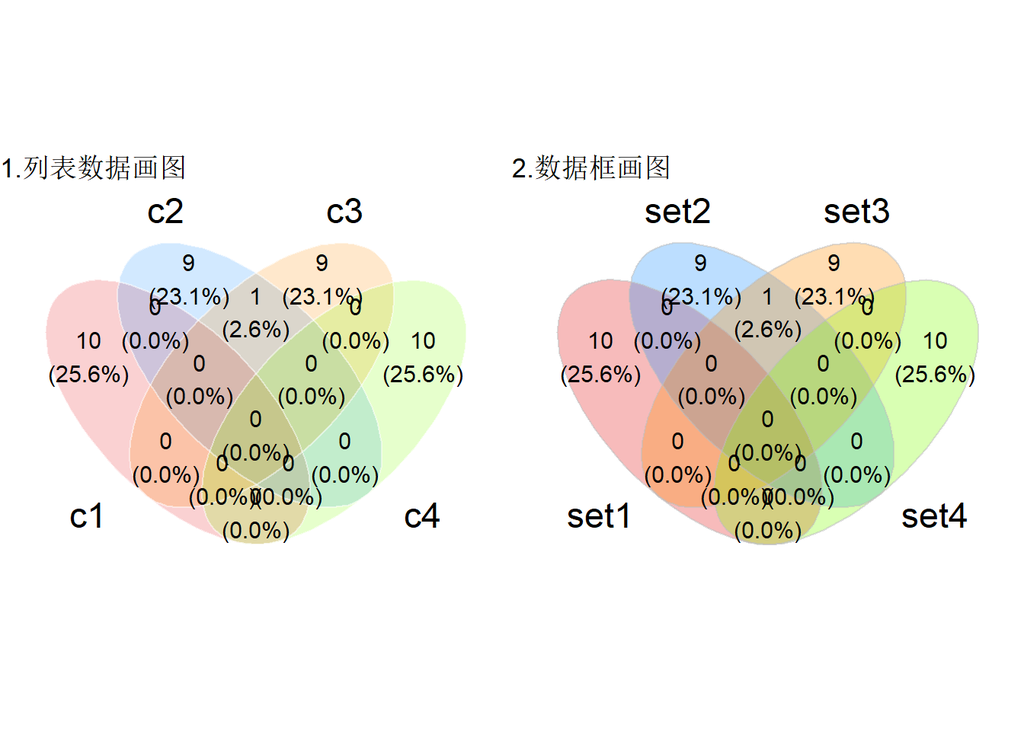

```r
# install.packages("ggvenn")

# 加载R包
library(ggvenn)
library(data.table)

# 支持两种数据格式，
# 其一，列表数据，用每个集合包含的元素构成
data1 <- list(
  c1 = c("gene1193", "gene1194", "gene1195", "gene1197", "gene1199",
         "gene1202", "gene1203", "gene1205", "gene1206", "gene1208"),
  c2 = c("gene1253", "gene1254", "gene1255", "gene1256", "gene1257",
         "gene1259", "gene1260", "gene1261", "gene1263", "gene1267"),
  c3 = c("gene1236", "gene1241", "gene1243", "gene1244", "gene1246",
         "gene1247", "gene1248", "gene1249", "gene1251", "gene1253"),
  c4 = c("gene1325", "gene1327", "gene1328", "gene1329", "gene1330",
         "gene1331", "gene1332", "gene1333", "gene1335", "gene1336")
)

# 其二，数据框数据，用是否包含某个元素构成，注意画图时value不是必须的
gene_all <- unlist(data1) %>% unique()
data2 <- data.table(
  value = gene_all,
  set1 = gene_all %in% data1$c1,
  set2 = gene_all %in% data1$c2,
  set3 = gene_all %in% data1$c3,
  set4 = gene_all %in% data1$c4
)

# 自定义颜色
cus_colo <- c("#E41A1C", "#1E90FF", "#FF8C00", "#80FF00")

# 绘图1
p1 <- ggvenn(
  data = data1,                 #数据列表
  # columns = NULL,             #对选中的列名绘图，最多选择4个，NULL为默认全选（之前没问题，现在报错了）
  show_elements = F,            #当为TRUE时，显示具体的交集情况，而不是交集个数
  label_sep = "\n",             #当show_elements = T时生效，分隔符 \n 表示的是回车的意思
  show_percentage = T,          #显示每一组的百分比
  digits = 1,                   #百分比的小数点位数
  fill_color = cus_colo,        #填充颜色
  fill_alpha = 0.2,             #填充透明度
  stroke_color = "white",       #边缘颜色
  stroke_alpha = 0.5,           #边缘透明度
  stroke_size = 0.5,            #边缘粗细
  stroke_linetype = 1,          #边缘线条
  set_name_color = "black",     #组名颜色
  set_name_size = 6,            #组名大小
  text_color = "black",         #交集个数颜色
  text_size = 4                 #交集个数文字大小
)+
  labs(title="1.列表数据画图")

# 绘图2
p2 <- ggplot(data2,aes(A=set1,B=set2,C=set3,D=set4))+
  geom_venn(
    stat = "identity",
    position = "identity",
    set_names = NULL,
    show_percentage = TRUE,
    digits = 1,
    label_sep = ",",
    count_column = NULL,
    show_outside = "auto",
    auto_scale = FALSE,
    fill_color = cus_colo,
    fill_alpha = 0.3,
    stroke_color = "gray",
    stroke_alpha = 0.5,
    stroke_size = 0.5,
    stroke_linetype = 1,
    set_name_color = "black",
    set_name_size = 6,
    text_color = "black",
    text_size = 4
  )+
  coord_fixed() +
  labs(title = "2.数据框画图")+
  theme_void()

# 注意这里并没有将p视为ggplot2对象，因此需要使用gridExtra拼图
library(gridExtra)
grid.arrange(p1, p2, ncol = 2)
```

### 8.13.2 VennDiagram包

VennDiagram包，可调参数比较多，支持2~5个集合的图

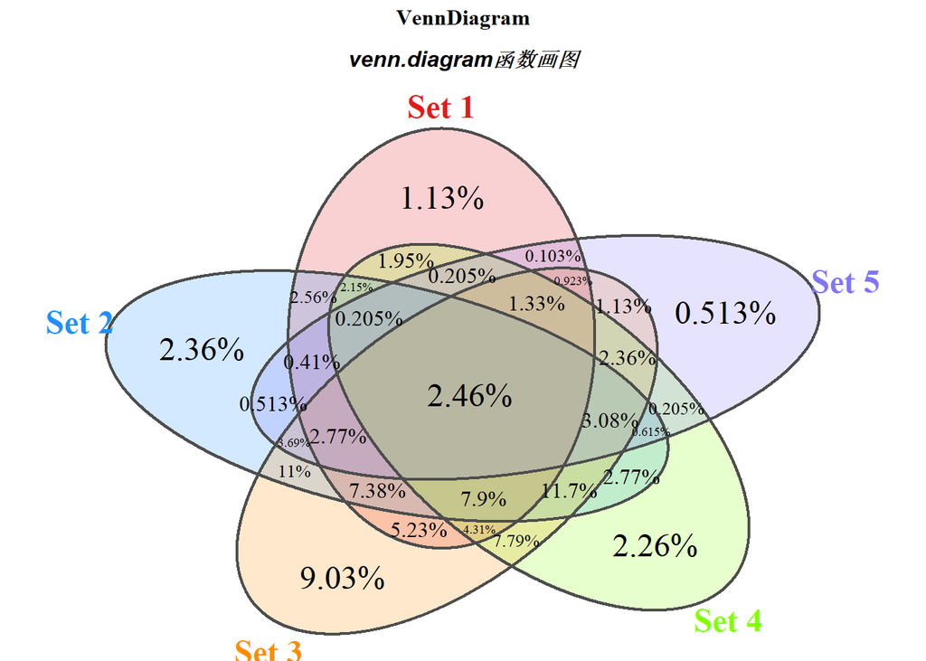

```r
library(VennDiagram)
# 数据
dat <- list(
  a = sample(1:1000, 400, replace = FALSE),
  b = sample(1:1000, 600, replace = FALSE),
  c = sample(1:1000, 800, replace = FALSE),
  d = sample(1:1000, 500, replace = FALSE),
  e = sample(1:1000, 200, replace = FALSE)
)

# 自定义项
cus_name <- c("Set 1", "Set 2", "Set 3", "Set 4", "Set 5")
cus_colo <- c("#E41A1C", "#1E90FF", "#FF8C00", "#80FF00", "#8075FA")
cus_cex  <- c(1.5, 1.5, 1.5, 1.5, 1.5, 1, 0.8, 1, 0.8, 1, 0.8, 1, 0.8,
              1, 0.8, 1, 0.55, 1, 0.55, 1, 0.55, 1, 0.55, 1, 0.55, 1, 1, 1, 1, 1, 1.5)

# 画图
venn.plot <- venn.diagram(
  # 常用参数
  x = dat,
  filename = NULL,              #不保存为文件
  alpha = 0.20,                 #设置透明度
  category.names = cus_name,    #设置集合名称，与数据顺序对应，不支持向量元素名称对应
  fill = cus_colo,              #自定义颜色
  cat.cex = 1.5,                #设置集合名称字体大小
  cex = cus_cex,                #设置数字字体大小
  cat.col = cus_colo,           #设置集合名称字体颜色
  col = "gray30",               #边线颜色
  cat.fontface = "bold",        #标题字体
  disable.logging = FALSE,      #是否输出日志
  na = "stop",                  #对NA数据的处理方式："stop"，"remove"或"convert"（转为F）
  print.mode = "percent",       #显示的数字格式："raw"原始计数，"percent"百分比
  force.unique = TRUE,          #是否强制集合中的元素唯一。如果设置为 TRUE，则会自动去重。
  sigdigs = 3,                  #设置百分比显示的有效数字位数

  # 标题、副标题设置，pos是位置，cex是字大小
  # fontface可以是 "plain", "bold", "italic"或"bold.italic"
  main = "VennDiagram",         #图title
  main.pos = c(0.5, 1.05),
  main.fontface = "bold",
  main.fontfamily = "serif",
  main.col = "black",
  main.cex = 1,
  main.just = c(0.5, 1),
  sub = "venn.diagram函数画图", #图subtitle
  sub.pos = c(0.5, 1.05),
  sub.fontface = "bold.italic",
  sub.fontfamily = "sans",
  sub.col = "black",
  sub.cex = 1,
  sub.just = c(0.5, 1),

  # 文件保存参数
  height = 3000,
  width = 3000,
  units = "px",
  margin = 0.05,                #绘图区域外围边界
  resolution = 500,
  imagetype = "tiff",
  compression = "lzw",          #文件压缩格式（仅适用于TIFF文件）："lzw","none"或"rle"

  # 统计部分
  direct.area = FALSE,       #是否直接使用面积向量绘制维恩图。如果设置为 TRUE，则需要提供 area.vector 参数
  area.vector = 0,           #直接指定每个区域的面积向量。仅在 direct.area = TRUE 时有效
  hyper.test = FALSE,        #是否进行超几何检验（Hypergeometric Test），TRUE会计算集合之间重叠的显著性
  total.population = NULL,   #超几何检验的总人口数。若未指定，则使用所有集合的并集大小
  lower.tail = TRUE,         #超几何检验的尾部类型。若为 TRUE，则计算下尾概率；否则计算上尾概率
);grid.newpage();grid.draw(venn.plot)  #清空上一个图，打印这一个图
```

## 8.14 甘特图

甘特图，反应项目预期和进展情况，本例修改自公众号文章：[超强脑洞第四弹——ggplot构造甘特图](https://mp.weixin.qq.com/s/la_OJ9zQpyD0Rj4g_jE84A)

R语言并不适合做甘特图，原因是数据录入和修改不直观不方便（虽然可以读取外部文件），但这里还是放了一个，是因为这个例子中，涉及以下几个ggplot2画图问题：

1. 图例key的长、宽、大小，当图层是color时，不可调整，只有是fill时才可调
2. 当使用变量画图困难时，可以单独定义图层及颜色，此时给比如颜色一个字符，后续可对不同字符设置不同颜色
3. 由于color的key不可调节大小（如果强行使用，图例的key会大小不一致），为此，画了两个透明的填充图层rect，只用它的图例，不需要它显示，因此将其图层设置为完全透明，然后将其图例强制修改为不透明

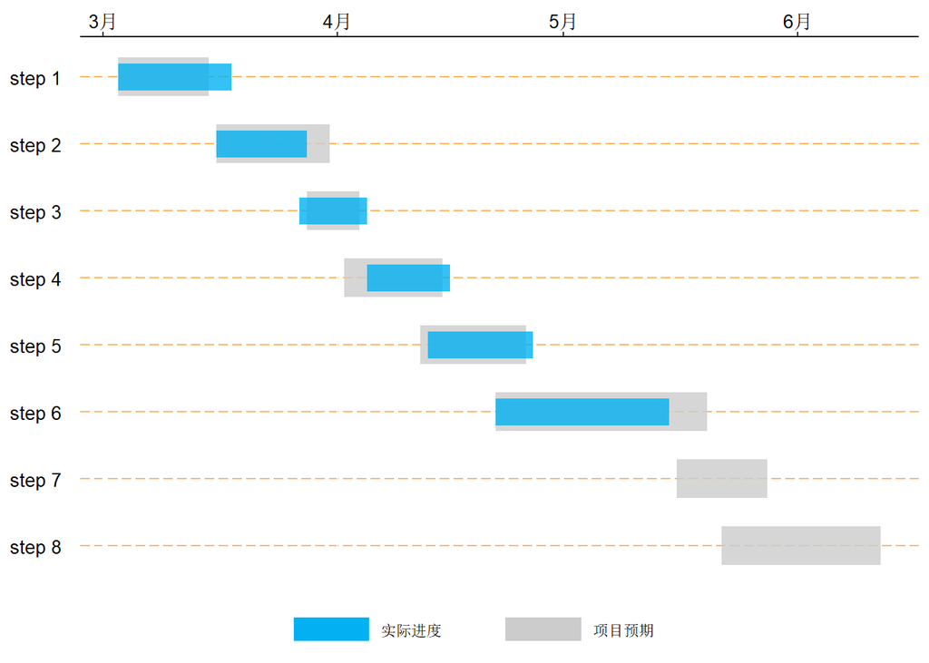

```r
# 加载包
library(ggplot2)
library(data.table)
library(magrittr)

# 构造数据集
dat <- data.table(
  item = paste('step',1:8),
  psdate = c("2016/03/03","2016/03/16","2016/03/28","2016/04/02","2016/04/12",
             "2016/04/22","2016/05/16","2016/05/22") %>% as.Date(),
  pfdate = c("2016/03/15","2016/03/31","2016/04/04","2016/04/15","2016/04/26",
             "2016/05/20","2016/05/28","2016/06/12") %>% as.Date(),
  asdate = c("2016/03/03","2016/03/16","2016/03/27","2016/04/05","2016/04/13",
             "2016/04/22","2016/05/16","2016/05/22") %>% as.Date(),
  afdate = c("2016/03/18","2016/03/28","2016/04/05","2016/04/16","2016/04/27",
             "2016/05/15","2016/05/16","2016/05/22") %>% as.Date()
)
cus_colo2 <- c("plan" = "gray80", "actual" = "#03B1F2" )

# 画图
ggplot(data=dat, aes(x=item))+
  geom_linerange(aes(ymin=psdate,ymax=pfdate,color="plan"),
                 size=10,alpha=0.8)+                          #项目预期图层
  geom_linerange(aes(ymin=asdate,ymax=afdate,color="actual"),
                 size=07,alpha=0.8)+                          #实际完成图层
  geom_rect(aes(xmin=Inf, xmax=Inf, ymin=psdate, ymax = pfdate, fill = "plan"),
            alpha = 0, show.legend = T) +                     #只用它的图例项
  geom_rect(aes(xmin=Inf, xmax=Inf, ymin=psdate, ymax = pfdate, fill = "actual"),
            alpha = 0, show.legend = T) +                     #只用它的图例项
  scale_fill_manual(values = cus_colo2,
                    label = c("实际进度","项目预期"),
                    aesthetics = c("fill", "color"))+         #将fill设置同时给color
  guides(fill = guide_legend(position = "bottom",
                             override.aes = list(alpha=1)),   #强制修改图例为不透明
         color="none")+                                       #不显示color图例
  scale_x_discrete(limits=rev(dat$item))+                     #翻转x轴中的步骤顺序
  scale_y_date(position ="right")+                            #y在右侧，翻转后为上侧
  coord_flip()+
  labs(x=NULL, y=NULL, fill=NULL)+
  theme(
    axis.text.x=element_text(margin=margin(5,0,0,0,"pt")),
    axis.text.y=element_text(margin=margin(0,10,0,0,"pt")),
    axis.ticks.y=element_blank(),
    panel.grid.major.y=element_line(color="#FFB666",linetype=5),
    panel.background=element_rect(fill="white"),
    axis.text=element_text(colour ="black",size=10,face="plain",family="sans"),
    axis.line.x=element_line(),
    panel.spacing=unit(-0.3,"cm"),
    legend.key.width = unit(1.5, "cm"),
    legend.key.height = unit(0.5, "cm"),
    legend.text = element_text(margin = margin(0, 1, 0, 0.2, "cm"))
  )
```

## 8.15 相关系数图

总结了R语言中，相关系数计算和绘图的方法

### 8.15.1 相关系数计算

R语言中相关系数可通过以下几种方法计算，注意由于默认方法不同，计算结果可能有所差异

```r
# 数据
data_row <- iris[1:4]
data_mat <- data_row %>% as.matrix()

# 计算方法1：基础stats包，只计算相关系数，没有显著性p值
data_cor <- cor(data_mat, method = "pearson")

# 计算方法2：Hmisc包，可计算相关系数及显著性p
library(Hmisc)
res <- rcorr(data_mat, type = "pearson")
res_cor   <- res$r
res_cor.p <- res$P

# 计算方法3：psych包，计算相关系数及显著性p值，以及标准差、T检验等参数
library(psych)
tres <-  corr.test(data_mat)
# tres$r
# tres$p

# 计算方法4：基于base包自定义函数，计算相关系数、显著性p、显著性标记
cor.vpsig <- function(x){
  v <- cor(x)
  xncol <- ncol(x)
  xnrow <- nrow(x)
  if(xnrow < 3) p <- NA
  p <- matrix(0, ncol = xncol, nrow = xncol)
  psig <- sig <- matrix(NA_character_, ncol = xncol, nrow = xncol)
  for(i in 1:xncol){
    for(j in 1:xncol){
      p[i,j] <- round(cor.test(x[,i],x[,j])$p.value, 5)
      if(p[i,j] < 0.01){
        sig[i,j] <- "***"
      } else if(p[i,j] < 0.05){
        sig[i,j] <- "**"
      } else if(p[i,j] <0.1){
        sig[i,j] <- "*"
      } else{
        sig[i,j] <- ""
      }
      psig[i,j] <- paste0(round(p[i,j], 2), sig[i,j])
    }
  }
  res <- list(cor = v, cor.p = p, cor.sig = sig, cor.psig = psig)
  return(res)
}
tres <- cor.vpsig(data_mat)
# tres$cor
# tres$cor.p
# tres$cor.sig
# tres$cor.psig

# 计算方法5：ggcorrplot包
library(ggcorrplot)
p.mat <- cor_pmat(mtcars)
```

### 8.15.2 相关系数画图

PerformanceAnalytics包画图，直接使用原始数据，但可调节参数非常少

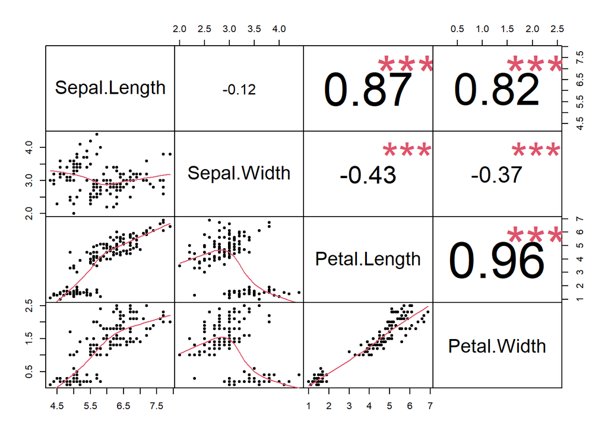

```r
# 加载包
library(PerformanceAnalytics)

# 数据
data_row <- iris[1:4]

# 画图
chart.Correlation(data_row,
                  method = "pearson", #计算方法
                  histogram = F,      #是否包含条形图
                  pch=20)             #点类型
```

corrplot包画图，使用相关系数矩阵画图，可调选项多

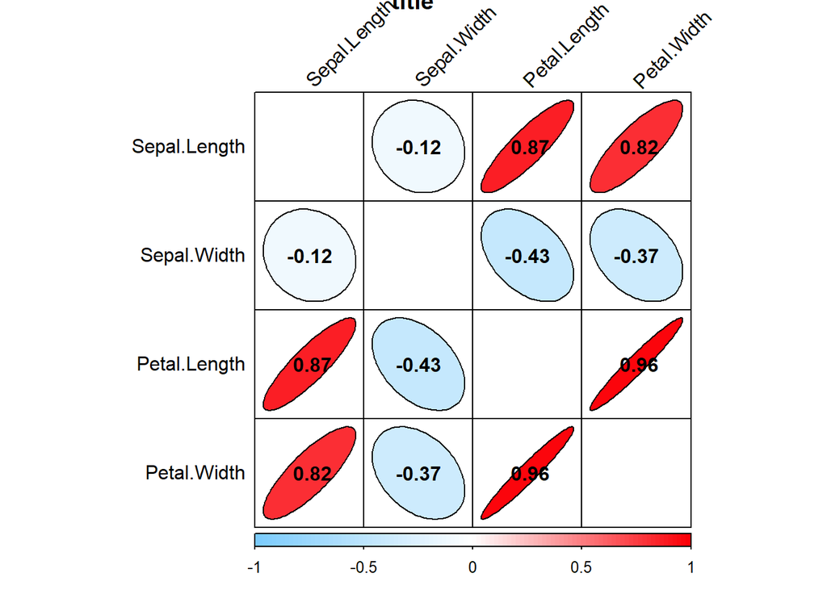

```r
# 加载包
library(corrplot)
library(magrittr)
library(Hmisc)

# 数据
data_row <- iris[1:4]
data_mat <- data_row %>% as.matrix()

# 计算方法1：基础stats包，只计算相关系数，没有显著性p值
data_cor <- cor(data_mat, method = "pearson")

# 计算相关系数和p值
res <- rcorr(data_mat, type = "pearson")
res_cor   <- res$r
res_cor.p <- res$P

# 自定义颜色
cus_colo <- colorRampPalette(c("#7BCBFC", "white", "#fb0007"))(100)  #自定义渐变色

# 画图
corrplot(
  # 常规参数
  data_cor,                   #数据最好是相关系数矩阵
  method = "ellipse",         #图类型c("circle", "square", "ellipse", "number", "shade", "color", "pie")
  type = "full",              #画图区域c("full", "lower", "upper")
  is.corr = T,                #默认T使用相关系数矩阵画图。F使用其他数据画图，不推荐
  diag = F,                   #对角线是饭后画图
  add = F,                    #添加至已有的图，适用于分开画两部分的情况
  col = cus_colo,             #自定义颜色
  col.lim = NULL,             #颜色赋值范围，默认[-1,1]

  # 绘图区域
  title = "title",            #图标题
  mar = c(0, 0, 0, 0),        #图形边距
  bg = "white",               #背景颜色
  outline = T,                #是否画边框以及边框颜色，默认黑色
  addgrid.col = "black",      #边框颜色
  order = "original",         #变量顺序c("original", "AOE", "FPC", "hclust", "alphabet"),
  win.asp = 1,                #图形长宽比
  na.label = "?",             #缺失值的显示标签
  na.label.col = "black",     #缺失值的颜色

  # 变量文本标签
  tl.pos = "lt",              #文本标签位置
  tl.cex = 1,                 #文本标签字体大小
  tl.col = "black",           #文本标签字体颜色
  tl.offset = 0.4,            #文本标签偏移量
  tl.srt = 45,                #上方的文本标签角度

  # 图例
  cl.pos = "b",               #图例位置
  cl.length = 5,              #图例分段数
  cl.cex = 0.8,               #图例字体大小
  cl.ratio = 0.15,            #图例宽度比例
  cl.align.text = "c",        #图例文本对齐方式，c表示居中
  cl.offset = 0.5,            #图例偏移量

  # 图中标记
  number.cex = 1,             #相关系数字体大小
  number.font = 2,            #相关系数字体样式，2表示加粗
  number.digits = NULL,       #相关系数小数位数
  addCoef.col = "black",      #系数文字颜色
  addCoefasPercent = F,       #是否以百分比形式显示相关系数
  addshade = "all",           #是否添加阴影c("negative", "positive", "all"),
  shade.lwd = 1,              #阴影线宽
  shade.col = "blue",         #阴影颜色
  transKeepSign = TRUE,       #是否在颜色映射中保留符号

  # 统计属性性
  p.mat = res_cor.p,          #p值矩阵
  sig.level = 0.05,           #显著性水平
  insig = "n",                #显著性标记c("pch", "p-value", "blank", "n", "label_sig"),
  pch = 4,                    #显著性符号
  pch.col = "black",          #显著性颜色
  pch.cex = 3,                #显著性字号
  # plotCI = "circle",        #置信区间c("n", "square", "circle", "rect"),
  # lowCI.mat = NULL,         #置信区间下限矩阵，置信区间不为n时需提供
  # uppCI.mat = NULL,         #置信区间上限矩阵，置信区间不为n时需提供
  hclust.method = "complete", #聚类类型可选值看help,
  addrect = 1,                #聚类结果中添加矩形框，此处没起作用
  rect.col = "red",           #矩形框的颜色
  rect.lwd = 2,               #矩形框的线宽
)
```

ggcorrplot包画图，可调效果也很多

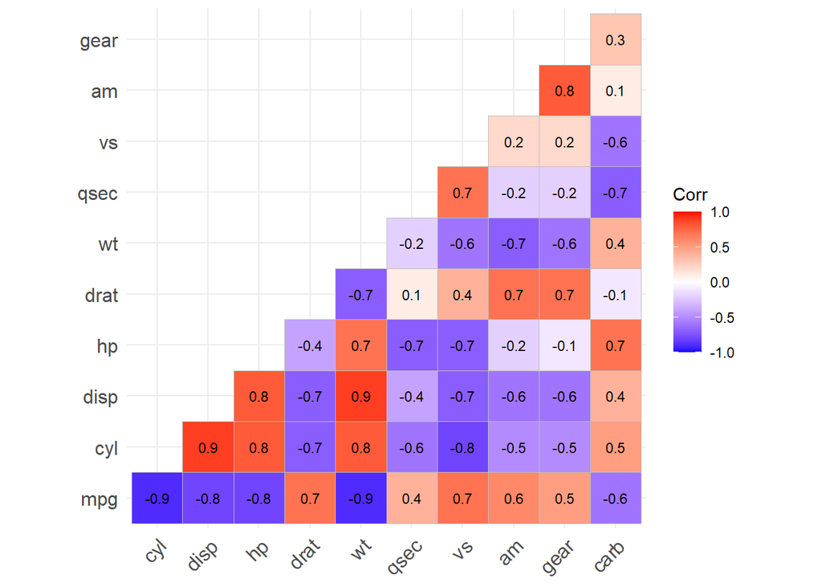

```r
library(ggcorrplot)
ggcorrplot(cor(mtcars),
           type = "lower",
           insig = "blank",
           lab = TRUE,
           digits = 1,lab_size = 3
)
```

自定义ggplot2画图

注意:

- 这里为节省空间两个图画在一起，因此布局有些奇怪，尤其是`barheight=10`较小，正常用需修改一下
- 这里p1中，当x轴标签设置为45度时，对齐方式的调节比较迷幻，实际应用中，建议尝试性调节

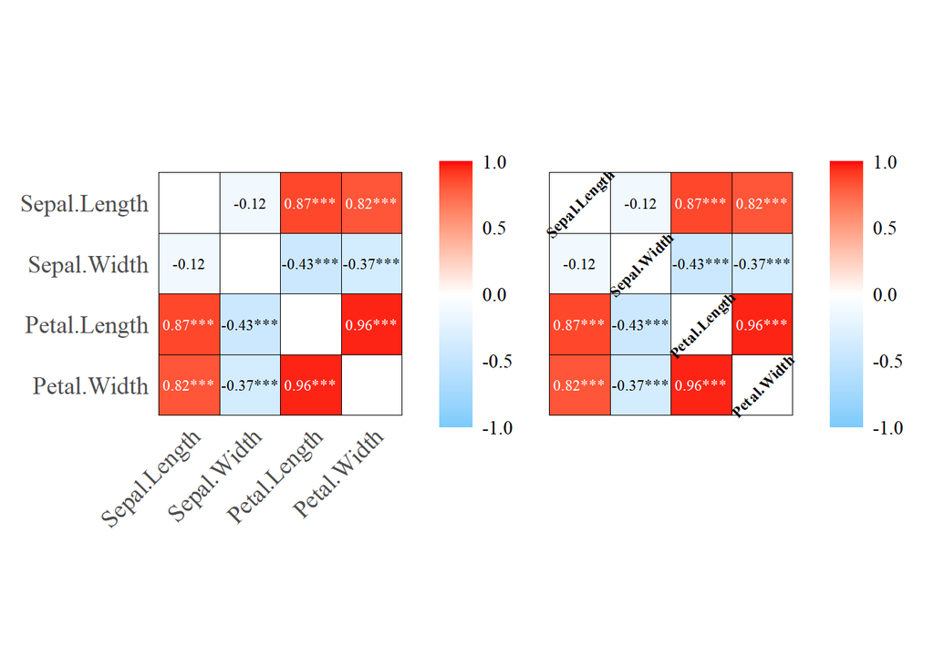

```r
# 加载包
library(ggplot2)
library(data.table)
library(magrittr)
library(Hmisc)
library(patchwork)  #拼图

# 数据
data_row <- iris[1:4]
data_mat <- data_row %>% as.matrix()

# 计算相关系数和p值
res_cor <- rcorr(data_mat, type = "pearson")
res_cor.v <- res_cor$r
res_cor.p <- res_cor$P

# 设置参数
dat_var <- names(data_row)
cor_color <- c("#7BCBFC", "white", "#fb0007")
tex_color <- function(x) if(x > 0.53|x < -0.46) return("w") else return("b") #定义数颜色与背景区别

# 整理cor
data_r <- data.table(res_cor.v) %>%
  .[,v1:=dat_var] %>%
  melt(id="v1", variable.name="v2", value.name = "cor") %>%
  .[, c("v1", "v2") := list(factor(v1, levels = dat_var), factor(v2, levels = rev(dat_var)))] %>%
  .[, cor:=round(cor, 2)] %>%
  .[, text.col := tex_color(cor), by = c("v1","v2")]
# 整理cor的pvalue
data_p <- data.table(res_cor.p) %>%
  .[,v1:=dat_var] %>%
  melt(id="v1", variable.name="v2", value.name = "p") %>%
  .[, c("v1", "v2") := list(factor(v1, levels = dat_var), factor(v2, levels = rev(dat_var)))] %>%
  .[, sig:=ifelse(is.na(p), "***", ifelse(p<=0.01,"***", ifelse(p<=0.05, "** ", ifelse(p<=0.1,"*  ", ""))))]
# 合并cor和pvalue
data_rp <- data_r[data_p, on = c("v1", "v2")] %>%
  .[, rp := sprintf("%.2f%s", cor, sig)] %>%
  .[v1 == v2, c("rp", "cor"):=list("", 0)]

# 画图1，标签放在xy轴，弃用
p1 <- ggplot(data_rp, aes(v1, v2, fill = cor, label = rp))+
  geom_tile(color = "black")+
  geom_text(mapping = aes(color = text.col), show.legend = F, size = 3, family = "serif")+
  scale_fill_gradientn(colours = cor_color, limits = c(-1,1))+    #用limit控制bar显示值
  scale_color_manual(values = c("b" = "black", "w" = "white"))+
  guides(fill = guide_colorbar(title = NULL, barheight = 10, barwidth = 1.25, ticks.colour=NA))+
  scale_y_discrete(labels = rev(dat_var))+
  scale_x_discrete(labels = dat_var)+
  labs(x = NULL, y = NULL, title = "", fill = NULL)+
  theme_bw()+
  theme(aspect.ratio = 1,
        axis.ticks = element_blank(),
        axis.text.x = element_text(angle = 45, vjust = 1, hjust = 1),
        axis.text = element_text(size = 13),
        panel.grid = element_blank(),
        panel.border = element_blank(),
        legend.text = element_text(size = 11),
        plot.title = element_text(hjust = 0.5),
        text = element_text(family = "serif"))

# 画图2，标签在对角线
p2 <- ggplot(data_rp, aes(v1, v2, fill = cor, label = rp))+
  geom_tile(color = "black")+
  geom_text(aes(color = text.col), show.legend = F, size = 3, family = "serif")+
  geom_text(data=data_rp[v1==v2,], mapping = aes(x = v1, y=v2), label=dat_var, color = "black", size = 3,fontface="bold", family = "serif", angle=45)+
  scale_fill_gradientn(colours = cor_color, limits = c(-1,1))+    #用limit控制bar显示值
  scale_color_manual(values = c("b" = "black", "w" = "white"))+
  guides(fill = guide_colorbar(title = NULL, barheight = 10, barwidth = 1.25, ticks.colour=NA))+
  labs(x = NULL, y = NULL, title = "", fill = NULL)+
  theme_bw()+
  theme(aspect.ratio = 1,
        axis.ticks = element_blank(),
        axis.text = element_blank(),
        panel.grid = element_blank(),
        panel.border = element_blank(),
        legend.text = element_text(size = 11),
        plot.title = element_text(hjust = 0.5),
        text = element_text(family = "serif"))

# 拼图
p1+p2
```

## 8.16 热图

热图用颜色块表示数值大小，直观展示数值的差异。与相关系数图有些类似，当然也可以用热图的方式展示相关系数矩阵。

下面例子来自知乎，绘制了一个环形的热图，因为类似数据的一般热图会显得长宽比过于悬殊。

作者：心有灵犀 链接：https://zhuanlan.zhihu.com/p/1920413427626673434 代码来源：https://www.r2omics.cn/

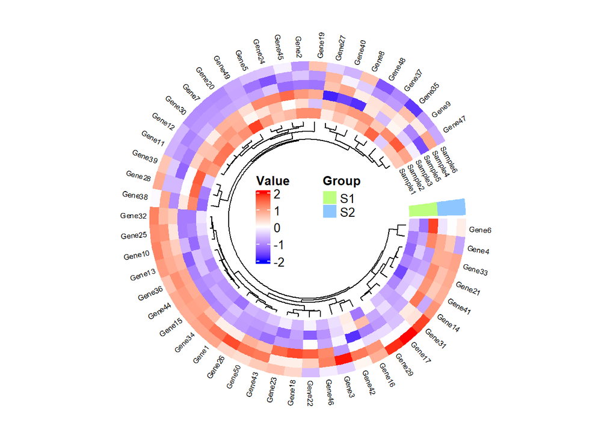

```r
# 加载包
# library(devtools)
# install_github("jokergoo/ComplexHeatmap")
library(circlize)
library(ComplexHeatmap)
library(magrittr)

# 重置 circos 状态
circos.clear()

# 定义函数
cheatmap = function(
    df = NULL,                        #主数据框（矩阵形式，行为特征，列为样本）
    dfSample = NULL,                  #(可选)样本分组信息（两列数据框：Sample列和Group列）
    group_colors = NULL,              #自定义分组颜色向量（命名向量）
    scale = "row",                    #数据标准化方式：none（不处理）/row（行标准化）/column（列标准化）
    col_fun = NULL,                   #自定义颜色映射函数（由colorRamp2创建）
    # 聚类控制参数
    cluster_rows = TRUE,              #是否对行聚类
    cluster_cols = TRUE,              #是否对列聚类
    clustering.method  = "complete",  #聚类方法（hclust方法）
    distance.method  = "euclidean",   #距离计算方法
    # 可视化参数
    dend.track.height  = 0.1,         #树状图轨道高度
    show_rownames = TRUE,             #显示行名
    show_colnames = TRUE,             #显示列名
    legend_font_size = 10,
    legend_value_name = "",
    legend_group_name = "Group",
    font_size = 0.5,                  #标签字体大小
    track.height  = 0.3,              #热图轨道高度
    start.degree  = 0,                #环形起始角度
    gap.degree  = 30                  #扇区间隔角度
){
  # 归一化
  if(scale=="row"){
    # 按行归一化
    dfNormalize = t(scale(t(df))) %>% as.data.frame()
  }else if(scale=="column"){
    # (或)按列归一化
    dfNormalize = scale(df) %>% as.data.frame()
  }else if(scale=="none"){
    dfNormalize = df
  }else{
    stop("scale参数不正确，选择none row column中的一种")
  }
  # 设置颜色
  if(is.null(col_fun)){
    col_fun = colorRamp2(c(floor(min(dfNormalize,na.rm=T) ),
                           0,
                           ceiling(max(dfNormalize,na.rm=T))),
                         c("#0000ff", "#ffffff", "#ff0000"))
  }
  circos.par(start.degree  = start.degree, gap.degree  = gap.degree)
  if(cluster_cols){
    column_od <- hclust(dist(t(dfNormalize),method = distance.method),method = clustering.method)$order
    dfPlot = dfNormalize[,  column_od]
  }else{
    dfPlot = dfNormalize
  }
  if(cluster_rows){
    dend.side = "inside"
  }else{
    dend.side = "none"
  }
  if(show_rownames){
    rownames.side = "outside"
    my.track.index = 2
  }else{
    rownames.side = "none"
    my.track.index = 1
  }
  circos.heatmap(dfPlot,
                 track.height  = track.height,
                 cluster = cluster_rows,
                 clustering.method  = clustering.method,
                 distance.method  = distance.method,
                 rownames.side  = rownames.side, # c("none", "outside", "inside"),
                 rownames.cex  = font_size,
                 rownames.font  = par("font"),
                 rownames.col  = "black",
                 dend.callback  = function(dend, m, si) reorder(dend, rowMeans(m)),
                 # dend.callback  = function(dend, m, si) {{dendsort::dendsort(dend)}},
                 dend.side  = dend.side,
                 dend.track.height  = dend.track.height,
                 col = col_fun
  )
  if(is.null(dfSample)){
  }else{
    # 获取样本分组信息
    colnames(dfSample) = c("Sample", "Group")

    sample_groups <- dfSample$Group[match(colnames(dfPlot), dfSample$Sample)]
    unique_groups <- unique(sample_groups)
    if(is.null(group_colors)){
      group_colors <- setNames(c("#bfff7f", "#8ec7ff", "#ffc57f", "#f18c8d","#ea4436","#000000"), unique_groups)
    }
    # 为每个样本添加条带
    circos.track(
      track.index  = my.track.index,
      panel.fun  = function(x, y) {
        if(CELL_META$sector.numeric.index  == 1) {
          cn = colnames(dfNormalize[, column_od])
          n = length(cn)
          for(i in 1:n) {
            group <- sample_groups[i]
            color <- group_colors[group]
            circos.rect(
              0 - convert_x(1, "mm"), i - 1,
              0 - convert_x(5, "mm"), i,
              col = color, border = NA
            )
          }
        }
      },
      bg.border  = NA
    )
  }
  if(show_colnames){
    circos.track(
      track.index =my.track.index,
      panel.fun = function(x, y) {
        if (CELL_META$sector.numeric.index == 1) {
          # 在最后一个扇形中
          cn = colnames(dfNormalize[, column_od])
          n = length(cn)
          circos.text(
            rep(CELL_META$cell.xlim[2], n)  + convert_x(1, "mm"),
            1:n -0.5,
            cn,
            cex = font_size,
            adj = c(0, 0.5),
            facing = "inside"
          )
        }
      },
      bg.border = NA
    )
  }
  circos.clear()
  lgd_heatmap <- Legend(title = legend_value_name, col_fun = col_fun,
                        labels_gp = gpar(fontsize = legend_font_size),
                        title_gp = gpar(fontsize = legend_font_size, fontface = "bold")#,
                        # grid_height = unit(10, "mm"),
                        # grid_width = unit(2, "mm"),
                        # legend_height  = unit(10, "mm"),
                        # legend_width  = unit(3, "mm")
  )
  # 创建图例对象
  if(is.null(dfSample)){
    pd <- packLegend( lgd_heatmap,
                      direction = "horizontal", gap = unit(0, "cm"))
  }else{

    lgd_groups <- Legend(labels = names(group_colors), title = legend_group_name,
                         legend_gp = gpar(fill = group_colors),
                         labels_gp = gpar(fontsize = legend_font_size),
                         title_gp = gpar(fontsize = legend_font_size, fontface = "bold")#,
                         # grid_height = unit(10, "mm"),
                         # grid_width = unit(2, "mm"),
                         # legend_height  = unit(10, "mm"),
                         # legend_width  = unit(3, "mm")
    )
    # 组合图例并设置间距
    pd <- packLegend( lgd_heatmap, lgd_groups,
                      direction = "horizontal", gap = unit(1, "cm"))
  }
  # 统一绘制
  draw(pd, x = unit(0.5, "npc"), y = unit(0.5, "npc"))
}

# 读取数据
# df = read.delim("https://www.r2omics.cn/res/demodata/heatmap/data.heatmap.txt",  row.names  = 1)
# 样本分组(可选)
# dfSample = read.delim("https://www.bioladder.cn/shiny/zyp/demoData/heatmap/sample.class.txt")
df <- data.frame(
  Sample1=c(1.2768,0.0195,2.3951,0.0832,0.0274,0.0154,0.0272,0.5025,0.8548,2.3662,
            2.1551,0.1293,0.6058,2.281,1.0987,3.7686,0.2032,2.1521,0.5164,2.2806,
            6.8259,0.4441,6.4253,7.9816,6.0002,3.1069,0.9746,0.0902,1.5059,0.4182,
            12.0942,14.7558,8.5677,28.1433,10.2726,1.2304,2.1053,79.214,8.1325,0.7535,
            0.3255,0.7972,0.5743,14.1853,0.2654,10.9067,5.6652,2.1092,0.005,0.5784),
  Sample2=c(1.3997,0.0271,3.0794,0.1432,0.0102,0.0145,0.062,0.4246,1.0108,2.1345,
            1.988,0.0919,0.5885,1.7256,1.1256,3.8345,0.0522,1.8564,0.3159,2.3604,
            6.6891,0.5257,5.8482,5.0916,5.9685,4.3993,1.1036,0.0452,1.2155,0.4869,
            6.1113,14.3567,8.457,29.0481,14.5171,1.3352,2.1288,81.1838,7.4929,0.8385,
            0.3002,1.0957,0.6831,14.5102,0.1713,11.4065,5.9449,2.1793,0.0044,0.8862),
  Sample3=c(1.0724,0.0147,2.256,0.1569,0.0206,0.0135,0.0839,0.4703,0.8316,1.9564,
            1.7889,0.1043,0.5744,2.3677,1.1143,3.4877,0.0143,3.8137,0.2767,2.5897,
            7.0005,0.6035,7.4717,8.1147,5.5847,2.8801,1.0882,0.0454,1.1649,0.6964,
            5.846,14.2208,8.462,27.1884,13.6706,1.2816,2.2902,77.1982,6.9707,1.001,
            0.3501,0.7632,0.5916,14.1201,0.1095,11.3792,5.5306,2.3483,0.0061,0.7133),
  Sample4=c(0.8805,0.0442,2.4159,0.0833,0.05,0.0089,0.7527,0.5337,1.208,0.9626,3.617,
            0.2439,0.4326,1.7884,0.7215,3.7315,0.0323,0.6401,0.3663,4.4251,5.7838,
            0.3828,4.0178,11.5281,4.963,1.8369,1.0905,0.109,1.0949,2.0291,1.7058,
            13.0411,6.8934,21.5451,15.392,0.9756,2.3133,81.8238,8.7311,0.9976,0.2002,
            0.8036,0.3881,10.2485,0.2815,10.6311,5.9488,2.4542,0.0254,0.2221),
  Sample5=c(0.8286,0.0574,2.4866,0.1725,0.0732,0.0228,0.6673,0.3255,0.9226,1.312,
            3.0659,0.2402,0.3382,1.9098,0.627,3.2953,0.012,0.5433,0.546,4.3904,5.8688,
            0.4886,4.563,13.1938,4.9122,1.8195,0.8049,0.0633,1.0744,1.4091,2.0302,
            13.0424,6.3224,20.2576,13.4989,0.8552,2.1648,79.8389,7.7449,0.6,0.2101,
            0.3508,0.3265,9.9854,0.4823,10.6921,5.766,2.3427,0.0316,0.186),
  Sample6=c(0.6947,0.0594,2.4357,0.0685,0.069,0.0121,0.6921,0.4817,1.0605,1.3228,
            3.5164,0.306,0.4197,1.6314,0.6692,3.2791,0.014,0.8602,0.5846,4.8144,
            5.6873,0.478,5.3983,11.269,5.284,2.0417,1.0418,0.0303,1.2198,2.4174,
            1.8729,13.6765,5.8298,20.5308,12.536,0.8631,2.435,76.5527,7.5325,0.9538,
            0.096,0.8198,0.4338,10.4254,0.3829,10.7372,5.8897,2.4132,0.0658,0.2724))
rownames(df) <- c("Gene1","Gene2","Gene3","Gene4","Gene5","Gene6","Gene7","Gene8",
                  "Gene9","Gene10","Gene11","Gene12","Gene13","Gene14","Gene15",
                  "Gene16","Gene17","Gene18","Gene19","Gene20","Gene21","Gene22",
                  "Gene23","Gene24","Gene25","Gene26","Gene27","Gene28","Gene29",
                  "Gene30","Gene31","Gene32","Gene33","Gene34","Gene35","Gene36",
                  "Gene37","Gene38","Gene39","Gene40","Gene41","Gene42","Gene43",
                  "Gene44","Gene45","Gene46","Gene47","Gene48","Gene49","Gene50")
dfSample <- data.frame(X=c('Sample1','Sample2','Sample3','Sample4','Sample5','Sample6'),
                       Group=c('S1','S1','S1','S2','S2','S2'))

# 绘图
cheatmap(
  df = df,                         #主数据框（矩阵形式，行为特征，列为样本）
  dfSample = dfSample,             #(可选)样本分组信息（两列数据框：Sample列和Group列）
  group_colors = NULL,             #自定义分组颜色向量
  scale = "row",                   #数据标准化方式：none（不处理）/row（行标准化）/column（列标准化）
  col_fun = NULL,                  #自定义颜色映射函数（由colorRamp2创建）
  cluster_rows = T,                #是否对行聚类
  cluster_cols = TRUE,             #是否对列聚类
  clustering.method  = "complete", #聚类方法（hclust方法）
  distance.method  = "euclidean",  #距离计算方法
  dend.track.height = 0.1,         #树状图轨道高度
  show_rownames = T,               #显示行名
  show_colnames = TRUE,            #显示列名
  font_size = 0.5,                 #标签字体大小
  legend_font_size = 10,           #图例字体大小
  legend_value_name = "Value",     #图例标题
  legend_group_name = "Group",     #分组图例标题
  track.height = 0.3,              #热图轨道高度
  start.degree  = 0,               #环形起始角度
  gap.degree  = 30                 #扇区间隔角度
)
```

## 8.17 棋盘图

代码修改自《现代图形统计（第二版）》：https://bookdown.org/xiangyun/msg2nd/visualization-intermediate.html

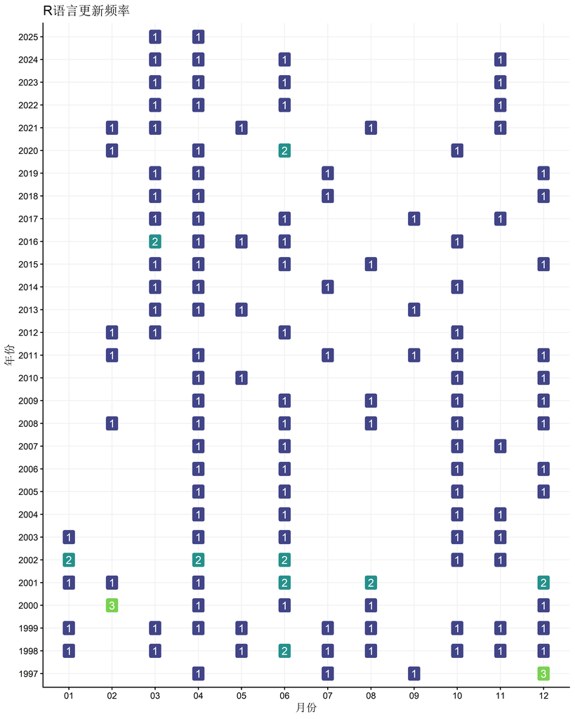

```r
# 加载包
library(ggplot2)
library(data.table)

# 数据
rversion <- data.table(version=c('0.49','0.50-a1','0.50-a4','0.60.0','0.60.1','0.61.0',
                                 '0.61.1','0.61.2','0.61.3','0.62.0','0.62.1','0.62.2',
                                 '0.62.3','0.62.4','0.63.0','0.63.1','0.63.2','0.63.3',
                                 '0.64.0','0.64.1','0.64.2','0.65.0','0.65.1','0.90.0',
                                 '0.90.1','0.99.0','0.99.0a','1.0.0','1.0.1','1.1.0',
                                 '1.1.1','1.2.0','1.2.1','1.2.2','1.2.3','1.3.0',
                                 '1.3.0-recommended','1.3.1','1.3.1-recommended','1.4.0',
                                 '1.4.0-recommended','1.4.1','1.4.1-recommended','1.5.0',
                                 '1.5.0-recommended','1.5.1','1.5.1-recommended','1.6.0',
                                 '1.6.1','1.6.2','1.7.0','1.7.1','1.8.0','1.8.1','1.9.0',
                                 '1.9.1','2.0.0','2.0.1','2.1.0','2.1.1','2.2.0','2.2.1',
                                 '2.3.0','2.3.1','2.4.0','2.4.1','2.5.0','2.5.1','2.6.0',
                                 '2.6.1','2.6.2','2.7.0','2.7.1','2.7.2','2.8.0','2.8.1',
                                 '2.9.0','2.9.1','2.9.2','2.10.0','2.10.1','2.11.0',
                                 '2.11.1','2.12.0','2.12.1','2.12.2','2.13.0','2.13.1',
                                 '2.13.2','2.14.0','2.14.1','2.14.2','2.15.0','2.15.1',
                                 '2.15.2','2.15.3','3.0.0','3.0.1','3.0.2','3.0.3',
                                 '3.1.0','3.1.1','3.1.2','3.1.3','3.2.0','3.2.1','3.2.2',
                                 '3.2.3','3.2.4','3.2.4-revised','3.2.5','3.3.0','3.3.1',
                                 '3.3.2','3.3.3','3.4.0','3.4.1','3.4.2','3.4.3','3.4.4',
                                 '3.5.0','3.5.1','3.5.2','3.5.3','3.6.0','3.6.1','3.6.2',
                                 '3.6.3','4.0.0','4.0.1','4.0.2','4.0.3','4.0.4','4.0.5',
                                 '4.1.0','4.1.1','4.1.2','4.1.3','4.2.0','4.2.1','4.2.2',
                                 '4.2.3','4.3.0','4.3.1','4.3.2','4.3.3','4.4.0','4.4.1',
                                 '4.4.2','4.4.3','4.5.0'),
                       date=c('1997-04-23','1997-07-22','1997-09-10','1997-12-04','1997-12-07',
                              '1997-12-22','1998-01-13','1998-03-18','1998-05-03','1998-06-15',
                              '1998-06-15','1998-07-10','1998-08-28','1998-10-24','1998-11-14',
                              '1998-12-05','1999-01-12','1999-03-06','1999-04-08','1999-05-08',
                              '1999-07-05','1999-08-28','1999-10-07','1999-11-22','1999-12-15',
                              '2000-02-07','2000-02-09','2000-02-29','2000-04-14','2000-06-15',
                              '2000-08-15','2000-12-15','2001-01-15','2001-02-26','2001-04-26',
                              '2001-06-22','2001-06-22','2001-08-31','2001-08-31','2001-12-19',
                              '2001-12-19','2002-01-30','2002-01-30','2002-04-29','2002-04-29',
                              '2002-06-17','2002-06-17','2002-10-01','2002-11-01','2003-01-10',
                              '2003-04-16','2003-06-16','2003-10-08','2003-11-21','2004-04-12',
                              '2004-06-21','2004-10-04','2004-11-15','2005-04-19','2005-06-20',
                              '2005-10-06','2005-12-20','2006-04-24','2006-06-01','2006-10-03',
                              '2006-12-18','2007-04-24','2007-06-28','2007-10-03','2007-11-26',
                              '2008-02-08','2008-04-22','2008-06-23','2008-08-25','2008-10-20',
                              '2008-12-22','2009-04-17','2009-06-26','2009-08-24','2009-10-26',
                              '2009-12-14','2010-04-22','2010-05-31','2010-10-15','2010-12-16',
                              '2011-02-25','2011-04-13','2011-07-08','2011-09-30','2011-10-31',
                              '2011-12-22','2012-02-29','2012-03-30','2012-06-22','2012-10-26',
                              '2013-03-01','2013-04-03','2013-05-16','2013-09-25','2014-03-06',
                              '2014-04-10','2014-07-10','2014-10-31','2015-03-09','2015-04-16',
                              '2015-06-18','2015-08-14','2015-12-10','2016-03-16','2016-03-10',
                              '2016-04-14','2016-05-03','2016-06-21','2016-10-31','2017-03-06',
                              '2017-04-21','2017-06-30','2017-09-28','2017-11-30','2018-03-15',
                              '2018-04-23','2018-07-02','2018-12-20','2019-03-11','2019-04-26',
                              '2019-07-05','2019-12-12','2020-02-29','2020-04-24','2020-06-06',
                              '2020-06-22','2020-10-10','2021-02-15','2021-03-31','2021-05-18',
                              '2021-08-10','2021-11-01','2022-03-10','2022-04-22','2022-06-23',
                              '2022-11-01','2023-03-16','2023-04-22','2023-06-16','2023-11-01',
                              '2024-03-01','2024-04-25','2024-06-15','2024-11-01','2025-03-01',
                              '2025-04-11'))

# 两种方法比较
# library("microbenchmark")
# microbenchmark({
#   a <- within(rversion,{
#     date <- as.Date(date, format = "%Y-%m-%d", tz = "UTC")
#     year <- format(date, "%Y")
#     month <- format(date, "%m")
#   })
# },
# {
#   rversion[, date:=as.Date(date, format = "%Y-%m-%d", tz = "UTC")]
#   rversion[, c("year", "month"):=list(format(date, "%Y"), format(date, "%m"))]
# })

# 上面结果显示，数据量小时，base方法更快，而且within中是分步的，在data.table中要分两步，否则报错
# 这里还是用data.table了，因为后面还有分组融合计算
rversion[, date:=as.Date(date, format = "%Y-%m-%d", tz = "UTC")]
rversion[, c("year", "month"):=list(format(date, "%Y"), format(date, "%m"))]
rversion[, vertime:=length(version), by=c("year","month")]

# 画图
# fill语句的含义为：
#   option指定viridis色系的变体，可选"A"（magma）、"B"（inferno）、"C"（plasma）、"D"（viridis，默认）、"E"（cividis）
#   begin = 0.2, end = 0.8指定渐变起点位置（取值范围 0~1），0.2 表示跳过最深的 20% 的暗色，0.8 表示跳过最浅的 20% 的亮色
#   压缩颜色范围，避免极端深/浅色，使中间色调更突出。
ggplot(rversion, aes(x = month, y = year)) +
  geom_label(aes(label = vertime, fill = vertime), show.legend = F, color = "white") +
  scale_fill_viridis_c(option = "D", begin = 0.2, end = 0.8) +
  labs(x = "月份", y = "年份", title = "R语言更新频率")+
  theme_classic() +
  theme(panel.grid.major = element_line(colour = "gray95"))
```

## 8.18 时间线图

代码修改自《现代图形统计（第二版）》：https://bookdown.org/xiangyun/msg2nd/visualization-intermediate.html

横向这个代码有一个隐藏bug，因为如果筛选到部分年份，有可能会一天发布多个R版本，此时后面的标签后覆盖前面的。纵向的由于筛选了重大和主要版本，因此没有重复。

横向图

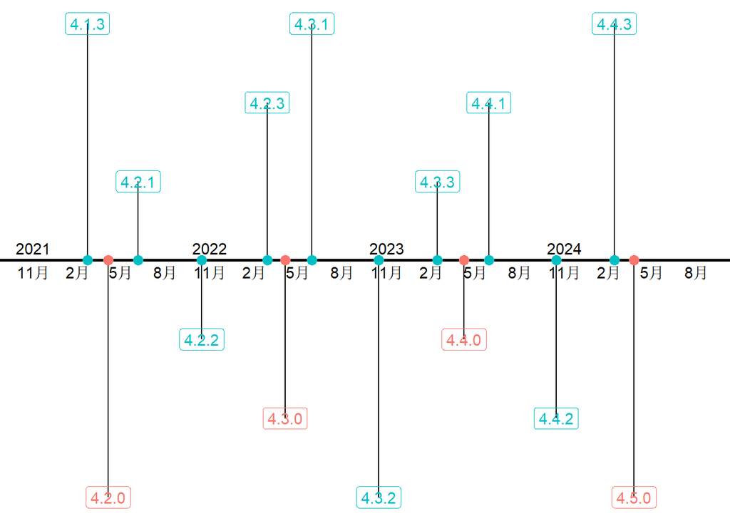

```r
# 加载包
library(ggplot2)
library(data.table)
library(magrittr)

# 数据
rversion <- data.table(version=c('0.49','0.50-a1','0.50-a4','0.60.0','0.60.1','0.61.0',
                                 '0.61.1','0.61.2','0.61.3','0.62.0','0.62.1','0.62.2',
                                 '0.62.3','0.62.4','0.63.0','0.63.1','0.63.2','0.63.3',
                                 '0.64.0','0.64.1','0.64.2','0.65.0','0.65.1','0.90.0',
                                 '0.90.1','0.99.0','0.99.0a','1.0.0','1.0.1','1.1.0',
                                 '1.1.1','1.2.0','1.2.1','1.2.2','1.2.3','1.3.0',
                                 '1.3.0-recommended','1.3.1','1.3.1-recommended','1.4.0',
                                 '1.4.0-recommended','1.4.1','1.4.1-recommended','1.5.0',
                                 '1.5.0-recommended','1.5.1','1.5.1-recommended','1.6.0',
                                 '1.6.1','1.6.2','1.7.0','1.7.1','1.8.0','1.8.1','1.9.0',
                                 '1.9.1','2.0.0','2.0.1','2.1.0','2.1.1','2.2.0','2.2.1',
                                 '2.3.0','2.3.1','2.4.0','2.4.1','2.5.0','2.5.1','2.6.0',
                                 '2.6.1','2.6.2','2.7.0','2.7.1','2.7.2','2.8.0','2.8.1',
                                 '2.9.0','2.9.1','2.9.2','2.10.0','2.10.1','2.11.0',
                                 '2.11.1','2.12.0','2.12.1','2.12.2','2.13.0','2.13.1',
                                 '2.13.2','2.14.0','2.14.1','2.14.2','2.15.0','2.15.1',
                                 '2.15.2','2.15.3','3.0.0','3.0.1','3.0.2','3.0.3',
                                 '3.1.0','3.1.1','3.1.2','3.1.3','3.2.0','3.2.1','3.2.2',
                                 '3.2.3','3.2.4','3.2.4-revised','3.2.5','3.3.0','3.3.1',
                                 '3.3.2','3.3.3','3.4.0','3.4.1','3.4.2','3.4.3','3.4.4',
                                 '3.5.0','3.5.1','3.5.2','3.5.3','3.6.0','3.6.1','3.6.2',
                                 '3.6.3','4.0.0','4.0.1','4.0.2','4.0.3','4.0.4','4.0.5',
                                 '4.1.0','4.1.1','4.1.2','4.1.3','4.2.0','4.2.1','4.2.2',
                                 '4.2.3','4.3.0','4.3.1','4.3.2','4.3.3','4.4.0','4.4.1',
                                 '4.4.2','4.4.3','4.5.0'),
                       date=c('1997-04-23','1997-07-22','1997-09-10','1997-12-04','1997-12-07',
                              '1997-12-22','1998-01-13','1998-03-18','1998-05-03','1998-06-15',
                              '1998-06-15','1998-07-10','1998-08-28','1998-10-24','1998-11-14',
                              '1998-12-05','1999-01-12','1999-03-06','1999-04-08','1999-05-08',
                              '1999-07-05','1999-08-28','1999-10-07','1999-11-22','1999-12-15',
                              '2000-02-07','2000-02-09','2000-02-29','2000-04-14','2000-06-15',
                              '2000-08-15','2000-12-15','2001-01-15','2001-02-26','2001-04-26',
                              '2001-06-22','2001-06-22','2001-08-31','2001-08-31','2001-12-19',
                              '2001-12-19','2002-01-30','2002-01-30','2002-04-29','2002-04-29',
                              '2002-06-17','2002-06-17','2002-10-01','2002-11-01','2003-01-10',
                              '2003-04-16','2003-06-16','2003-10-08','2003-11-21','2004-04-12',
                              '2004-06-21','2004-10-04','2004-11-15','2005-04-19','2005-06-20',
                              '2005-10-06','2005-12-20','2006-04-24','2006-06-01','2006-10-03',
                              '2006-12-18','2007-04-24','2007-06-28','2007-10-03','2007-11-26',
                              '2008-02-08','2008-04-22','2008-06-23','2008-08-25','2008-10-20',
                              '2008-12-22','2009-04-17','2009-06-26','2009-08-24','2009-10-26',
                              '2009-12-14','2010-04-22','2010-05-31','2010-10-15','2010-12-16',
                              '2011-02-25','2011-04-13','2011-07-08','2011-09-30','2011-10-31',
                              '2011-12-22','2012-02-29','2012-03-30','2012-06-22','2012-10-26',
                              '2013-03-01','2013-04-03','2013-05-16','2013-09-25','2014-03-06',
                              '2014-04-10','2014-07-10','2014-10-31','2015-03-09','2015-04-16',
                              '2015-06-18','2015-08-14','2015-12-10','2016-03-16','2016-03-10',
                              '2016-04-14','2016-05-03','2016-06-21','2016-10-31','2017-03-06',
                              '2017-04-21','2017-06-30','2017-09-28','2017-11-30','2018-03-15',
                              '2018-04-23','2018-07-02','2018-12-20','2019-03-11','2019-04-26',
                              '2019-07-05','2019-12-12','2020-02-29','2020-04-24','2020-06-06',
                              '2020-06-22','2020-10-10','2021-02-15','2021-03-31','2021-05-18',
                              '2021-08-10','2021-11-01','2022-03-10','2022-04-22','2022-06-23',
                              '2022-11-01','2023-03-16','2023-04-22','2023-06-16','2023-11-01',
                              '2024-03-01','2024-04-25','2024-06-15','2024-11-01','2025-03-01',
                              '2025-04-11')) %>% .[,date:=as.Date(date)]
# 识别版本重要程度
# 版本号为 x.0.0 为重大版本 big
# 版本号为 x.1.0 x.12.0 x.20.0 为主要版本 major
# 版本号为 x.0.1 为次要版本 minor
rversion_tl <- within(rversion, {
  status <- ifelse(grepl(pattern = "*\\.0\\.0", x = version), "big", version)
  status <- ifelse(grepl(pattern = "*\\.[1-9]{1,2}\\.0$", x = status), "major", status)
  status <- ifelse(!status %in% c("big", "major"), "minor", status)
})

# 定义标签位置
# 只要不是同一天发布的版本，方向相对
# 注意，若用.[,year:=year(date)]，则结果中year为数值型，format(date, "%Y")结果是日期型
positions  <- c(0.5, -0.5, 1.0, -1.0, 1.5, -1.5)

rversion_df <- data.table(
  date = unique(rversion_tl$date) %>% sort(),
  position = rep_len(positions,  length.out = length(unique(rversion_tl$date)))
) %>% .[rversion_tl, on="date"] %>% setorder(date) %>% .[,year:=format(date, "%Y")]

# 作图展示近四年数据
daterange <- seq(to=Sys.Date(), length.out=365*4)

# 年月注释
month_dat <- data.table(date = seq(daterange[1], tail(daterange,1), by="3 month")) %>%
  .[, month:=format(date, "%b")]
year_dat <- data.table(date = seq(daterange[1], tail(daterange,1), by="1 year")) %>%
  .[, year:=format(date, "%Y")]

# 画图，使用近三年年的数据
ggplot(data = rversion_df[date %in% daterange, ]) +
  geom_linerange(aes(x = date, ymin = 0, ymax = position)) +
  geom_hline(yintercept = 0, color = "black", linewidth = 1) +
  geom_label(aes(x = date, y = position, label = version, color = status)) +
  geom_point(aes(x = date, y = 0, color = status), size = 3) +
  geom_text(data = month_dat, aes(x = date, y = 0, label = month), vjust = 1.5) +
  geom_text(data = year_dat, aes(x = date, y = 0, label = year), vjust = -0.5) +
  guides(color = "none")+
  theme_void()
```

纵向图

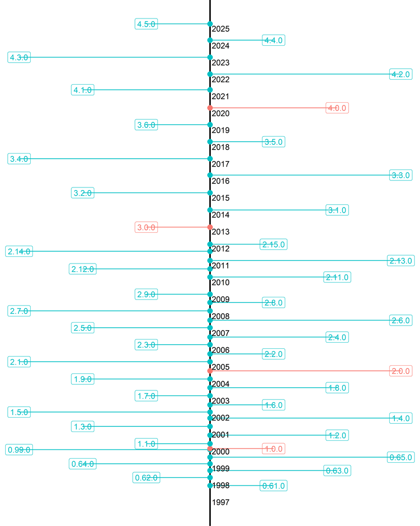

```r
# 加载包
library(ggplot2)
library(data.table)
library(magrittr)

# 数据
rversion <- data.table(version=c('0.49','0.50-a1','0.50-a4','0.60.0','0.60.1','0.61.0',
                                 '0.61.1','0.61.2','0.61.3','0.62.0','0.62.1','0.62.2',
                                 '0.62.3','0.62.4','0.63.0','0.63.1','0.63.2','0.63.3',
                                 '0.64.0','0.64.1','0.64.2','0.65.0','0.65.1','0.90.0',
                                 '0.90.1','0.99.0','0.99.0a','1.0.0','1.0.1','1.1.0',
                                 '1.1.1','1.2.0','1.2.1','1.2.2','1.2.3','1.3.0',
                                 '1.3.0-recommended','1.3.1','1.3.1-recommended','1.4.0',
                                 '1.4.0-recommended','1.4.1','1.4.1-recommended','1.5.0',
                                 '1.5.0-recommended','1.5.1','1.5.1-recommended','1.6.0',
                                 '1.6.1','1.6.2','1.7.0','1.7.1','1.8.0','1.8.1','1.9.0',
                                 '1.9.1','2.0.0','2.0.1','2.1.0','2.1.1','2.2.0','2.2.1',
                                 '2.3.0','2.3.1','2.4.0','2.4.1','2.5.0','2.5.1','2.6.0',
                                 '2.6.1','2.6.2','2.7.0','2.7.1','2.7.2','2.8.0','2.8.1',
                                 '2.9.0','2.9.1','2.9.2','2.10.0','2.10.1','2.11.0',
                                 '2.11.1','2.12.0','2.12.1','2.12.2','2.13.0','2.13.1',
                                 '2.13.2','2.14.0','2.14.1','2.14.2','2.15.0','2.15.1',
                                 '2.15.2','2.15.3','3.0.0','3.0.1','3.0.2','3.0.3',
                                 '3.1.0','3.1.1','3.1.2','3.1.3','3.2.0','3.2.1','3.2.2',
                                 '3.2.3','3.2.4','3.2.4-revised','3.2.5','3.3.0','3.3.1',
                                 '3.3.2','3.3.3','3.4.0','3.4.1','3.4.2','3.4.3','3.4.4',
                                 '3.5.0','3.5.1','3.5.2','3.5.3','3.6.0','3.6.1','3.6.2',
                                 '3.6.3','4.0.0','4.0.1','4.0.2','4.0.3','4.0.4','4.0.5',
                                 '4.1.0','4.1.1','4.1.2','4.1.3','4.2.0','4.2.1','4.2.2',
                                 '4.2.3','4.3.0','4.3.1','4.3.2','4.3.3','4.4.0','4.4.1',
                                 '4.4.2','4.4.3','4.5.0'),
                       date=c('1997-04-23','1997-07-22','1997-09-10','1997-12-04','1997-12-07',
                              '1997-12-22','1998-01-13','1998-03-18','1998-05-03','1998-06-15',
                              '1998-06-15','1998-07-10','1998-08-28','1998-10-24','1998-11-14',
                              '1998-12-05','1999-01-12','1999-03-06','1999-04-08','1999-05-08',
                              '1999-07-05','1999-08-28','1999-10-07','1999-11-22','1999-12-15',
                              '2000-02-07','2000-02-09','2000-02-29','2000-04-14','2000-06-15',
                              '2000-08-15','2000-12-15','2001-01-15','2001-02-26','2001-04-26',
                              '2001-06-22','2001-06-22','2001-08-31','2001-08-31','2001-12-19',
                              '2001-12-19','2002-01-30','2002-01-30','2002-04-29','2002-04-29',
                              '2002-06-17','2002-06-17','2002-10-01','2002-11-01','2003-01-10',
                              '2003-04-16','2003-06-16','2003-10-08','2003-11-21','2004-04-12',
                              '2004-06-21','2004-10-04','2004-11-15','2005-04-19','2005-06-20',
                              '2005-10-06','2005-12-20','2006-04-24','2006-06-01','2006-10-03',
                              '2006-12-18','2007-04-24','2007-06-28','2007-10-03','2007-11-26',
                              '2008-02-08','2008-04-22','2008-06-23','2008-08-25','2008-10-20',
                              '2008-12-22','2009-04-17','2009-06-26','2009-08-24','2009-10-26',
                              '2009-12-14','2010-04-22','2010-05-31','2010-10-15','2010-12-16',
                              '2011-02-25','2011-04-13','2011-07-08','2011-09-30','2011-10-31',
                              '2011-12-22','2012-02-29','2012-03-30','2012-06-22','2012-10-26',
                              '2013-03-01','2013-04-03','2013-05-16','2013-09-25','2014-03-06',
                              '2014-04-10','2014-07-10','2014-10-31','2015-03-09','2015-04-16',
                              '2015-06-18','2015-08-14','2015-12-10','2016-03-16','2016-03-10',
                              '2016-04-14','2016-05-03','2016-06-21','2016-10-31','2017-03-06',
                              '2017-04-21','2017-06-30','2017-09-28','2017-11-30','2018-03-15',
                              '2018-04-23','2018-07-02','2018-12-20','2019-03-11','2019-04-26',
                              '2019-07-05','2019-12-12','2020-02-29','2020-04-24','2020-06-06',
                              '2020-06-22','2020-10-10','2021-02-15','2021-03-31','2021-05-18',
                              '2021-08-10','2021-11-01','2022-03-10','2022-04-22','2022-06-23',
                              '2022-11-01','2023-03-16','2023-04-22','2023-06-16','2023-11-01',
                              '2024-03-01','2024-04-25','2024-06-15','2024-11-01','2025-03-01',
                              '2025-04-11')) %>% .[,date:=as.Date(date)]

# 识别版本重要程度
# 版本号为 x.0.0 为重大版本 big
# 版本号为 x.1.0 x.12.0 x.20.0 为主要版本 major
# 版本号为 x.0.1 为次要版本 minor
rversion_tl <- within(rversion, {
  status <- ifelse(grepl(pattern = "*\\.0\\.0", x = version), "big", version)
  status <- ifelse(grepl(pattern = "*\\.[1-9]{1,2}\\.0$", x = status), "major", status)
  status <- ifelse(!status %in% c("big", "major"), "minor", status)
})

# 定义标签位置
# 只要不是同一天发布的版本，方向相对
# 注意，若用.[,year:=year(date)]，则结果中year为数值型，format(date, "%Y")结果是日期型
positions  <- c(0.5, -0.5, 1.0, -1.0, 1.5, -1.5)

rversion_df <- data.table(
  date = unique(rversion_tl$date) %>% sort(),
  position = rep_len(positions,  length.out = length(unique(rversion_tl$date)))
) %>% .[rversion_tl, on="date"] %>% setorder(date) %>% .[,year:=format(date, "%Y")]

# 生成子集，并重新定义标记位置
rversion_subset <- rversion_df[status %in% c("big", "major")]
rversion_subset[, position:=rep_len(positions,  length.out = nrow(rversion_subset))]

# 画图
ggplot(data = rversion_subset) +
  geom_linerange(aes(y=date, xmin=0, xmax=position, color = status))+
  geom_vline(xintercept = 0, color = "black", linewidth = 1) +
  geom_label(aes(x = position, y = date, label = version, color = status)) +
  geom_point(aes(x = 0, y = date, color = status), size = 3) +
  geom_text(aes(x = 0, y = as.Date(format(date, "%Y-01-01")), label = year), hjust = -0.1)+
  guides(color = "none")+
  theme_void()
```

## 8.19 双y轴

### 8.19.1 连续+离散

代码修改自stackoverflow：https://stackoverflow.com/questions/79605924/ggplot-dual-axis-with-continuous-and-discrete-y-axes

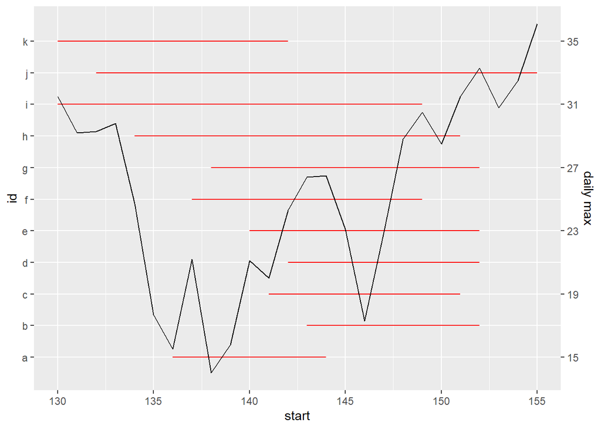

```r
# 加载包
library(ggplot2)

# structure函数用于构建对象并指定属性
# 这里row.name(NA, -11L)，NA意思是行名默认，-11L意思是一共11行
samp.dat <- structure(list(
  id = c("a","b","c","d","e","f","g","h","i","j","k"),
  julian = c(144,152,151,152,152,149,152,151,149,155,142),
  start =  c(136,143,141,142,140,137,138,134,130,132,130),
  last =   c(144,152,151,152,152,149,152,151,149,155,142)),
  class = "data.frame",
  row.names = c(NA, -11L))
samp.wx <- data.frame(
  julian = c(130,131,132,133,134,135,136,137,138,139,140,141,142,
             143,144,145,146,147,148,149,150,151,152,153,154,155),
  daily.max = c(31.5,29.2,29.3,29.8,24.7,17.7,15.5,21.2,14.0,15.8,21.1,20.0,24.3,
                26.4,26.5,23.1,17.3,22.9,28.8,30.5,28.5,31.5,33.3,30.8,32.5,36.1))

# 画图
ggplot(samp.dat, aes(x=julian, y=as.numeric(as.factor(id))*2+13)) +
  geom_segment(aes(x=start, xend=last, yend=as.numeric(as.factor(id))*2+13), color='red') +
  geom_line(data=samp.wx, aes(x=julian, y=daily.max)) +
  scale_y_continuous(breaks=seq(15,35,2), labels=samp.dat$id, name = "id",
                     sec.axis=sec_axis(transform=~.x, name="daily max", breaks=seq(15,35,4))) +
  scale_x_continuous(limits = c(130, 155)) +
  theme(panel.grid.minor.y = element_blank())
```

### 8.19.2 连续+连续

注意：

- 此图通过轴的颜色指示折线对应的y轴，因此是单独画的y轴和标签。
- 由于两个y轴都是连续吧变量，因此很有可能majorgrid对应两侧数值并不都是整数，这里的做法是采用整数区间缩放，如果break是两个y的因子数，则可以满足majorgrid对应的两侧y轴都是整数

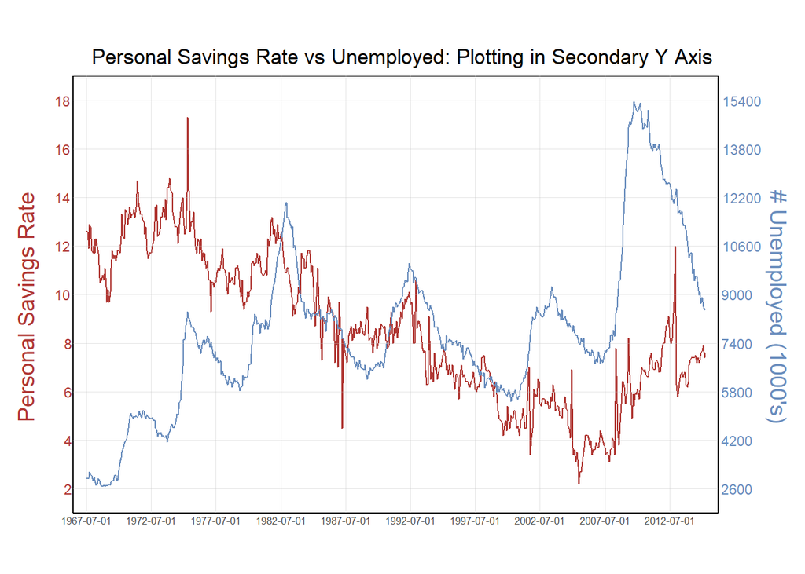

```r
# 加载包
library(ggplot2)
library(data.table)
library(magrittr)

# 生成数据
df <- ggplot2::economics
y1 <- df$psavert
y2 <- df$unemploy

# 将y2映射到y1的范围内，此时y1和y2整数值不对应
target.range <- c(floor(min(y1)), ceiling(max(y1)))                 #求可以涵盖y1的整数范围
origin.range <- c(floor(min(y2/100))*100, ceiling(max(y2/100))*100) #将y2映射到y1，且精确到百位
a <- (target.range[2] - target.range[1]) / (origin.range[2] - origin.range[1])
b <- target.range[1] - a * origin.range[1]
plot.df <- data.table(
  date=as.POSIXct(df$date),
  psavert=df$psavert,
  unemploy=df$unemploy*a+b) %>%
  melt(id="date")

# 时间范围和颜色
b_date <- as.POSIXct("1967-07-01", tz = "UTC")
e_date <- as.POSIXct("2015-04-01", tz = "UTC")
dat.color <- c("#B03834", "#698DBD")

# 四周边框
dat.bor <- data.table(x1=c(rep(b_date-lubridate::years(1), 2), b_date-lubridate::years(1), e_date+lubridate::years(1)),
                      x2=c(rep(e_date+lubridate::years(1), 2), b_date-lubridate::years(1), e_date+lubridate::years(1)),
                      y1=c(19,1,1,1),
                      y2=c(19,1,19,19))

# 内部网格线（前10条竖直线，后9条水平线）
dat.gri <- data.table(x1=c(seq(b_date, e_date, "5 year"), rep(b_date-lubridate::years(1), 9)),
                      x2=c(seq(b_date, e_date, "5 year"), rep(e_date+lubridate::years(1), 9)),
                      y1=c(rep(1,10),  seq(2,18,2)),
                      y2=c(rep(19,10), seq(2,18,2)))

# y轴标签
dat.y1.tex <- data.table(x=rep(b_date-lubridate::years(1), 9), y=seq(2,18,2), lab=seq(2,18,2))
y2.lab <- ((seq(2,18,2)-b)/a) %>% round()
dat.y2.tex <- data.table(x=rep(e_date+lubridate::years(1), 9), y=seq(2,18,2), lab=y2.lab)
# y轴标题
dat.y1.tit <- data.table(x=b_date-lubridate::years(6), y=9.5, lab="Personal Savings Rate")
dat.y2.tit <- data.table(x=e_date+lubridate::years(7), y=9.5, lab="# Unemployed (1000's)")

# 画图
ggplot(plot.df, aes(date, value))+
  geom_line(aes(color=variable),show.legend = F)+
  geom_segment(data=dat.bor, aes(x=x1, xend=x2, y=y1, yend=y2))+ #border
  geom_segment(data=dat.gri, aes(x=x1, xend=x2, y=y1, yend=y2), linewidth=0.2, color="gray", alpha=0.4)+ #grid
  geom_text(data=dat.y1.tex, aes(x,y,label=lab), color=dat.color[1], size=3, hjust=1.2)+
  geom_text(data=dat.y2.tex, aes(x,y,label=lab), color=dat.color[2], size=3, hjust=-0.1)+
  geom_text(data=dat.y1.tit, aes(x,y,label=lab), color=dat.color[1], size=5, vjust=1.5, angle=90)+
  geom_text(data=dat.y2.tit, aes(x,y,label=lab), color=dat.color[2], size=5, vjust=1.5, angle=-90)+
  scale_color_manual(values = dat.color)+
  scale_x_datetime(date_labels = "%Y-%m-%d", breaks = seq(b_date, e_date, by = "5 year"),
                   limits = c(b_date-lubridate::years(6), e_date+lubridate::years(7)), expand = c(0,0))+
  scale_y_continuous(breaks = seq(2,18,2), limits = c(1,19), expand = c(0,0))+
  labs(x= NULL, y=NULL,title = "Personal Savings Rate vs Unemployed: Plotting in Secondary Y Axis", color=NULL)+
  theme_bw()+
  theme(aspect.ratio = 1/1.8,
        panel.border = element_blank(),
        axis.text.y = element_blank(),
        axis.text.x = element_text(size = 6.5),
        axis.ticks = element_blank(),
        panel.grid = element_blank(),
        plot.title = element_text(hjust = 0.5))
```

## 8.20 跑道图

作者：心有灵犀

链接：https://zhuanlan.zhihu.com/p/1939076938447683940

来源：知乎

代码来源 https://www.r2omics.cn/

ggstyle：https://github.com/sz-zyp/ggstyle

安装ggstyle，需要下载tar.gz格式的安装包，本地安装

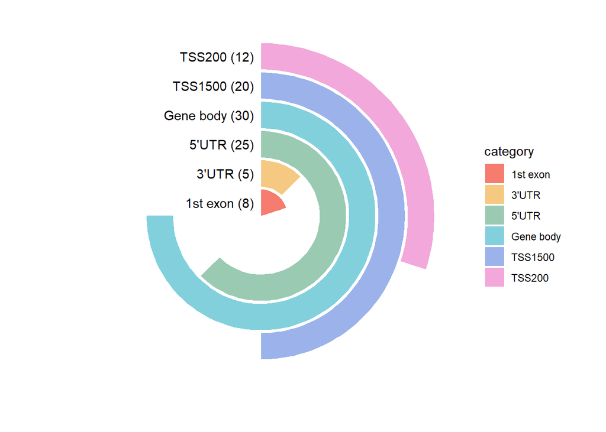

```r
# 加载包
library(ggplot2)
# library(ggview)

# 创建数据框 df，包含两列：类别 (category) 和数值 (value)
df <- data.frame(
  category = c("Gene body", "5'UTR", "TSS1500", "TSS200", "1st exon", "3'UTR"),
  value = c(30, 25, 20, 12, 8, 5)
)

# 绘图
ggplot(df,aes(x=category,y=value,fill=category)) +
  geom_bar(stat="identity") +
  geom_text(aes(label=paste0(category," (",value,")  "),y=0), hjust=1) +  # 在每个条形的底部显示标签：类别和值
  coord_polar(theta = "y", start = 0) +          # 将条形图转换为极坐标图，theta="y"表示按 y 轴的数值进行旋转，start=0从顶部开始
  # ggstyle::scale_fill_sci(palette="ggplot2")+
  ggstyle::scale_fill_sci(palette="rainbow1") +  # 设置填充颜色的调色板，这里使用“rainbow1”颜色
  # ggstyle::scale_fill_sci(palette="DreamyWhisper")+
  # ggstyle::scale_fill_sci(palette="NatureRhythm")+
  # ggstyle::scale_fill_sci(palette="MysticDream")+
  # ggstyle::scale_fill_sci(palette="FutureGlow")+
  # ggstyle::scale_fill_sci(palette="TwilightScenery")+
  # ggstyle::scale_fill_sci(palette="ClassicContrast")+
  # ggstyle::scale_fill_sci(palette="FreshElegance")+
  # ggstyle::scale_fill_sci(palette="Set1")+
  # ggstyle::scale_fill_sci(palette="Set2")+
  # ggstyle::scale_fill_sci(palette="Set3")+
  # ggstyle::scale_fill_sci(palette="npg")+
  # ggstyle::scale_fill_sci(palette="bmj")+
  # ggstyle::scale_fill_sci(palette="aaas")+
  # ggstyle::scale_fill_sci(palette="nejm")+
  # ggstyle::scale_fill_sci(palette="lancet")+
  # ggstyle::scale_fill_sci(palette="jama")+
  # ggstyle::scale_fill_sci(palette="jco")+
  # ggstyle::scale_fill_sci(palette="d3.category10")+
  # ggstyle::scale_fill_sci(palette="observable10")+
  ylim(0, max(df$value)/0.75) +                  # 设置y轴的显示范围，在0-270度的范围内绘图
  theme_void()
```

```r
  # canvas(width=10, height=10, dpi=500, units="cm")
```

## 8.21 piper图

Piper图是水化学研究中常用的图，用于直观展示水体中主要阴阳离子的组成特征和类型。

我在网上找到了使用R绘制piper图的代码，[参考1](https://gist.github.com/johnDorian/5561272)，[参考2](https://github.com/markolipka/ggplot_Piper)，但是感觉不够灵活，一些细节无法修改，因此写了这个版本。

注意：

- 这里定义了两个函数，由于数据转换和绘图时，都用到了三角形菱形顶点，为了不污染global环境，这里在`to_piper_data`函数内部定义了一个global上的环境，用于数据共享，也因此必须先运行`to_piper_data`函数，否则运行`piper_plot`会有提示并报错

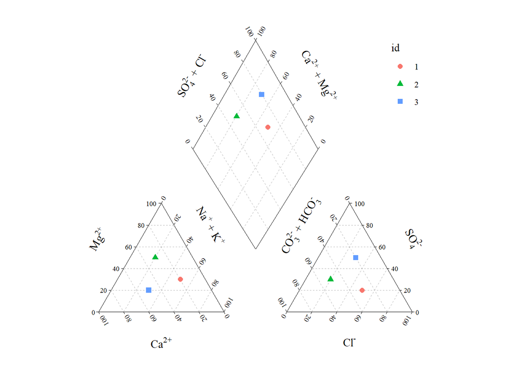

```r
# 加载包
library(ggplot2)
library(stringr)
library(data.table)

# 定义函数
to_piper_data <- function(data, type){
  # 将离子数据转换为可画piper图的xy坐标，type为当前data中的单位类型
  # 注意要运行这个函数，再运行piper_plot函数
  # 对数据的要求如下
  #  1. data必须为data.frame类，必须包含完整的8大离子，且列名必须为Ca, Mg, Na, K, Cl, SO4, CO3, HCO3，如没有其中某列，添加后数据填0
  #  2. type必须为mmol_L, mg_L, 或meq_L其中之一

  # 判断输入参数是否有明显错误
  setDT(data)
  colname <- colnames(data)
  necname <- c("Ca", "Mg", "Na", "K", "Cl", "SO4", "CO3", "HCO3")
  nectype <- c("mmol_L", "mg_L", "meq_L")
  if(!all(necname %in% colname)) stop("错误：data中缺少必要离子数据!")
  if(!type %in% nectype)         stop("错误：type是data中数据的单位，必须为mmol_L, mg_L, 或meq_L其中之一！")

  # data中如果没有cusname列，则添加一列id作为cusname
  if(ncol(data)==8) data$id <- 1:nrow(data)

  # 生成转换所需的三角形、菱形顶点，并与绘图函数共享数据
  # 定义三角形边长、三角形菱形间隔
  tel <- 100  #三角形边长
  tdg <- 50   #三角形菱形间隔（等同于底边两个三角形相隔距离）

  # 定义坐标关键点（都是自左下逆时针顺序）
  # 左三角形，三个顶点
  tl_p1 <- c(0, 0)
  tl_p2 <- c(tl_p1[1]+tel, tl_p1[2])
  tl_p3 <- c(tl_p1[1]+tel*cos(pi/3), tl_p1[2]+tel*sin(pi/3))
  # 右三角形，三个顶点
  tr_p1 <- c(tl_p1[1]+tel+tdg, tl_p1[2])
  tr_p2 <- c(tl_p2[1]+tel+tdg, tl_p2[2])
  tr_p3 <- c(tl_p3[1]+tel+tdg, tl_p3[2])
  # 中间菱形，四个顶点
  dc_p1 <- c(tl_p1[1]+(tel+tdg)*cos(pi/3), tl_p1[2]+(tel+tdg)*sin(pi/3))
  dc_p2 <- c(tl_p2[1]+(tdg/2),             tl_p2[2]+tdg*sin(pi/2))
  dc_p3 <- c(tr_p2[1]-(tel+tdg)*cos(pi/3), dc_p1[2])
  dc_p4 <- c(dc_p2[1],                     tl_p1[2]+(tel*2+tdg)*sin(pi/3))

  # 与piper_plot函数共享数据，但不污染global environment
  data_shared <- list(
    tel=tel,     tdg=tdg,
    tl_p1=tl_p1, tl_p2=tl_p2, tl_p3=tl_p3,
    tr_p1=tr_p1, tr_p2=tr_p2, tr_p3=tr_p3,
    dc_p1=dc_p1, dc_p2=dc_p2, dc_p3=dc_p3, dc_p4=dc_p4
  )
  .piper_env <<- new.env(parent = emptyenv())     #生成一个环境，隐藏变量，保存在global中
  list2env(data_shared, envir = .piper_env)

  # 将数据转换为meq/L格式
  # 定义一个元素必要信息的data.table
  elem.info <- data.table(
    element = c("Ca",  "Mg",  "Na",  "K",   "Cl",  "SO4", "CO3", "HCO3"),
    molweig = c(40.08, 24.30, 22.99, 39.10, 35.45, 96.06, 60.01, 61.02),
    valence = c(2,     2,     1,     1,     1,     2,     2,     1)
  )
  # 根据当前数据的单位选择转换方式
  if(type == "meq_L"){
    data_meq <- copy(data)
  } else if(type == "mmol_L"){
    # mmol/L乘以valence及为meq/L
    ion_cols <- elem.info$element
    data_meq <- copy(data) %>%
      .[, (ion_cols) := lapply(ion_cols, function(x) get(x) * elem.info[element == x, valence])]
  } else {
    # mmol/L除以molweig再乘以valence及为meq/L
    ion_cols <- elem.info$element
    data_meq <- copy(data) %>%
      .[, (ion_cols) := lapply(ion_cols, function(x) {
        valence <- elem.info[element == x, valence]
        molweig <- elem.info[element == x, molweig]
        get(x) / molweig * valence
      })]
  }

  # 将meq/L数据转换为百分比数据（0~1之间数值）
  cusname <- setdiff(names(data), necname)
  data_meq <- data_meq[, c(cusname, necname), with = F]        #整理下变量顺序
  pct_cols <- c(cusname,
                "Ca_pct", "Mg_pct", "NaK_pct", "Cl_pct", "SO4_pct", "CO3HCO3_pct",
                "SO4Cl_pct", "CaMg_pct")
  data_pct <- copy(data_meq) %>%
    .[, `:=`(cation=Ca+Mg+Na+K, anion=Cl+SO4+CO3+HCO3)] %>%
    .[, `:=`(
      Ca_pct      = Ca/cation,
      Mg_pct      = Mg/cation,
      NaK_pct     = (Na+K)/cation,
      Cl_pct      = Cl/anion,
      SO4_pct     = SO4/anion,
      CO3HCO3_pct = (CO3+HCO3)/anion,
      SO4Cl_pct   = (SO4+Cl)/anion,
      CaMg_pct    = (Ca+Mg)/cation
    )] %>%
    .[, pct_cols, with = F]

  # 将比例数据转为可绘制piper图的xy笛卡尔坐标
  # 其中
  # 三角形部分，重心法，几何含义是，当某个p=1时，就是对应的三角形顶点
  # 菱形部分，利用左上右上两轴和占比，计算出两个点，再利用平行于轴的直线相交，求点坐标
  # 左下三角形部分
  data_tl <- copy(data_pct) %>%
    .[, `:=`(
      x = Ca_pct*tl_p1[1]+NaK_pct*tl_p2[1]+Mg_pct*tl_p3[1],
      y = Ca_pct*tl_p1[2]+NaK_pct*tl_p2[2]+Mg_pct*tl_p3[2]
    )] %>%
    .[, loca:="triangle_left"]
  # 右下三角形部分
  data_tr <- copy(data_pct) %>%
    .[, `:=`(
      x = Cl_pct*tr_p2[1]+SO4_pct*tr_p3[1]+CO3HCO3_pct*tr_p1[1],
      y = Cl_pct*tr_p2[2]+SO4_pct*tr_p3[2]+CO3HCO3_pct*tr_p1[2]
    )] %>%
    .[, loca:="triangle_right"]
  # 中间菱形部分
  data_dc <- copy(data_pct) %>%
    .[, `:=`(
      ax = dc_p1[1]+SO4Cl_pct*(dc_p4[1]-dc_p1[1]),
      ay = dc_p1[2]+SO4Cl_pct*(dc_p4[2]-dc_p1[2]),
      bx = dc_p3[1]+CaMg_pct*(dc_p4[1]-dc_p3[1]),
      by = dc_p3[2]+CaMg_pct*(dc_p4[2]-dc_p3[2])
    )] %>%
    .[, x:=(sqrt(3)*ax+ay-by+sqrt(3)*bx)/(2*sqrt(3))] %>%
    .[, y:=sqrt(3)*(x-bx)+by] %>%
    .[, c("ax", "ay", "bx", "by"):=NULL] %>%
    .[, loca:="diamond_center"]
  # 整合数据
  data_piper <- rbind(data_tl, data_tr, data_dc) %>% .[, c(cusname, "x", "y", "loca"), with = F]

  # 整合输出
  names(data_meq) <- c(cusname, paste0(necname, "_meq_L"))  #meq文件重命名列
  res <- list(data_piper=data_piper, data_meq=data_meq, data_pct=data_pct)
  invisible(NULL)
  return(res)
}
piper_plot <- function(){
  # 定义一个piper绘图函数
  # 与to_piper_data共享三角形菱形顶点数据
  # 因此需要先运行to_piper_data函数，再运行此函数，否则会报错
  if (!exists(".piper_env", envir = .GlobalEnv) || !is.environment(get(".piper_env", envir = .GlobalEnv))) {
    stop("错误：共享数据不存在，请先运行to_piper_data函数！")
  }

  # 释放全部共享变量进入当前环境中
  list2env(as.list(.piper_env), envir = environment())

  # 生成三角形、菱形边分隔点
  gin <- 6      #网格划分个数
  # 左三角形，三个边grid分割点
  tl_l1 <- data.frame(x=seq(tl_p1[1], tl_p2[1], len=gin), y=seq(tl_p1[2], tl_p2[2], len=gin))
  tl_l2 <- data.frame(x=seq(tl_p2[1], tl_p3[1], len=gin), y=seq(tl_p2[2], tl_p3[2], len=gin))
  tl_l3 <- data.frame(x=seq(tl_p3[1], tl_p1[1], len=gin), y=seq(tl_p3[2], tl_p1[2], len=gin))
  # 右下三角形，三个边grid分割点
  tr_l1 <- data.frame(x=seq(tr_p1[1], tr_p2[1], len=gin), y=seq(tr_p1[2], tr_p2[2], len=gin))
  tr_l2 <- data.frame(x=seq(tr_p2[1], tr_p3[1], len=gin), y=seq(tr_p2[2], tr_p3[2], len=gin))
  tr_l3 <- data.frame(x=seq(tr_p3[1], tr_p1[1], len=gin), y=seq(tr_p3[2], tr_p1[2], len=gin))
  # 中间菱形，四个边grid分割点
  dc_l1 <- data.frame(x=seq(dc_p1[1], dc_p2[1], len=gin), y=seq(dc_p1[2], dc_p2[2], len=gin))
  dc_l2 <- data.frame(x=seq(dc_p2[1], dc_p3[1], len=gin), y=seq(dc_p2[2], dc_p3[2], len=gin))
  dc_l3 <- data.frame(x=seq(dc_p3[1], dc_p4[1], len=gin), y=seq(dc_p3[2], dc_p4[2], len=gin))
  dc_l4 <- data.frame(x=seq(dc_p4[1], dc_p1[1], len=gin), y=seq(dc_p4[2], dc_p1[2], len=gin))

  # 坐标轴，即三角形和菱形的边
  piper_axis_solid <- rbind(
    # 左三角形
    data.frame(
      x0 = c(tl_p1[1], tl_p2[1], tl_p3[1]), y0 = c(tl_p1[2], tl_p2[2], tl_p3[2]),
      x1 = c(tl_p2[1], tl_p3[1], tl_p1[1]), y1 = c(tl_p2[2], tl_p3[2], tl_p1[2])
    ),
    # 右三角形
    data.frame(
      x0 = c(tr_p1[1], tr_p2[1], tr_p3[1]), y0 = c(tr_p1[2], tr_p2[2], tr_p3[2]),
      x1 = c(tr_p2[1], tr_p3[1], tr_p1[1]), y1 = c(tr_p2[2], tr_p3[2], tr_p1[2])
    ),
    # 中间菱形
    data.frame(
      x0 = c(dc_p1[1], dc_p2[1], dc_p3[1], dc_p4[1]), y0 = c(dc_p1[2], dc_p2[2], dc_p3[2], dc_p4[2]),
      x1 = c(dc_p2[1], dc_p3[1], dc_p4[1], dc_p1[1]), y1 = c(dc_p2[2], dc_p3[2], dc_p4[2], dc_p1[2])
    )
  )

  # 图内grid，分正序逆序是因为，grid线连接时，由正序连接到逆序
  grid_p <- 2:(gin-1)     #正序
  grid_n <- (gin-1):2     #逆序
  piper_axis_grid <- data.frame(
    x0 = c(tl_l1$x[grid_p], tl_l2$x[grid_p], tl_l3$x[grid_p],
           tr_l1$x[grid_p], tr_l2$x[grid_p], tr_l3$x[grid_p],
           dc_l1$x[grid_p], dc_l2$x[grid_p]),
    y0 = c(tl_l1$y[grid_p], tl_l2$y[grid_p], tl_l3$y[grid_p],
           tr_l1$y[grid_p], tr_l2$y[grid_p], tr_l3$y[grid_p],
           dc_l1$y[grid_p], dc_l2$y[grid_p]),
    x1 = c(tl_l2$x[grid_n], tl_l3$x[grid_n], tl_l1$x[grid_n],
           tr_l2$x[grid_n], tr_l3$x[grid_n], tr_l1$x[grid_n],
           dc_l3$x[grid_n], dc_l4$x[grid_n]),
    y1 = c(tl_l2$y[grid_n], tl_l3$y[grid_n], tl_l1$y[grid_n],
           tr_l2$y[grid_n], tr_l3$y[grid_n], tr_l1$y[grid_n],
           dc_l3$y[grid_n], dc_l4$y[grid_n])
  )

  # 轴标签
  # 顺序是
  alab_p <- 1:gin   #部分是顺序
  alab_n <- gin:1   #部分是逆序
  l_text_l <- seq(0, 100, len=gin) %>% str_pad(3, "left")     #右对齐的填充左侧，以保证hjust时偏移相同长度
  l_text_r <- seq(0, 100, len=gin) %>% str_pad(3, "right")    #左对齐的填充右侧，以保证hjust时偏移相同长度
  axis_lab <- data.frame(
    x = c(tl_l1$x[alab_n], tl_l2$x[alab_n], tl_l3$x[alab_n], tr_l1$x[alab_p], tr_l2$x[alab_p], tr_l3$x[alab_p], dc_l3$x[alab_p], dc_l4$x[alab_n]),
    y = c(tl_l1$y[alab_n], tl_l2$y[alab_n], tl_l3$y[alab_n], tr_l1$y[alab_p], tr_l2$y[alab_p], tr_l3$y[alab_p], dc_l3$y[alab_p], dc_l4$y[alab_n]),
    l = c(rep(l_text_l, 3), rep(l_text_r, 3), l_text_l, l_text_r),
    a = rep(c(120, 240, 0, 240, 0, 120, 60, 300), each=gin),
    v = 0.5,
    h = rep(c(1.5, 1.5, 1.5, -0.5, -0.5, -0.5, -0.5, 1.5), each=gin)
  )

  # 轴ticks
  axis_tic <- data.frame(
    x = axis_lab$x,
    y = axis_lab$y,
    a = rep(c(300, 60, 180, 240, 0, 120, 60, 120), each=gin)*pi/180,   #函数geom_spoke用的是弧度制
    r = tel*0.02
  )

  # 轴title
  # 注意:
  # 三角形或菱形的独享的轴，title都是沿与轴垂直的方向去gap
  # 公共轴，NaK(nk)和CO3HCO3(ak)，是沿60度方向斜向右上左上去gap，因此他们的gap角是pi/3，而不是pi/6
  # 轴title坐标，文字的水平方向居中，垂向上偏移title_gap，这里用绝对偏移，没用ggplot的just是因为它的偏移量与文字大小相关，当调节字号时偏移量会变化
  title_gap <- tdg*0.6
  x_ca <- tel/2;                                       y_ca <- tl_p1[2]-title_gap*0.8
  x_cl <- tel*1.5+tdg;                                 y_cl <- tl_p1[2]-title_gap*0.8
  x_mg <- (tl_p1[1]+tl_p3[1])/2-title_gap*cos(pi/6);   y_mg <- (tl_p1[2]+tl_p3[2])/2+title_gap*sin(pi/6)
  x_nk <- (tl_p2[1]+tl_p3[1])/2+title_gap*cos(pi/3);   y_nk <- (tl_p2[2]+tl_p3[2])/2+title_gap*sin(pi/3)
  x_ak <- (tr_p1[1]+tr_p3[1])/2-title_gap*cos(pi/3);   y_ak <- (tr_p1[2]+tr_p3[2])/2+title_gap*sin(pi/3)
  x_so <- (tr_p2[1]+tr_p3[1])/2+title_gap*cos(pi/6);   y_so <- (tr_p2[2]+tr_p3[2])/2+title_gap*sin(pi/6)
  x_socl <- (dc_p1[1]+dc_p4[1])/2-title_gap*cos(pi/6); y_socl <- (dc_p1[2]+dc_p4[2])/2+title_gap*sin(pi/6)
  x_camg <- (dc_p3[1]+dc_p4[1])/2+title_gap*cos(pi/6); y_camg <- (dc_p3[2]+dc_p4[2])/2+title_gap*sin(pi/6)
  # 轴title绘图数据
  axis_tit <- data.frame(
    x = c(x_ca, x_cl, x_mg, x_nk, x_ak, x_so, x_socl, x_camg),
    y = c(y_ca, y_cl, y_mg, y_nk, y_ak, y_so, y_socl, y_camg),
    l = c("Ca^'2+'", "Cl^'-'", "Mg^'2+'", "Na^'+'*' + '*K^'+'", "CO[3]^'2-'*' + '*HCO[3]^'-'", "SO[4]^'2-'", "SO[4]^'2-'*' + '*Cl^'-'", "Ca^'2+'*' + '*Mg^'2+'"),
    a = c(0, 0, 60, 300, 60, 300, 60, 300),       #title的角度，从下至上、从左至右
    v = 0.5,
    h = 0.5
  )

  # 绘图
  xdrange <- c(tl_p1[1]-tdg*0.6, tr_p2[1]+tdg*0.6)   #显示范围调整
  ydrange <- c(tl_p1[2]-tdg*0.5, dc_p4[2]+tdg*0.3)   #显示范围调整
  p <- ggplot()+
    geom_segment(data=piper_axis_solid, aes(x=x0, y=y0, xend=x1, yend=y1), linewidth=0.3)+                             #三角形菱形
    geom_segment(data=piper_axis_grid, aes(x=x0, y=y0, xend=x1, yend=y1), linetype=2, linewidth=0.1, color="gray70")+  #图grid
    geom_spoke(data=axis_tic, aes(x=x, y=y, angle=a, radius=r), linewidth=0.3)+                                        #轴ticks
    geom_text(data=axis_lab, aes(x=x, y=y, label=l, angle=a, vjust=v, hjust=h), size=2.5, family="serif")+             #轴label
    geom_text(data=axis_tit, aes(x=x, y=y, label=l, angle=a, vjust=v, hjust=h), parse=T, size=4, family="serif")+      #轴title
    scale_x_continuous(limits = xdrange)+
    scale_y_continuous(limits = ydrange)+
    coord_fixed(ratio=1)+
    theme_bw() +
    theme(
      panel.grid = element_blank(),
      panel.border = element_blank(),
      axis.ticks = element_blank(),
      axis.text = element_blank(),
      axis.title = element_blank()
    )

  # 返回图
  return(p)
}

# 测试数据集，按meq/L有明确比例关系
data <- data.frame(
  id   = c(1, 2, 3) %>% factor(),   #分类变量必须是因子型
  Ca   = c(2, 3, 5),
  Mg   = c(3, 5, 2),
  Na   = c(2, 1, 1),
  K    = c(3, 1, 2),
  Cl   = c(5, 2, 3),
  SO4  = c(2, 3, 5),
  CO3  = c(1, 2, 1),
  HCO3 = c(2, 3, 1)
)

# 数据转换与绘图
# 绘图结果在rstudio中看起来有点小，但使用下面代码查看或保存后，比例显示正常
# ggview::canvas(width=13, heigh=12, units="cm", dpi=600)
# ggsave("aaa.tiff", width=13, heigh=12, units="cm", dpi=600)
data_piper <- to_piper_data(data, type="meq_L")
piper_plot()+
  geom_point(data = data_piper$data_piper, aes(x, y, color=id, shape=id), size=2)+
  theme(
    text = element_text(family="serif"),
    legend.position = "inside",
    legend.position.inside = c(0.85,0.8)
  )
```

# 9. 分面子图坐标轴设置

可用这个包进行子图坐标单独设置：[ggh4x包](https://github.com/teunbrand/ggh4x)

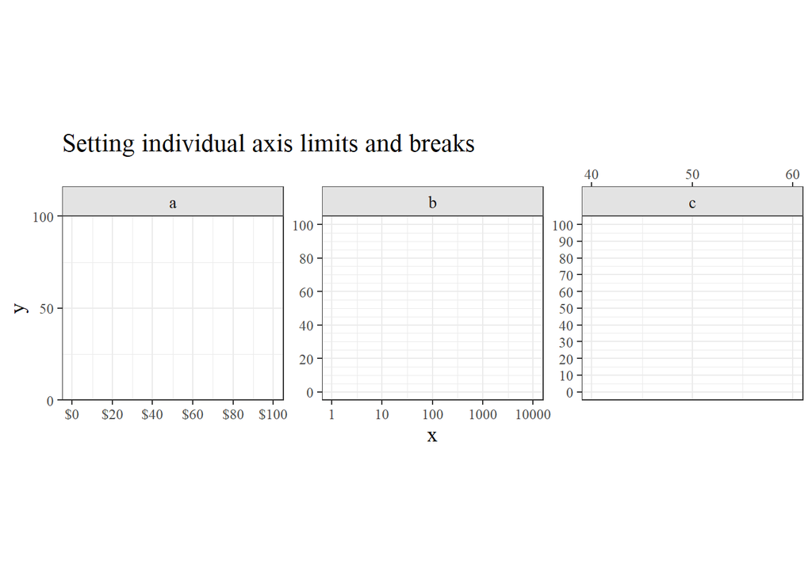

```r
# 加载包
library(ggh4x)
library(data.table)

# 数据
data <- data.frame(class = c('z'), x = 1:10,  value = 1, f = c("a","a","a", "b","b","b", "c","c","c","c"))

# 坐标轴设置
ind_scale_x <- list(
  scale_x_continuous(limits = c(0,100), breaks = seq(0, 100, 20), labels = scales::dollar),
  scale_x_log10(limits = c(1,10000)),
  scale_x_continuous(limits = c(40,60), breaks = seq(0, 100, 10), position = "top")
)
ind_scale_y <- list(
  scale_y_continuous(limits = c(0,100), breaks = seq(0, 100, 50), expand = c(0,0)),
  scale_y_continuous(limits = c(0,100), breaks = seq(0, 100, 20), minor_breaks = seq(0,100,5)),
  scale_y_continuous(limits = c(0,100), n.breaks = 10)
)

# 绘图
ggplot(data, aes(x, value)) +
  geom_blank()+
  facet_wrap(f~., scales = "free") +
  facetted_pos_scales(x = ind_scale_x, y = ind_scale_y)+
  labs(x = "x", y = "y", title = "Setting individual axis limits and breaks")+
  theme_bw() +
  theme(aspect.ratio = 1/1.2,
        strip.background = element_rect(fill = "grey89", color = "gray30"),
        axis.text = element_text(size = 9),
        text = element_text(size = 13, family = "serif"))
```

# 10. ggplot2线图总结

除了geom_line/geom_path，ggplot画单独线段/直线，有以下几种方法

1. geom_linerange()：线段，水平或垂直的, aes是(x,ymin,ymax)或者(y,xmin,xmax)
2. geom_segment()：线段，任意方向的，aes是x, xend, y, yend，四个都得有
3. geom_hline/geom_vline()：直线，垂直或水平的, aes是xintercept或yintercept
4. geom_abline()：直线，根据斜率和截距的，aes是slope和intercept
5. geom_spoke()：射线，aes是x、y、angle、raduis，其中angle是弧度制
6. geom_function()：显示x轴（limit指定的）范围内的图像，如果没定义域，默认01区间

注意：

- 画直线时，必须有确定范围（如下图中的point图层），否则x或y轴数值将不会显示
- 在geom_segment和geom_hline/geom_vline中，Inf可以用来表示图像边缘，geom_linerange试了不生效

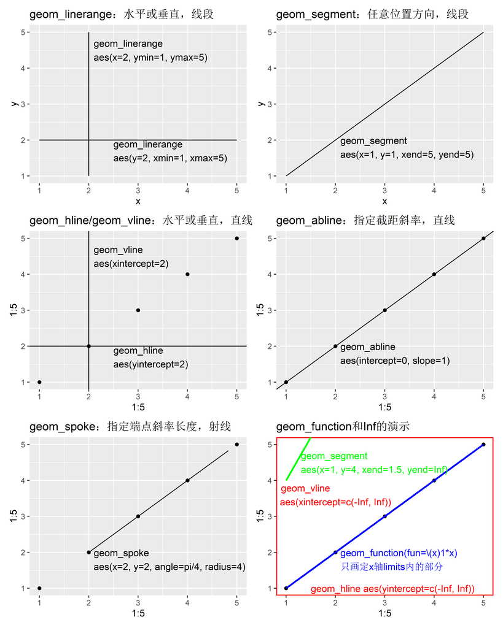

```r
# 加载包
library(ggplot2)
library(patchwork)

# 绘图
p1 <- ggplot()+
  geom_linerange(aes(y=2, xmin=1, xmax=5))+
  geom_linerange(aes(x=2, ymin=1, ymax=5))+
  annotate("text", x=2.5, y=1.7, label="geom_linerange \naes(y=2, xmin=1, xmax=5)", hjust=0)+
  annotate("text", x=2.1, y=4.5, label="geom_linerange \naes(x=2, ymin=1, ymax=5)", hjust=0)+
  ggtitle("geom_linerange：水平或垂直，线段")

p2 <- ggplot()+
  geom_segment(aes(x=1, y=1, xend=5, yend=5))+
  annotate("text", x=2.1, y=1.8, label="geom_segment \naes(x=1, y=1, xend=5, yend=5)", hjust=0)+
  ggtitle("geom_segment：任意位置方向，线段")

p3 <- ggplot()+
  geom_point(aes(1:5, 1:5))+
  geom_hline(aes(yintercept=2))+
  geom_vline(aes(xintercept=2))+
  annotate("text", x=2.5, y=1.7, label="geom_hline \naes(yintercept=2)", hjust=0)+
  annotate("text", x=2.1, y=4.5, label="geom_vline \naes(xintercept=2)", hjust=0)+
  ggtitle("geom_hline/geom_vline：水平或垂直，直线")

p4 <- ggplot()+
  geom_point(aes(1:5, 1:5))+
  geom_abline(aes(intercept=0, slope=1))+
  annotate("text", x=2.1, y=1.8, label="geom_abline \naes(intercept=0, slope=1)", hjust=0)+
  ggtitle("geom_abline：指定截距斜率，直线")

p5 <- ggplot()+
  geom_point(aes(1:5, 1:5))+
  geom_spoke(aes(x=2, y=2, angle=pi/4, radius=4))+
  annotate("text", x=2.1, y=1.8, label="geom_spoke \naes(x=2, y=2, angle=pi/4, radius=4)", hjust=0)+
  ggtitle("geom_spoke：指定端点斜率长度，射线")

p6 <- ggplot()+
  geom_point(aes(1:5, 1:5))+
  geom_function(fun=\(x)1*x, color="blue", linewidth=1)+
  geom_vline(aes(xintercept=c(-Inf, Inf)), color="red", linewidth=1)+
  geom_hline(aes(yintercept=c(-Inf, Inf)), color="red", linewidth=1)+
  geom_segment(aes(x=1, y=4, xend=1.5, yend=Inf), color="green", linewidth=1)+
  annotate("text", x=2.1, y=1.8, label="geom_function(fun=\\(x)1*x) \n只画定x轴limits内的部分", hjust=0, color="blue")+
  annotate("text", x=1, y=3.6, label="geom_vline \n  aes(xintercept=c(-Inf, Inf))", hjust=0.1, color="red")+
  annotate("text", x=1.5, y=1, label="geom_hline aes(yintercept=c(-Inf, Inf))", hjust=0, color="red")+
  annotate("text", x=1.3, y=4.5, label="geom_segment \naes(x=1, y=4, xend=1.5, yend=Inf)", hjust=0, color="green")+
  ggtitle("geom_function和Inf的演示")+
  theme(panel.background = element_rect(fill="white"))

# 合并
(p1+p2)/(p3+p4)/(p5+p6)
```

# 11. 关于legend的一切

试图总结ggplot2中有关legend的一切参数设置。

首先在11.0中，从表现形式角度，以纯文字和代码总结legend的各种调节功能。此后以具体函数为小节，总结可调节的功能。

## 11.0 legend功能总结

1. 隐藏legend：
- theme(legend.position = “none”) #隐藏所有legend
- guides(color = “none”) #隐藏特定类型legend
- geom_point(show.legend = FALSE) #隐藏特定图层legend
2. 隐藏legend的title：
- labs(color = ““) #隐藏特定类型的title

## 11.1 geom

geom_图层函数，可以修改指定图层的部分图例参数如：

1. 隐藏或显示图例：`show.legend=T` or `F`
2. 转换图例类型：`key_glyph=draw_key_rect` or `"rect"`
3. 美学映射的继承关系：`inherit.aes=T` or `F`

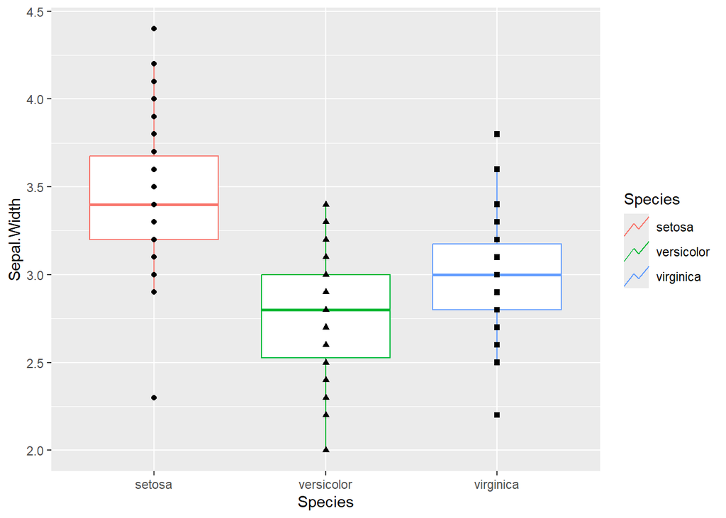

```r
# 加载包
library(ggplot2)

# 绘图
ggplot(iris, aes(Species, Sepal.Width, color=Species))+
  geom_boxplot(aes(color=Species), key_glyph=draw_key_timeseries)+                    #转为boxplot图例为timeseries图例
  geom_point(aes(Species, Sepal.Width, shape=Species), inherit.aes=F, show.legend=F)  #point图层，不继承aes、不显示图例
```

## 11.2 guides

guide_legend函数，放在guides内，主要用于调整：

1. 图例标题title
2. 图例位置position：“none”,“left”,“right”,“top”,“bottom”,“inside”（inside需要进一步在theme中定义位置）
3. 图例方向direction：“horizontal”,“vertical”
4. 图例行列数量nrow, ncol
5. 图例排布顺序reverse
6. 不同图例之间的顺序order：数值小的在前面
7. 图例key的大小（fill时可以调大小，color时是占位大小）keyheight,keywidth
8. 调整key的参数override.aes，会覆盖原有分类属性，包括
- color：图例项的颜色。
- fill：图例项的填充颜色。
- size：图例项的大小。
- shape：图例项的形状。
- linetype：图例项的线型。
- alpha：图例项的透明度。

注意

1. position等于top或bottom时，会默认将方向转化为horizontal
2. override.aes的修改，只修改图例部分，并不会与绘图区域联动
3. 如果要隐藏相关图例，可以这样：`guides(size = "none")`
4. **图例key的长、宽、大小，当图层是color时，不可调整，只有是fill时才可调**

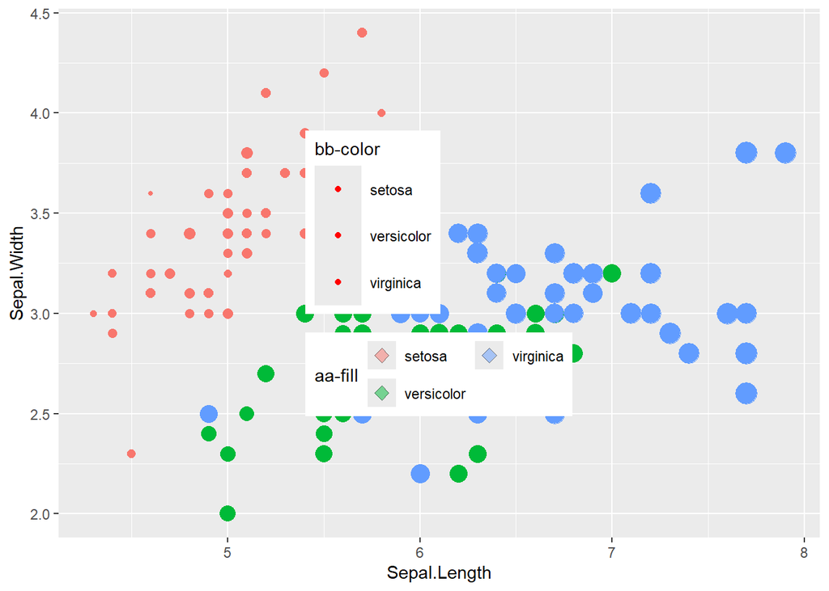

```r
# 加载包
library(ggplot2)

# 绘图
ggplot(iris, aes(Sepal.Length, Sepal.Width, fill=Species, color=Species, size=Petal.Length)) +
  geom_point()+
  guides(fill=guide_legend(title="aa-fill",
                           position = "inside",
                           direction = "horizontal",
                           nrow=2,
                           order=2,
                           override.aes = list(alpha=0.5, size=3, shape=23)),
         color=guide_legend(title="bb-color",
                            position = "inside",
                            order = 1,
                            keyheight = unit(1, "cm"),
                            keywidth = unit(1, "cm"),
                            override.aes = list(color="red")),
         size="none")
```

## 11.2 labs

labs可以设置的功能包括：

1. 标题title，此外ggtitle可调节标题、副标题
2. 副标题subtitle
3. 说明文字caption
4. 标签tag
5. 图形辅助信息alt（图形无法显示时的展示信息）
6. 坐标轴标题xy
7. 图例标题color/fill/shape等

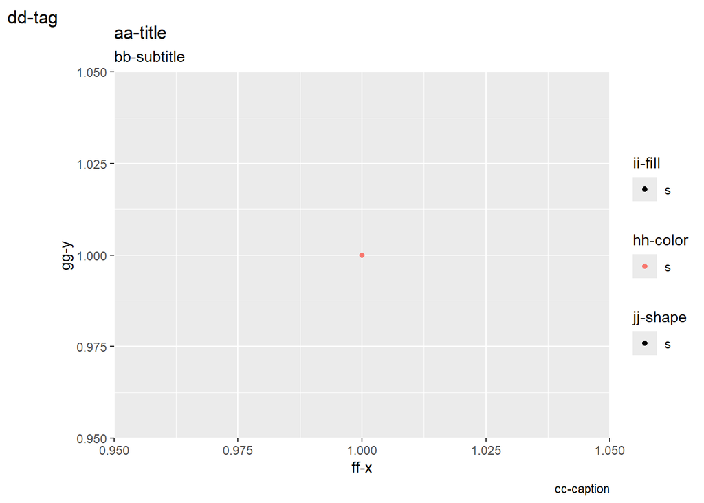

```r
# 加载包
library(ggplot2)
library(data.table)

# 数据
dat <- data.table(a=1,b=1,c1="s",c2="s",c3="s")

# 绘图
ggplot(dat, aes(a,b,color=c1,fill=c2,shape=c3))+
  geom_point()+
  labs(title = "aa-title",
       subtitle = "bb-subtitle",
       caption = "cc-caption",
       tag = "dd-tag",
       alt = "ee-alt",
       x = "ff-x", y = "gg-y",
       color = "hh-color",
       fill = "ii-fill",
       shape = "jj-shape")
```

## 11.3 scale_*_manual

scale_fill/color/shape等_manual可以实现的调整包括：

1. 标题name
2. 颜色、形状等values
3. 范围limit：不在limit（连续或离散）中的，将没有标签
4. 分段break：不在break中的，将没有标签
5. 标签文字label：定义显示的标签的文字，注意长度要与break相同
6. 属性复制aesthetics：例如下面的c(“colour”, “fill”)，将color复制给了fill，注意color不可省
7. 缺失值处理na.value：这里是颜色，因此可以赋值为”gray”
8. 删除未使用类别drop：下面例子没有体现

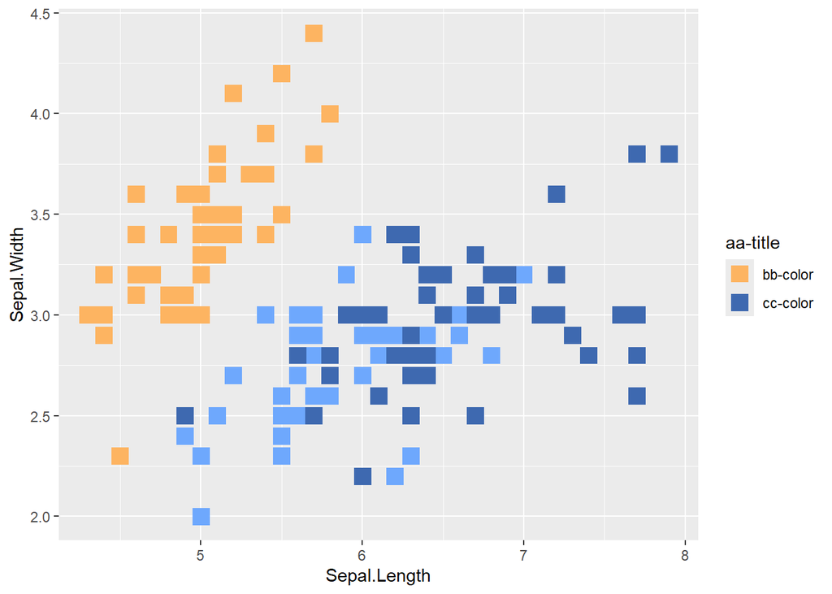

```r
# 加载包
library(ggplot2)

# 绘图
ggplot(iris, aes(Sepal.Length, Sepal.Width, color=Species, fill=Species)) +
  geom_point(shape=22,size=5)+
  scale_color_manual(name = "aa-title",
                     # values = c("#FDB461", "#6EA8FD", "#3E69B0"),    #简化写法
                     values = c("setosa"="#FDB461","versicolor"="#6EA8FD","virginica"="#3E69B0"),
                     limits = c("setosa","virginica","versicolor"),
                     breaks = c("setosa","virginica"),
                     labels = c("bb-color","cc-color"),   #简化写法
                     # labels = c("setosa"="bb-color","versicolor"="cc-color"),
                     aesthetics = c("colour", "fill"),
                     na.value = "gray",
                     drop=T)
```

## 11.4 theme

theme中，关于legend的调节有很多，常用的几个参数，含义见代码注释吧

注意：

1. 对齐方式中:
- 水平上：0左对齐、1右对齐、0.5水平居中对齐
- 竖直上：0下对齐、1上对齐、0.5垂直居中对齐
- legend.justification的向量有两个元素，第一个是水平对齐参数，第二个是竖直对齐参数
2. legend.direction为vertical时，title在legend的上方，为horizontal时，在左侧

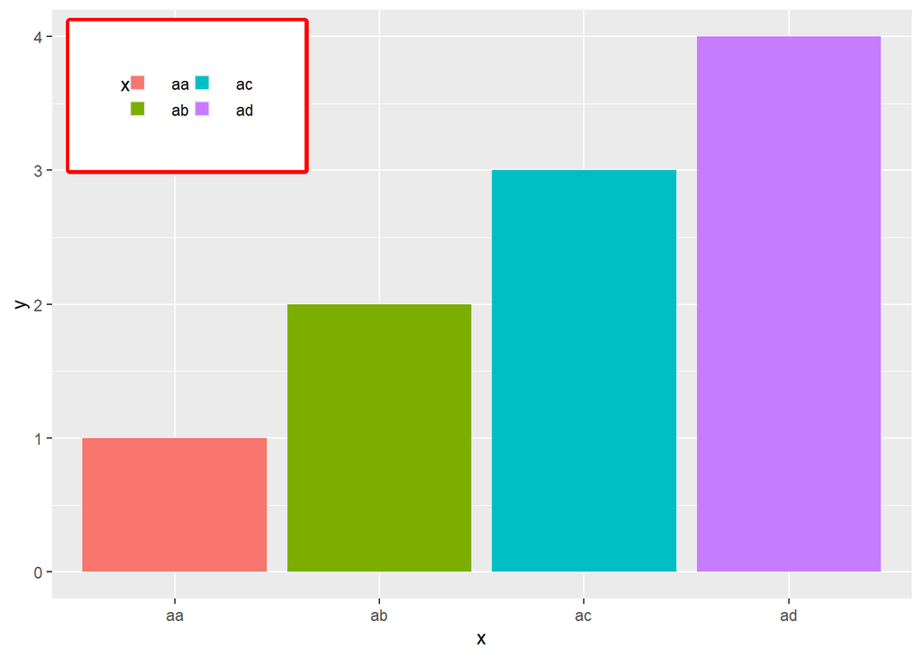

```r
# 加载包
library(ggplot2)

# 数据
dat <- data.frame(x=c("aa","ab","ac","ad"), y=c(1,2,3,4))

# 绘图
ggplot(dat, aes(x, y, fill=x))+
  geom_col()+
  guides(fill=guide_legend(nrow = 2))+
  theme(
    legend.title = element_text(margin = margin(0,0,0.5,0,"cm")),  #标题上右下左宽度
    legend.key.height = unit(0.2,"cm"),                            #key高度
    legend.key.width = unit(0.3, "cm"),                            #key宽度
    # legend.key.size = unit(2, "cm"),                            #同时调节key大小
    legend.key.spacing.y = unit(0.2, "cm"),                        #key垂直间距
    legend.key.spacing.x = unit(0.1, "cm"),                        #key水平间距（两列时有用）
    legend.text = element_text(margin = margin(0,0,0,0.5,"cm")),   #文字上右下左宽度
    legend.position = "inside",                                    #legend位于内部
    legend.position.inside = c(0.02,0.98),                         #legend对齐位置
    legend.direction = "horizontal",                               #水平方向（水平时标题在左侧）
    legend.justification = c(0,1),                                 #legend对齐方式左对齐、上对齐
    legend.box.background = element_rect(linewidth=2, color="red"),#legend的边框属性
    legend.background = element_rect(fill="white"),                #legend背景颜色
    legend.margin = margin(1, 1, 1,  1, "cm")                      #legend上右下左margin
  )
```

## 11.5 连续颜色的相关调整

连续颜色中，与离散颜色不同的几个调整参数，具体参见注释

个别用法总结：

- 如果想隐藏color_bar的ticks，只能设置`guide_colorbar(ticks.colour = NA)`，而以下方法都不行`ticks=NULL`，`ticks.linewidth = 0`，`ticks.color = NA`（注意ticks.color都不行，必须是colour）

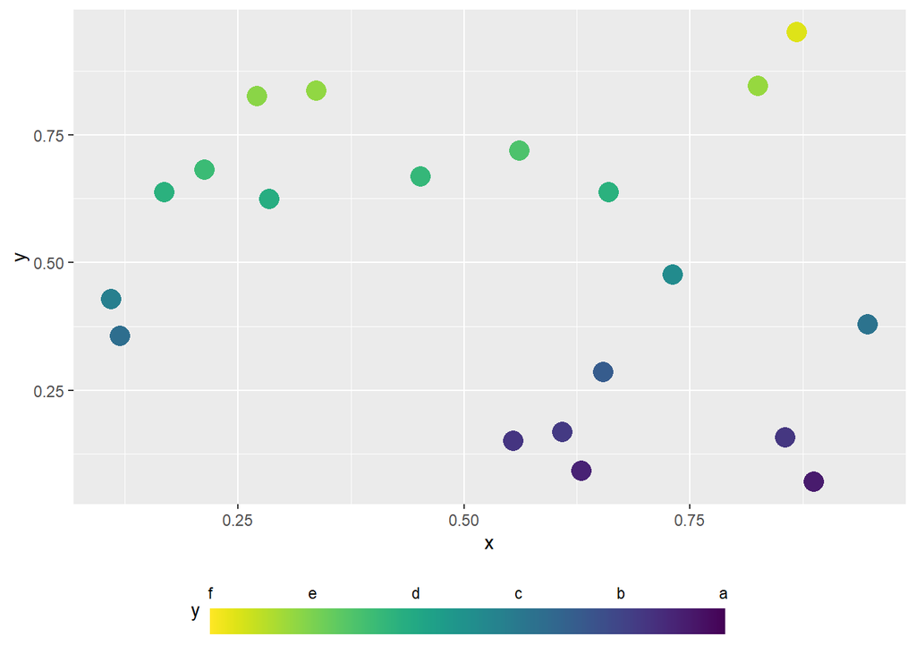

```r
# 加载包
library(ggplot2)

# 数据
dt2 <- data.frame(x=runif(20), y=runif(20))
colo <- c("#FF0000", "#00FF00", "#0000FF", "#FFFF00")

# 绘图
ggplot(dt2, aes(x,y,color=y))+
  geom_point(size=5)+
  guides(color=guide_colorbar(reverse = T))+                                            #颜色区间反向
  # scale_color_continuous(limits=c(0,1),breaks=seq(0,1,0.2),labels=letters[1:6])+      #legend范围、分级、标签
  viridis::scale_color_viridis(limits=c(0,1),breaks=seq(0,1,0.2),labels=letters[1:6])+  #一个比较好的颜色
  # scale_color_gradient(low="#00FF00", high = "#0000FF")+                              #二元颜色连续
  # scale_color_gradient2(low="#00FF00", mid = "#FF0000", high = "#0000FF")+            #三元颜色连续
  # scale_color_gradientn(colours=colo,breaks=seq(0,1,0.2),labels=letters[1:6])+        #多元颜色连续
  theme(
    legend.ticks = element_blank(),      #不要ticks
    legend.text.position = "top",        #legend文字放在上侧（竖直方向为左右）
    legend.direction = "horizontal",     #水平方向
    legend.location = "plot",            #plot或panel，legend的对齐方式
    legend.position = "bottom",          #图例放底部
    legend.key.height = unit(0.5, "cm"), #图例的高（水平legend也是上下长度）
    legend.key.width = unit(2, "cm")     #图例的宽（水平legend也是左右长度）
  )
```

## 11.6 point的color和fill样式

`geom_point`的`shape`参数，效果同基础绘图参数`pch`，使用数值型时，可以是0~25一共前26个数字可以定义，然后是一些不可定义的，从33开始又可以定义了，只不过是一些符号，这些符号使用`shape`或`pch`可以定义如`pch="!"`。

其中，21~25既有color也有fill，fill中有size(大小)和stroke(轮廓宽度)

下图展示了前0~25个点的形状

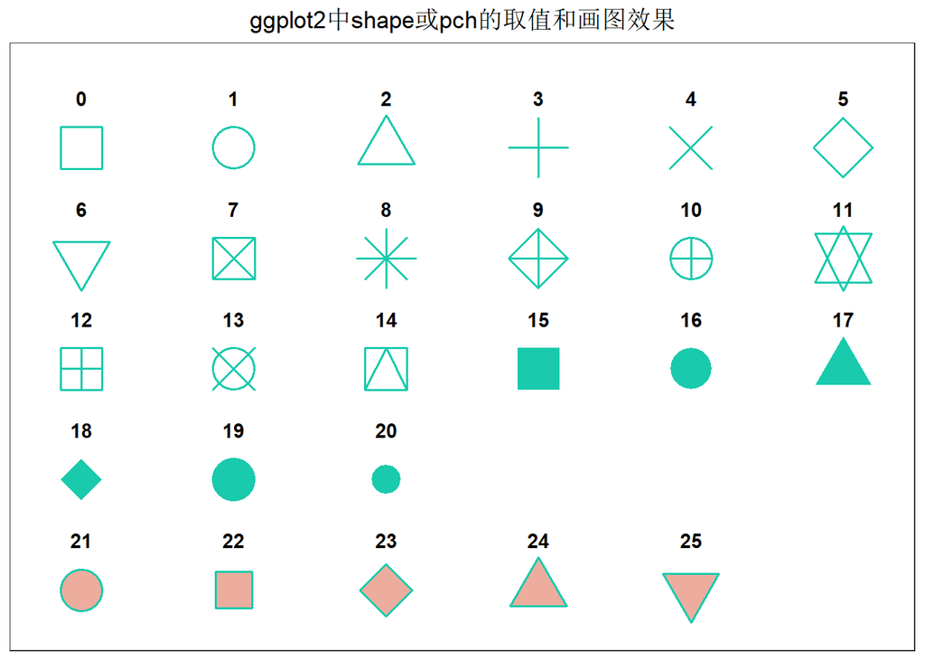

```r
# 加载包
library(ggplot2)
library(magrittr)

# 数据
point_fill_F <- data.frame(x=rep(0:5, times=6), y=rep(1:6,each=6), z=0:35) %>% .[1:21,]
point_fill_T <- data.frame(x=0:4, y=5, z=21:25)

# 绘图
ggplot()+
  geom_point(data=point_fill_F, aes(x, -y, shape=z), size = 10, fill = "#ECAD9E", colour = "#19CAAD", stroke=1) +
  geom_point(data=point_fill_T, aes(x, -y, shape=z), size = 10, fill = "#ECAD9E", colour = "#19CAAD", stroke=1) +
  scale_shape_identity()+                 #注意转换，必须用数值型才能出来，而且还必须是离散的
  geom_text(data = point_fill_F, aes(x, -y+0.45, label = z), fontface="bold")+
  geom_text(data = point_fill_T, aes(x, -y+0.45, label = z), fontface="bold")+
  scale_x_continuous(limits = c(-0.2, 5.2))+
  scale_y_continuous(limits = c(-5.3, -0.3))+
  labs(x = NULL, y = NULL, title="ggplot2中shape或pch的取值和画图效果")+
  theme_bw()+
  theme(axis.text = element_blank(),
        axis.ticks = element_blank(),
        panel.grid = element_blank(),
        plot.title = element_text(hjust = 0.5))
```

## 11.7 line的type参数

[figure not shown]

```r
# 加载包
library(ggplot2)

# 绘图
ggplot()+
  geom_line(aes(x=1:2, y=c(1,1)), linetype=0, linewidth=1)+
  geom_line(aes(x=1:2, y=c(2,2)), linetype=1, linewidth=1)+
  geom_line(aes(x=1:2, y=c(3,3)), linetype=2, linewidth=1)+
  geom_line(aes(x=1:2, y=c(4,4)), linetype=3, linewidth=1)+
  geom_line(aes(x=1:2, y=c(5,5)), ltp=4, linewidth=1)+
  geom_line(aes(x=1:2, y=c(6,6)), linetype="longdash", linewidth=1)+
  geom_line(aes(x=1:2, y=c(7,7)), ltp="twodash", linewidth=1)+
  annotate("text",x=0.95, y=1, label = "0 or blank : ", hjust=1)+
  annotate("text",x=0.95, y=2, label = "1 or solid : ", hjust=1)+
  annotate("text",x=0.95, y=3, label = "2 or dashed : ", hjust=1)+
  annotate("text",x=0.95, y=4, label = "3 or dotted : ", hjust=1)+
  annotate("text",x=0.95, y=5, label = "4 or dotdash : ", hjust=1)+
  annotate("text",x=0.95, y=6, label = "5 or longdash : ", hjust=1)+
  annotate("text",x=0.95, y=7, label = "6 or twodash : ", hjust=1)+
  scale_x_continuous(limits = c(0.75, 2), )+
  labs(x = NULL, y = NULL, title="ggplot2中linetype或ltp的取值和画图效果")+
  theme_bw()+
  theme(axis.text = element_blank(),
        axis.ticks = element_blank(),
        panel.grid = element_blank(),
        plot.title = element_text(hjust = 0.5))
```

# 12. 拼接多个图

## 12.1 gridExtra包

gridExtra支持ggplot2对象和非ggplot2对象的拼图

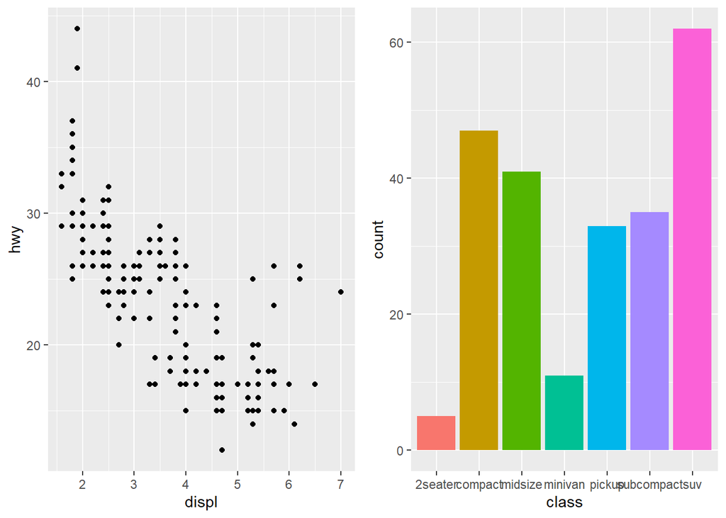

```r
# 加载包
library(ggplot2)
library(gridExtra)

# 创建两个示例图
p1 <- ggplot(mpg, aes(x = displ, y = hwy)) + geom_point()
p2 <- ggplot(mpg, aes(x = class, fill = class)) + geom_bar(show.legend = F)

# 合并
grid.arrange(p1, p2, ncol = 2)
```

## 12.2 patchwork包(★)

一般情况下，推荐使用这个包，基本用法包括（具体参见`?plot_arithmetic`）：

- 水平布局：p1+p2
- 垂直布局：p1/p2

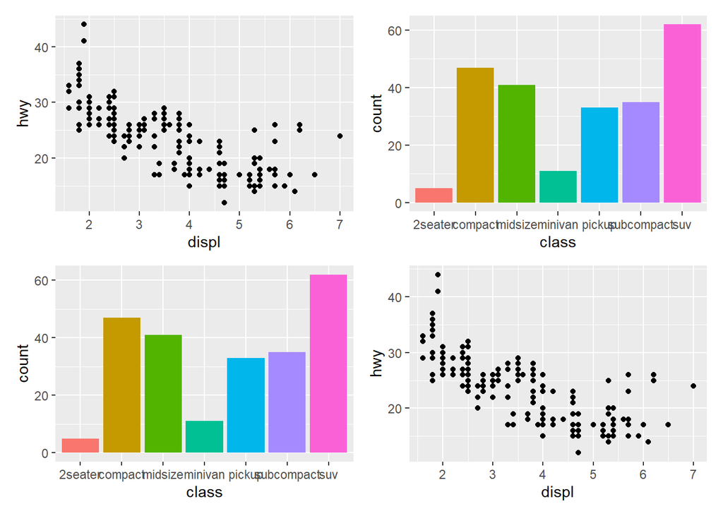

```r
# 加载包
library(ggplot2)
library(patchwork)

# 创建两个示例图
p1 <- ggplot(mpg, aes(x = displ, y = hwy)) + geom_point()
p2 <- ggplot(mpg, aes(x = class, fill = class)) + geom_bar(show.legend = F)

# 合并
(p1+p2)/(p2+p1)
```

## 12.3 cowplot包

一般情况下，推荐使用这个包

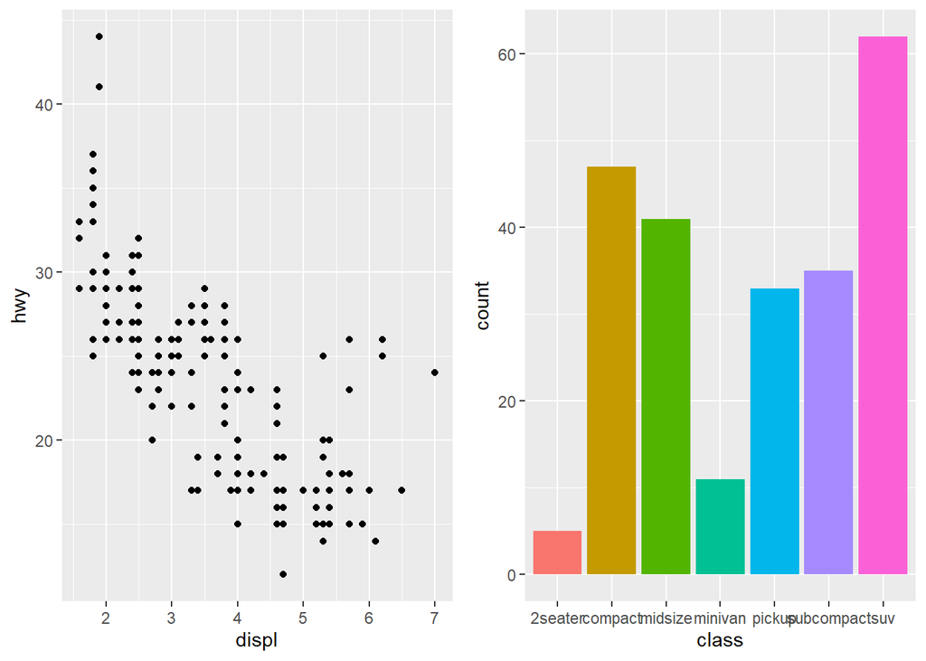

```r
# 加载包
library(ggplot2)
library(cowplot)

# 创建两个示例图
p1 <- ggplot(mpg, aes(x = displ, y = hwy)) + geom_point()
p2 <- ggplot(mpg, aes(x = class, fill = class)) + geom_bar(show.legend = F)

# 合并
plot_grid(p1, p2, ncol = 2, nrow = 1)
```

## 12.4 ggpubr包

不建议用ggpubr包拼图，因为ggarrange函数太笨，必须同时设置额ncol和nrow

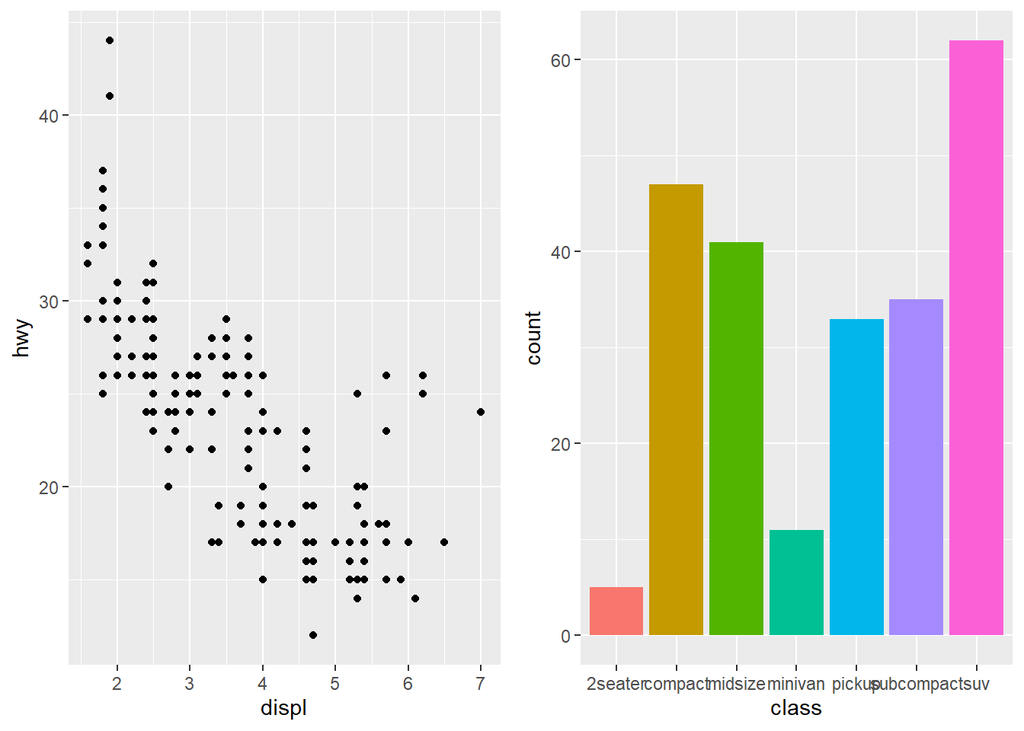

```r
# 加载包
library(ggplot2)
library(ggpubr)

# 创建两个示例图
p1 <- ggplot(mpg, aes(x = displ, y = hwy)) + geom_point()
p2 <- ggplot(mpg, aes(x = class, fill = class)) + geom_bar(show.legend = F)

# 合并
ggarrange(p1, p2, ncol = 2, nrow = 1)
```

## 12.5 grid+gridExtra+magick

此方法从文件读取图片，然后进行拼接。因为ggplot画图后plot窗口看到的和保存文件后的图像，有时差异很大（取决于保存图像的大小、长宽比是否固定、dpi等），而读取文件并拼接的方式，子图的效果是已知且不会改变的，因此拼图后不会影响子图结构。此处代码就不画图了。

```r
# # 加载包
# library(ggplot2)
# library(grid)
# library(gridExtra)
# library(magick)

# # 读取已经画好的图
# for(i in 1:4){
#   pic.name <- paste0("p", i)
#   fil.name <- sprintf("name%d.tiff", i)
#   assign(pic.name, rasterGrob(image_read(fil.name), interpolate = TRUE))
# }

# # 合并、保存
# tiff("gof_final_plot.tiff", width = 24, height = 16, units = "in", res = 300)
# grid.arrange(p1, p2, p3, p4, padding=0, nrow = 2, ncol = 2)
# dev.off()
```

# 13. CNN上的一个图

这个图出自CNN上的一篇报道：[Four years after Brexit, support for the EU surges in Britain](https://edition.cnn.com/2020/06/25/uk/uk-supports-eu-four-years-after-brexit-intl-gbr/index.html)。在原图中，UK的文字有加粗，区域有底纹，这点太复杂没有还原。

注意flip转换，都与coord_flip先后位置无关，只要转换了，就有以下特性：

- 所有图层参数，转换后xy交换了，对x的设置影响画图结果中的y
- 所有theme、just参数，转换后并不交换，对x的设置仍影响画图结果的x
- 对于坐标轴，它是把x0转换为y0，x1转换为y1等等，即x从左到右，转换后为y从下到上
- 对于堆叠顺序，原来的是level由先到后为从上到下，转换后为从右到左

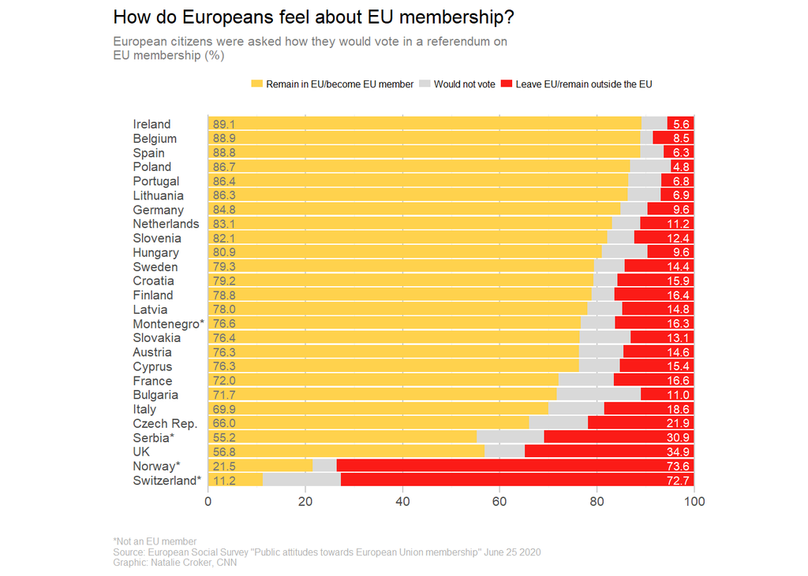

```r
# 加载包
library(data.table)
library(ggplot2)
library(magrittr)

# 数据
data <- data.table(country = c('Ireland', 'Belgium', 'Spain', 'Poland', 'Portugal',
                               'Lithuania', 'Germany', 'Netherlands', 'Slovenia', 'Hungary',
                               'Sweden', 'Croatia', 'Finland', 'Latvia', 'Montenegro*',
                               'Slovakia', 'Austria', 'Cyprus', 'France', 'Bulgaria', 'Italy',
                               'Czech Rep.', 'Serbia*', 'UK', 'Norway*', 'Switzerland*'),
                   remain = c(89.1, 88.9, 88.8, 86.7, 86.4, 86.3, 84.8, 83.1, 82.1, 80.9,
                              79.3, 79.2, 78.8, 78, 76.6, 76.4, 76.3, 76.3, 72, 71.7, 69.9,
                              66, 55.2, 56.8, 21.5, 11.2),
                   leave = c(5.6, 8.5, 6.3, 4.8, 6.8, 6.9, 9.6, 11.2, 12.4, 9.6, 14.4, 15.9,
                             16.4, 14.8, 16.3, 13.1, 14.6, 15.4, 16.6, 11, 18.6, 21.9, 30.9,
                             34.9, 73.6, 72.7))

title.text <- "How do Europeans feel about EU membership?"
sub.title.text <- "European citizens were asked how they would vote in a referendum on\nEU membership (%)"
legend.title.text <- c("Leave EU/remain outside the EU", "Would not vote", "Remain in EU/become EU member")
caption.text <- "*Not an EU member\nSource: European Social Survey \"Public attitudes towards European Union membership\" June 25 2020\nGraphic: Natalie Croker, CNN"
fill.color <- c("#FB1B17", "#D9D9D9", "#FFD24D")
var.level  <- c("leave", "notvote", "remain")

# 数据
dat <- data[, notvote:=100-remain-leave] %>%
  melt(id.vars = "country") %>%
  .[,variable:=factor(variable, levels = var.level)] %>%
  .[,country:=factor(country, levels = rev(data$country))]

# 绘图
ggplot(dat, aes(country, value, fill=variable))+
  geom_col()+
  geom_text(data=dat[variable=="remain",], aes(x=country,y=1, label=sprintf("%.1f",value)), color="#747473", hjust=0, size=2.5)+
  geom_text(data=dat[variable=="leave",],  aes(x=country,y=99,label=sprintf("%.1f",value)), color="#FFFFFF", hjust=1, size=2.5)+
  geom_hline(yintercept = 100, linewidth=0.7, color="grey80")+
  coord_flip()+
  scale_y_continuous(expand = c(0,0), breaks = seq(0, 100, by=20))+
  scale_fill_manual(values = fill.color, labels = legend.title.text)+
  guides(fill=guide_legend(title=NULL, reverse = T))+
  labs(x="", y="", title=title.text, subtitle=sub.title.text, caption=caption.text)+
  theme_bw()+
  theme(aspect.ratio = 1/1.3,
        panel.border = element_blank(),
        text = element_text(size=10),
        # axis
        axis.line.x = element_blank(),
        axis.line.x.bottom = element_blank(),
        axis.ticks.x = element_line(colour = "grey80"),
        panel.grid.major.x = element_line(color="grey80"),
        axis.ticks.y = element_blank(),
        axis.line.y = element_line(color="grey80"),
        axis.text.y = element_text(hjust=0),
        # legend
        legend.position = "top",
        legend.key.height = unit(0.2,"cm"),                                   #key高度
        legend.key.width = unit(0.3, "cm"),                                   #key宽度
        legend.key.spacing.y = unit(0.1, "cm"),                               #key垂直间距
        legend.key.spacing.x = unit(0.1, "cm"),                               #key水平间距（legend两列时有用）
        legend.text = element_text(margin = margin(0,0,0,0.05,"cm"), size=6), #文字上右下左宽度
        # title
        plot.title = element_text(hjust = 0),
        plot.title.position = "plot",                   #将标题位置设置为整个图区域的左对齐
        plot.subtitle = element_text(hjust = 0, color="grey50", size=8),
        plot.caption = element_text(hjust = 0, color="grey70", size=6),
        plot.caption.position = "plot"                  #将标题位置设置为整个图区域的左对齐
  )
```

# 14. ticks对齐border

ggplot绘图保留border时，若此时横纵坐标的第一个标度tick为最边缘（即tick为最大或最小，且expland=c(0,0)时），tick与border通常无法对齐，这让强迫症很难受。为此我探究了其中的原因与解决办法，具体来说，设置scale_y_continuous中的expand = c(0,0)后，border和坐标轴ticks不对齐的问题：

1. 原因是，y=0的tick和图的panel.border对齐方式不同（tickes对齐了border的外侧）
2. 注意，默认的ticks线宽为linewidth=0.5，颜色为深灰色（而不是黑色）
3. 注意，绘图代码、them中的element_line、theme中的element_rect，三者linewidth标度不一样，设置同样数值结果并不会等宽

非要加边框的话、非要对齐的话，有以下两种方法，推荐第一种，虽然需要调试但是简单；第二种如果顶端边缘也是也一个tick，则也需要设置expand或limits

1. 推荐解决办法1：微调expand，通常取值与绘图数据的数值有关，经查下图当border与ticks等宽，即tick为0.5、border为1时，expand为0.002时正好对齐（并不适用所有情况）
2. 解决方法2：取消border，左、下用axis.line代替，上、右用annotate代替

**注意，下图在rstudio中绘制并用ggsave保存后查看，ticks和border是对齐的，且线宽相同，在Rmd中由于缩放问题，仍然没有对齐、对等**

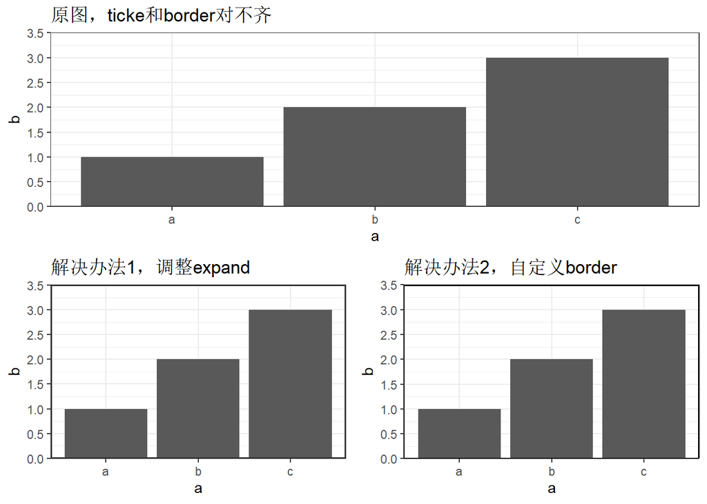

```r
# 加载包
library(ggplot2)

# 数据
dat <- data.frame(a=letters[1:3],b=1:3)

# 绘图
p1 <- ggplot(dat, aes(x=a, y=b))+
  geom_col()+
  scale_y_continuous(limits = c(0,3.5), breaks=seq(0,4,by=0.5), expand = c(0,0))+
  labs(title = "原图，ticke和border对不齐")+
  theme_bw()

p2 <- ggplot(dat, aes(x=a, y=b))+
  geom_col()+
  scale_y_continuous(limits = c(0,3.5), breaks=seq(0,4,by=0.5), expand = c(0.002,0))+
  labs(title = "解决办法1，调整expand")+
  theme_bw()+
  theme(
    axis.ticks = element_line(linewidth = 0.5),
    panel.border = element_rect(linewidth = 1)
  )

p3 <- ggplot(dat, aes(x=a, y=b))+
  geom_col()+
  annotate("segment", x = Inf, xend = Inf, y = -Inf, yend = Inf, colour = "black", linewidth = 1) +  #右边框
  annotate("segment", x = -Inf, xend = Inf, y = Inf, yend = Inf, colour = "black", linewidth = 1) +  #上边框
  scale_y_continuous(limits = c(0,3.5), breaks=seq(0,4,by=0.5), expand = c(0,0))+
  theme_bw()+
  labs(title = "解决办法2，自定义border")+
  theme(
    axis.ticks = element_line(linewidth = 0.5),
    axis.line = element_line(linewidth = 0.5),
    panel.border = element_blank()
  )

# 将第一行的图和第二行的子布局合并
library(cowplot)
plot_grid(p1, plot_grid(p2, p3, ncol = 2), ncol = 1)
```

# 15. 多重标度

参考自知乎文章：[ggplot2几种添加多重标度的方法](https://zhuanlan.zhihu.com/p/715940086)

ggplot2中，不能为相同属性（如color/fill/shape/linetype等）添加多个标度，为此可以使用第三方包实现相应功能

## 15.1 ggnewscale包

ggnewscale包简单易用，仅有4个函数：`new_scale`, `new_scale_fill`, `new_scale_color`, `new_scale_colour`

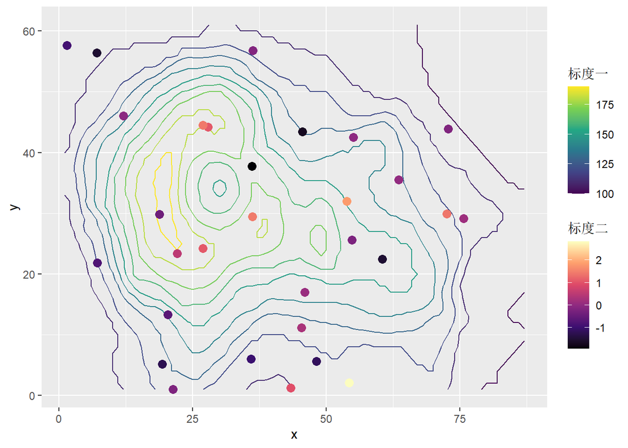

```r
# 加载包
library(ggplot2)
library(ggnewscale)

# 数据
topography <- expand.grid(x = 1:nrow(volcano), y = 1:ncol(volcano))
topography$z <- c(volcano)
measurements <- data.frame(x = runif(30, 1, 80), y = runif(30, 1, 60), thing = rnorm(30))

# 绘图
ggplot(mapping = aes(x, y)) +
  # 标度一
  geom_contour(data = topography, aes(z = z, color = stat(level))) +
  scale_color_viridis_c(name="标度一",option = "D") +
  # 在标度函数之间添加新的标度
  new_scale_color() +
  # 标度二
  geom_point(data = measurements, size = 3, aes(color = thing)) +
  scale_color_viridis_c(name="标度二",option = "A")
```

## 15.2 ggh4x包

ggh4x包功能强大，主要使用`scale_fill_multi`, `scale_colour_multi`, `scale_listed`函数, 能复用多个标度，并且给每个标度都赋予一个名称。

注意，这个包画图好像必然会有warning，即便官例也有

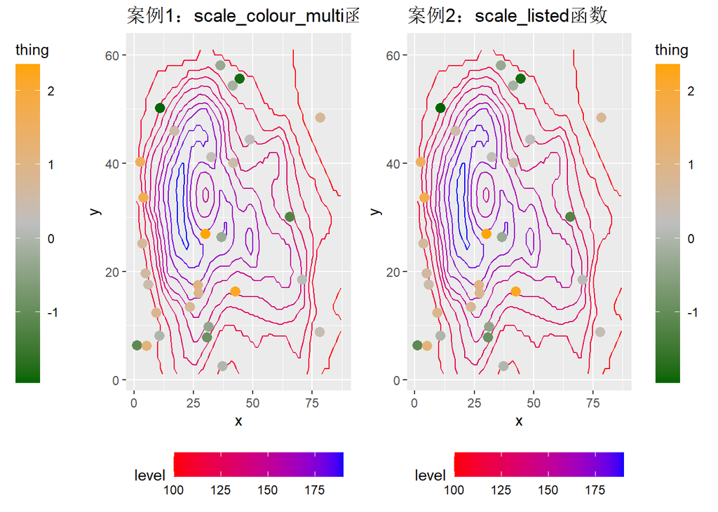

```r
# 加载包
library(ggplot2)
library(ggh4x)

# 数据
topography <- expand.grid(x = 1:nrow(volcano), y = 1:ncol(volcano))
topography$z <- c(volcano)
measurements <- data.frame(x = runif(30, 1, 80), y = runif(30, 1, 60), thing = rnorm(30))

# 案例1
p1 <- ggplot(mapping = aes(x, y)) +
  geom_contour(data = topography, aes(z = z, colour_test1 = stat(level))) +
  geom_point(data = measurements, size = 3, aes(colour_test2 = thing)) +
  scale_colour_multi(aesthetics = c("colour_test1", "colour_test2"),
                     colours = list(c("red", "blue"),
                                    c("darkgreen", "grey", "orange")),
                     guide = list(guide_colourbar(position = "bottom",
                                                  theme = theme(legend.key.width = unit(1,"null"))),
                                  guide_colourbar(position = "left",
                                                  theme = theme(legend.key.height = unit(1,"null")))))+
  labs(title = "案例1：scale_colour_multi函数")

# 案例2
p2 <- ggplot(mapping = aes(x, y)) +
  geom_contour(data = topography, aes(z = z, colour_test1 = stat(level))) +
  geom_point(data = measurements, size = 3, aes(colour_test2 = thing)) +
  scale_listed(list(
    scale_colour_gradientn(aesthetics = "colour_test1",
                           colours = c("red", "blue"),
                           guide = guide_colourbar(position = "bottom",
                                                   theme = theme(legend.key.width = unit(1,"null")))),
    scale_colour_gradientn(aesthetics = "colour_test2",
                           colours = c("darkgreen", "grey", "orange"),
                           guide = guide_colourbar(position = "right",
                                                   theme = theme(legend.key.height = unit(1,"null"))))),
    replaces = c("colour","colour"))+
  labs(title = "案例2：scale_listed函数")

cowplot::plot_grid(p1, p2, ncol = 2)
```

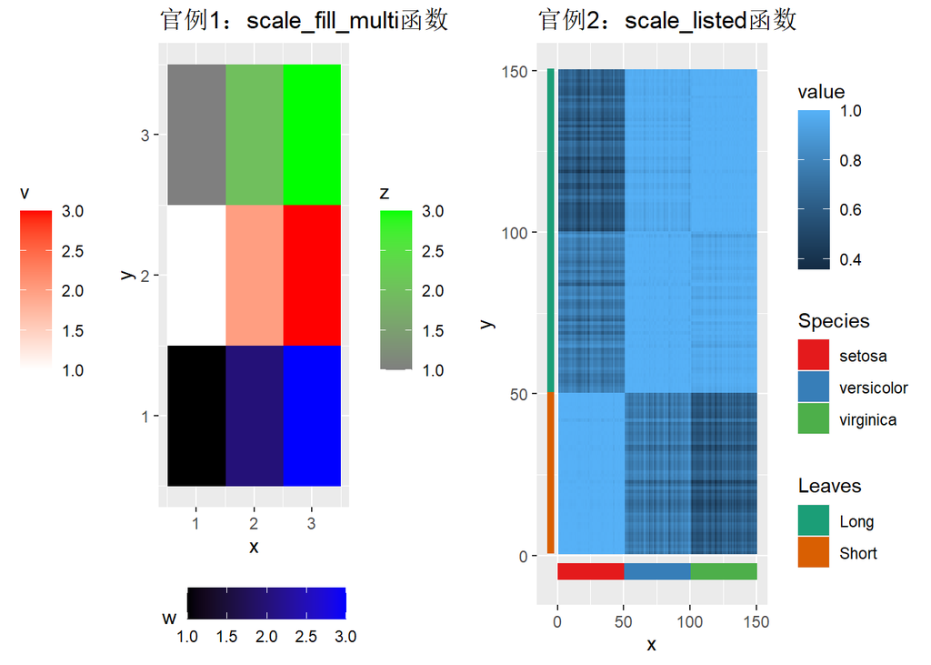

```r
# 加载包
library(ggplot2)
library(ggh4x)

# 官例1
df <- rbind(data.frame(x = 1:3, y = 1, v = NA, w = 1:3, z = NA),
            data.frame(x = 1:3, y = 2, v = 1:3, w = NA, z = NA),
            data.frame(x = 1:3, y = 3, v = NA, w = NA, z = 1:3))

p3 <- ggplot(df, aes(x, y)) +
  geom_raster(aes(fill1 = v)) +
  geom_raster(aes(fill2 = w)) +
  geom_raster(aes(fill3 = z)) +
  scale_fill_multi(aesthetics = c("fill1", "fill2", "fill3"),
                   colours = list(c("white", "red"),
                                  c("black", "blue"),
                                  c("grey50", "green")),
                   guide = list(guide_colorbar(position = "left"),
                                guide_colorbar(position = "bottom"),
                                guide_colorbar(position = "right")))+
  labs(title = "官例1：scale_fill_multi函数")

# 官例2
iriscor <- cor(t(iris[, 1:4]))
df <- data.frame(x = as.vector(row(iriscor)),
                 y = as.vector(col(iriscor)),
                 value = as.vector(iriscor))

annotation <- data.frame(z = seq_len(nrow(iris)),
                         Species = iris$Species,
                         Leaves = ifelse(iris$Species == "setosa", "Short", "Long"))

p4 <- ggplot(df, aes(x, y)) +
  geom_raster(aes(fill = value)) +
  geom_tile(data = annotation, aes(x = z, y = -5, spec = Species), height = 5) +
  geom_tile(data = annotation,aes(y = z, x = -5, leav = Leaves), width = 5) +
  scale_listed(
    list(scale_fill_brewer(palette = "Set1", aesthetics = "spec"),
         scale_fill_brewer(palette = "Dark2", aesthetics = "leav")),
    replaces = c("fill", "fill")
  )+
  labs(title = "官例2：scale_listed函数")

cowplot::plot_grid(p3, p4, ncol = 2)
```

# 16. 坐标轴截断

使用ggbreak包实现坐标轴截断

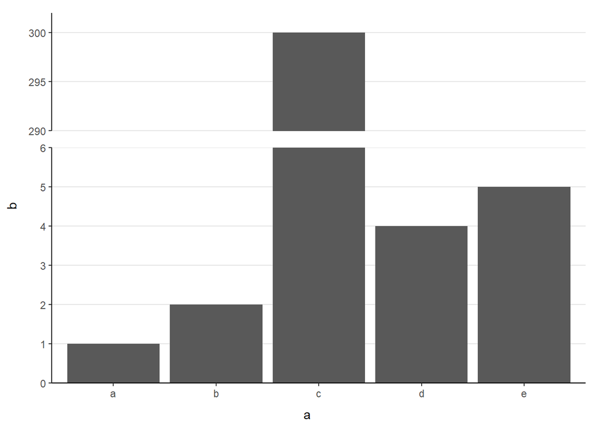

```r
# 加载包
library(ggplot2)
library(ggbreak)

# 数据
dat <- data.frame(a = letters[1:5], b=c(1,2,300,4,5))

# 绘图
ggplot(dat, aes(a, b)) +
  geom_col()+
  scale_y_continuous(limit=c(0,302), expand = c(0,0), breaks = seq(0,10,by=1))+
  scale_y_break(
    c(6, 290),                         #截断范围
    space = 0.5,                       #截断部分间距
    scales = c(0.5, 1),                #上下子图的所占比值
    ticklabels = seq(290, 300, by=5),  #上子图的y标签
    expand=c(0,0,0,0)                  #外面expand失效，这里重新定义
  )+
  theme(
    panel.background = element_rect(fill = NA),
    panel.grid.minor = element_blank(),
    panel.grid.major.x = element_blank(),
    panel.grid.major.y = element_line(color = "gray90"),
    axis.line = element_line(linewidth = 0.5),
    axis.line.y.right = element_blank(),     #会多加一个右侧轴，需要取消一下
    axis.ticks.y.right = element_blank(),
    axis.text.y.right = element_blank()
  )
```

# 17. 统计变换与after函数

某些图，可以不用整理数据，而在ggplot2中整理，例如用原始数据画带均值和置信区间的柱状图。下面这个案例，反应了ggplot2中统计变换与绘图的底层原理。

注意：

- stat_summary，由于原始数据中，并不是最终结果，需要进行总结，即求平均值和最值，这与先求总结数据再画图是一样的
- fun.data=mean_cl_normal，求原始数据的均值和95%置信区间，用于errorbar画限，类似的函数还有：
- mean_cl_normal(x, …)：均值和正态分布假设的t分布的95置信区间。
- mean_cl_boot(x, …)：均值和非参数bootstrap方法的置信区间。
- smean.sdl(x, mult=2, na.rm=TRUE)：均值和均值乘以mult加减标准差
- smean.sd(x, …)：均值和标准差
- mean_se(x, …)：均值和标准误
- median_hilow(x, …)：中位数和外部量化数（通常是25%和75%分位数）
- fun，计算出一个变量，与上面的fun.data不同，它返回的数据有多个变量
- 注意不管是fun.data还是fun，定义函数后，返回的都是aes变量，即有两者后，不必再去aes中定义相关映射

在下面这个例子中，如果label处用fun.data+mean_cl_normal，获取y、ymax、yin，并在aes中用after_stat定义y为max，则会报错，说没给y。但是由于label的标记位置只需要ymax不需要y，因此，创建了一个闭包函数，只传递出mean_cl_normal的ymax，并赋值给fun，这样直接定义x和y，从而避免上面的问题。

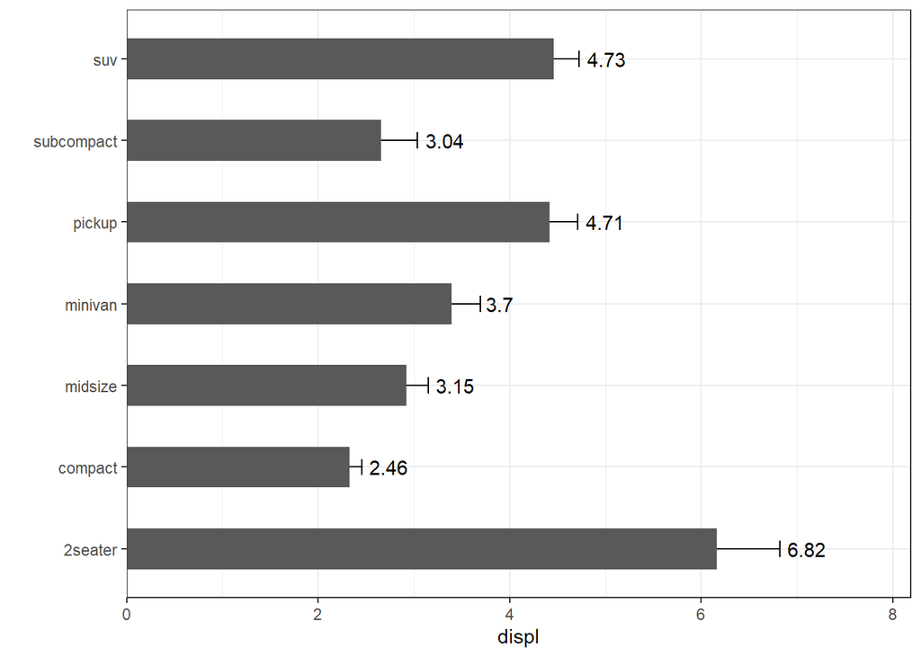

```r
# 加载包
library(ggplot2)

# 函数
yupth <- function(x){mean_cl_normal(x)$ymax}

# 绘图
ggplot(mpg, aes(class, displ))+
  stat_summary(geom="errorbar", fun.data=mean_cl_normal, width=.2) +
  stat_summary(geom="col", fun=mean, width=.5)+
  stat_summary(geom="text", fun=yupth, aes(label=round(after_stat(y),2)), hjust=-0.2)+
  scale_y_continuous(expand=c(0,0,0.2,0))+
  labs(x="")+
  coord_flip()+
  theme_bw()
```

**这里，补充一个ggplot2中，`after_scale/stat`函数的用法和含义**

| 函数 | 阶段 | 用途 |
| --- | --- | --- |
| after_stat() | 统计变换之后、映射之前 | 访问由stat计算得到的变量，比如ndensity, count, group等 |
| after_scale() | 美学映射之后、图层绘制之前 | 对aes（如fill,colour）做进一步处理，比如加透明度、变亮等 |

after_stat() 中的参数，都是统计变换之后得到的变量，它们并不是原始数据中的值，而是与图层所指定的 stat（统计变换）有关。

例如在上面例子中，`aes(fill = after_stat(x))` 表示用计算出来的统计量 x 来决定每个山脊的填充颜色。`after_stat(x)` 表示引用由 `geom_density_ridges_gradient()` 计算的统计量 x，这通常是密度估计中的 x 轴的值。它并不是原始数据中的 tem（温度）值，而是由 geom_density_ridges_gradient() 基于 tem 值计算得出的密度曲线上的位置或值。

下面一个例子，体现了`after_stat/scale`的用法

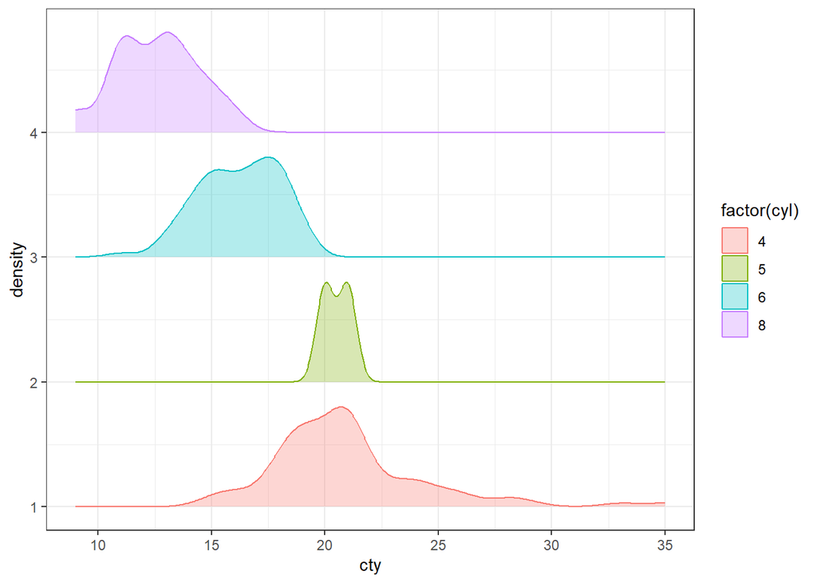

```r
# 加载包
library(ggplot2)

# 绘图
ggplot(mpg, aes(cty, colour = factor(cyl))) +
  geom_ribbon(
    stat = "density", outline.type = "upper",
    aes(
      fill = after_scale(scales::alpha(colour, 0.3)),
      ymin = after_stat(group),
      ymax = after_stat(group + ndensity*0.8)   #区间是固定的，范围小一些以留出空白
    )
  )+
  theme_bw()
```

对代码中`geom_ribbon`部分的解释（geom_ribbon是填充ymin和ymax之间的区域）：

1. `stat`，显式指定统计变化，为密度形式
2. `fill = after_scale(alpha(colour, 0.3))`，颜色传递给fill图层之前，添加一个透明度。
3. `ymin = after_stat(group)`，填充下限，是stat_density()计算时为每组数据生成的分组号（整数）。
4. `ymax = after_stat(group + ndensity)`，填充的上限，其中ndensity 是归一化密度值（0~1 之间），加上 group，就能把每组密度线“堆叠”画在一起。

after_stat/scale中可用的参数总结：

- 对于after_stat:

| 图层 (geom_) | 默认 stat | after_stat() 可用变量 | 说明 |
| --- | --- | --- | --- |
| geom_bar() / geom_col() | stat_count() | count, prop, x, y, group | count 是每组频数，prop 是比例 |
| geom_histogram() | stat_bin() | count, density, x, y | density 是归一化频数 |
| geom_density() / geom_density_ridges() | stat_density() | density, ndensity, scaled, x, y, group | ndensity 是标准化密度（0~1），scaled 可以控制高度一致化 |
| geom_boxplot() | stat_boxplot() | ymin, lower, middle, upper, ymax, outliers | 用于自定义箱线图结构 |
| geom_smooth() | stat_smooth() | y, ymin, ymax, x | 拟合线和置信区间 |
| geom_quantile() | stat_quantile() | quantile, x, y | 用于绘制分位数线 |
| geom_violin() | stat_ydensity() | y, density, scaled, count, violinwidth | 绘制小提琴图 |
| geom_ribbon(stat = “density”) | stat_density() | density, ndensity, group, x, y | 用于堆叠密度带图 |

- 对于after_scale:

| 类型 | 示例变量 | 示例用法 | 说明 |
| --- | --- | --- | --- |
| 颜色 | colour, fill | after_scale(alpha(colour, 0.5)) | 给颜色加透明度 |
| 透明度 | alpha | after_scale(alpha) | 处理后再映射透明度 |
| 大小 | size | after_scale(size^2) | 放大某些点的视觉效果 |
| 形状 | shape | after_scale(ifelse(shape == 21, 16, shape)) | 替换图形形状 |
| 线型 | linetype | after_scale(linetype) | 动态控制线型 |

# 18. just和nudge

对于just和nudge：

- nudge以图像整体为参考系，调节方向和距离都是绝对的，正数向上/右，负数向下/左
- just以文字自身为参考，文字的宽高为1个单位，调节方向和距离是相对的
- just以文字左下角为坐标系原点，即当hjust=0,vjust=0时，文字左下角与aes中指定的目标位置处对齐
- 文字与目标位置居中时，hjust=0.5且vjust=0.5，因此**hjust、vjust增加，将使文字左移、下移**
- hjust=0/0.5/1时，对应：左对齐、居中对齐、右对齐
- vjust=0/0.5/1时，对应；下对齐、居中对齐、上对齐

例图：

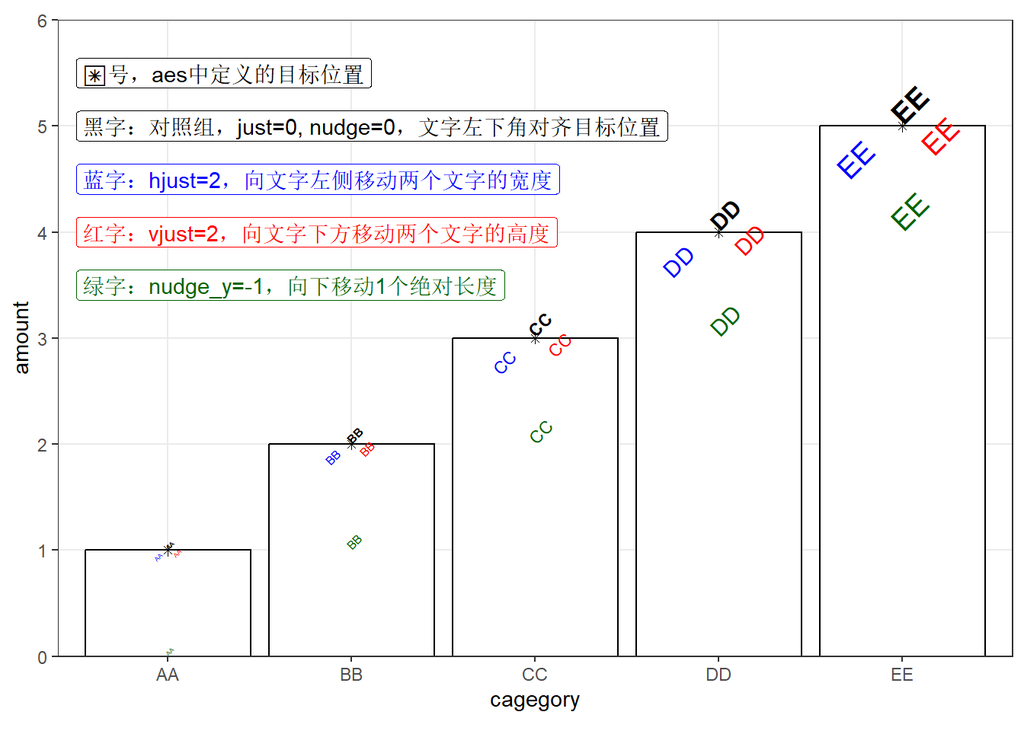

```r
# 加载包
library(ggplot2)

# 数据
pdata <- data.frame(cagegory=paste0(LETTERS[1:5], LETTERS[1:5]),amount=c(1:5),size=c(1:5))

# 绘图
ggplot(pdata,aes(x=cagegory,y=amount))+
  geom_col(fill="white",color="black")+
  geom_point(shape=8)+
  geom_text(aes(label=cagegory,size=size),hjust=0,vjust=0,nudge_y=0, angle=45,color='black',fontface="bold") +
  geom_text(aes(label=cagegory,size=size),hjust=2,vjust=0,nudge_y=0,angle=45,color='blue') +
  geom_text(aes(label=cagegory,size=size),hjust=0,vjust=2,nudge_y=0,angle=45,color='red') +
  geom_text(aes(label=cagegory,size=size),hjust=0,vjust=0,nudge_y=-1,angle=45,color='darkgreen') +
  annotate("label", x=0.5,y=5.5, label="✳号，aes中定义的目标位置",color="black",hjust=0,label.size=0)+
  annotate("label", x=0.5,y=5.0, label="黑字：对照组，just=0, nudge=0，文字左下角对齐目标位置", color="black",hjust=0,label.size=0)+
  annotate("label", x=0.5,y=4.5, label="蓝字：hjust=2，向文字左侧移动两个文字的宽度", color="blue", hjust=0,label.size=0)+
  annotate("label", x=0.5,y=4.0, label="红字：vjust=2，向文字下方移动两个文字的高度", color="red", hjust=0,label.size=0)+
  annotate("label", x=0.5,y=3.5, label="绿字：nudge_y=-1，向下移动1个绝对长度", color="darkgreen", hjust=0,label.size=0)+
  guides(size=guide_none()) +
  scale_size_identity() +
  scale_y_continuous(n.breaks = 6, limits = c(0,6), expand=c(0,0))+
  theme_bw()+
  theme(aspect.ratio = 1/1.5, panel.grid.minor = element_blank())
```

# 19. scale中的expand

对于scale中expand的用法，说明如下：

1. `expand`参数，在scale_x/y_continue等函数中，扩展x/y轴两侧的区间
2. `expand`参数，控制包括左或下、右或上的扩展，有mult和add两种扩展方式
3. `expand`参数的定义方式和含义说明如下：
- `expand=c(1,2)`，等同于`expand=expansion(mult=1,add=2)`，同时为x/y轴两端扩展相同大小
- `expand=c(1,2,3,4)`等同于`expand=expansion(mult=c(1,3),add=c(2,4))`，分别为x/y轴两端扩展
- `expand=c(1,2,3,4)`中，1和2控制左或下，3和4控制右或上
- `expand=c(1,2,3,4)`中，1和3是mult扩展，2和4是add扩展
4. `mult=c(1,3)`，含义是，以图x轴或y轴的整个区间为单位长度，分别向两侧扩展1倍和3倍
5. `add=c(2,4)`，含义是，分别向x轴或y轴两侧，扩展绝对距离2和4

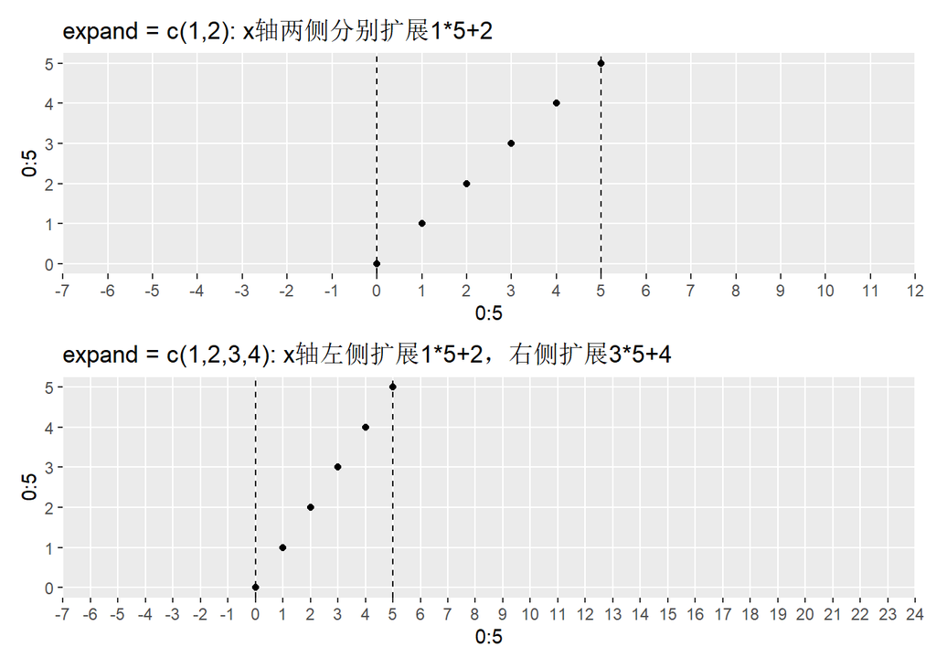

```r
# 加载包
library(ggplot2)
library(patchwork)

# 绘图
p1 <- ggplot()+
  geom_point(aes(0:5,0:5))+
  geom_vline(xintercept = c(0,5),linetype="dashed") +
  scale_x_continuous(breaks=seq(-20,30), limits = c(0,5), expand = c(1,2))+
  ggtitle("expand = c(1,2): x轴两侧分别扩展1*5+2")+
  theme(panel.grid.minor = element_blank())
p2 <- ggplot()+
  geom_point(aes(0:5,0:5))+
  geom_vline(xintercept = c(0,5),linetype="dashed") +
  scale_x_continuous(breaks=seq(-20,30), limits = c(0,5), expand = c(1,2,3,4))+
  ggtitle("expand = c(1,2,3,4): x轴左侧扩展1*5+2，右侧扩展3*5+4")+
  theme(panel.grid.minor = element_blank())

# 合并
p1/p2
```

# 20. 主题/配色/标注

## 20.1 主题

以下内容来自《现代统计图形第二版》：https://bookdown.org/xiangyun/msg2nd/visualization-basic.html

- ggthemes (Arnold 2021)，收集了网站（如Fivethirtyeight）、杂志（如《经济学家》）、软件（如 Stata）等的配色主题，打包成可供ggplot2绘图的主题：https://github.com/jrnold/ggthemes
- ggsci (Xiao 2018)，收集了多份期刊杂志的图形配色，将其融入 ggplot2 绘图主题中：https://github.com/road2stat/ggsci
- ggpubr (Kassambara 2022)，在ggplot2之上封装一套更加易用的函数，可以快速绘制出版级的统计图形：[https://github.com/kassambara/ggpubr，或https://github.com/kassambara/ggpubr](https://github.com/kassambara/ggpubr%EF%BC%8C%E6%88%96https://github.com/kassambara/ggpubr)
- ggcharts (Neitmann 2020)，类似ggpubr包，也提供一套更加快捷的函数接口，缩短数据可视化的想法与实际图形的距离：https://github.com/thomas-neitmann/ggcharts
- ggthemr (Tobin 2020)，比较早的ggplot2主题包，上游依赖少：https://github.com/Mikata-Project/ggthemr
- ggtech (Bion 2018)，收集了许多科技公司的设计风格，将其制作成可供ggplot2绘图使用的主题：https://github.com/ricardo-bion/ggtech
- bbplot (Stylianou 等 2022)，为BBC新闻定制的一套主题：https://github.com/bbc/bbplot
- pilot (Hawkins 2022)，提供一套简洁的ggplot2主题，特别是适合展示分类、离散型数据：https://github.com/olihawkins/pilot
- ggthemeassist (Gross 和 Ottolinger 2016) ，提供RStudio IDE插件，帮助用户以鼠标点击的交互方式设置ggplot2图形的主题样式：https://github.com/calligross/ggthemeassist

## 20.2 配色

**调色板**

- RColorBrewer (Neuwirth 2022) https://github.com/axismaps/colorbrewer/
- munsell (C. Wickham 2018) https://github.com/cwickham/munsell/
- colorspace (Zeileis 等 2020) https://colorspace.r-forge.r-project.org/
- paletteer (Hvitfeldt 2021) https://github.com/EmilHvitfeldt/paletteer
- scico (Pedersen 和 Crameri 2022) https://github.com/thomasp85/scico
- viridis (Garnier 等 2021) https://github.com/sjmgarnier/viridis/
- viridisLite (Garnier 等 2021) https://github.com/sjmgarnier/viridisLite/
- colormap (Karambelkar 2016) https://github.com/bhaskarvk/colormap

**ggplot2 配色函数**

下面scale函数中的color，全部可替换为colour或fill。

1. 连续型数据 (numeric, continuous)
   - scale_color_continuous() → 自动选择合适的连续色标（默认相当于 scale_color_gradient()）。
   - scale_color_gradient() –→ 连续渐变，用户指定两个端点颜色。
   - scale_color_gradient2() -→ 连续渐变，用户指定三个颜色（低–中–高，常用于正负值）。
   - scale_color_gradientn() -→ 连续渐变，可以指定多个颜色节点。
   - scale_color_steps() —–→ 连续数据离散化为分段（等宽）。
   - scale_color_steps2() —-→ 类似 steps，但突出中点。
   - scale_color_stepsn() —-→ 类似 steps，但允许多个颜色节点。
   - scale_color_viridis_c() -→ 连续色标，使用 perceptually uniform 的 viridis 方案。
2. 离散型数据 (factor, categorical)
   - scale_color_discrete() -→ 默认离散色标（等价于 scale_color_hue()）。
   - scale_color_hue() ——→ 使用 HCL 色环自动生成不同颜色。
   - scale_color_manual() —→ 用户手动指定离散变量的颜色。
   - scale_color_brewer() —→ 使用 ColorBrewer 预定义的调色板。
   - scale_color_viridis_d() → 离散型 viridis 调色板。
3. 有序型数据 (ordinal, ordered factor)
   - scale_color_ordinal() –→ 专门处理有序因子，通常类似 discrete 但颜色体现顺序。
   - scale_color_binned() —→ 连续数据先分箱，再映射到离散调色板。
   - scale_color_distiller() → 连续数据分段 + Brewer 调色板。
   - scale_color_fermenter() → 连续数据分段 + Brewer 调色板（新版改进，更灵活）。
   - scale_color_viridis_b() → 连续数据分箱 + viridis 调色板。
4. 特殊用途
   - scale_color_identity() → 直接使用数据本身作为颜色，不做映射（比如数据里就有颜色值 “#FF0000”）。
   - scale_color_grey() —-→ 专门的灰度色标。
5. 时间型
   - scale_color_date() —-→ 连续日期数据（针对Date类型的scale_color_gradient的特殊形式）。
   - scale_color_datetime() → 连续时间数据（针对DPOSIXct/POSIXlt类型的scale_color_gradient的特殊形式）。

## 20.3 注释

- ggrepel (Slowikowski 2021)，可以通过添加一定距离的扰动，可以缓解文本重叠的问题：https://github.com/slowkow/ggrepel
- ggtext (Wilke 2020)，支持以Markdown语法添加丰富的文本内容：https://github.com/wilkelab/ggtext
- string2path (Yutani 2022)，字体轮廓生成路径，注释文本随路径变化：https://github.com/yutannihilation/string2path
- ggimage (Yu 2022)，提供图像图层，实现以图片代替散点的效果，图片还可以是表情包：https://github.com/GuangchuangYu/ggimage